# Insurance Claim Case Study

|  | **Insurance Claim Prediction** |
| --- | --- |

## Problem Statement

A key challenge for the insurance industry is to charge each customer an appropriate premium for the risk they represent. The ability to predict a correct claim amount has a significant impact on insurer's management decisions and financial statements. Predicting the cost of claims in an insurance company is a real-life problem that needs to be solved in a more accurate and automated way. Several factors determine the cost of claims based on health factors like BMI, age, smoker, health conditions and others. Insurance companies apply numerous techniques for analyzing and predicting health insurance costs

## Data Definition

**age** : Age of the policyholder (Numeric)

**sex:** Gender of policyholder (Categoric)

**weight:** Weight of the policyholder (Numeric)

**bmi**: Body mass index, providing an understanding of body, weights that are relatively high or low relative to height, objective index of body weight (kg / m ^ 2) using the ratio of height to weight (Numeric)

**no_of_dependents:** Number of dependent persons on the policyholder (Numeric)

**smoker:** Indicates policyholder is a smoker or a non-smoker (non-smoker=0;smoker=1) (Categoric)

**claim:** The amount claimed by the policyholder (Numeric)

**bloodpressure:** Bloodpressure reading of policyholder (Numeric)

**diabetes:** Indicates policyholder suffers from diabetes or not (non-diabetic=0; diabetic=1) (Categoric)

**regular_ex:** A policyholder regularly excercises or not (no-excercise=0; excercise=1) (Categoric)

**job_title:** Job profile of the policyholder (Categoric)

**city:** The city in which the policyholder resides (Categoric)

**hereditary_diseases:** A policyholder suffering from a hereditary diseases or not (Categoric)

## Icon Legends

| **Inferences from Outcome** | **Additional Reads** | **Lets do it** | **Quick Tips** |
| --- | --- | --- | --- |

1. **Import Libraries**
2. **Set Options**
3. **Read Data**
4. **Data Analysis and Preparation**
   - 4.1 - Understand the Data
     - 4.1.1 - Data Dimension
     - 4.1.2 - Data Types
     - 4.1.3 - Summary Statistics
     - 4.1.4 - Missing Values
     - 4.1.5 - Correlation
     - 4.1.6 - Analyze Categorical Variables
     - 4.1.7 - Analyze Relationships Between Target and Categorical Variables
     - 4.1.8 - Feature Engineering
     - 4.1.9 - Discover Outliers
     - 4.1.10- Recheck the Correlation
   - 4.2 - Prepare the Data
     - 4.2.1 - Check for Normality
     - 4.2.2 - One-Way Anova
     - 4.2.3 - Dummy Encoding of Categorical Variables
5. **Linear Regression (OLS)**
   - 5.1 - Multiple Linear Regression - Full Model - with Log Transformed Dependent Variable (OLS)
   - 5.2 - Multiple Linear Regression - Full Model - without Log Transformed Dependent Variable (OLS)
   - 5.3 - Fine Tune Linear Regression Model (OLS)
     - 5.3.1 - Linear Regression after Removing Insignificant Variable (OLS)
     - 5.3.2 - Check the Assumptions of Linear Regression
       - 5.3.2.1 - Detecting Autocorrelation
       - 5.3.2.2 - Detecting Heteroskedasticity
       - 5.3.2.3 - Linearity of Residuals
       - 5.3.2.4 - Normality of Residuals
     - 5.3.3 - Linear Regression after Removing Insignificant Variable (OLS) - Scaled Data
     - 5.3.4 - Linear Regression with Interaction (OLS)
6. **Regularization (OLS)**
   - 6.1 - Ridge Regression Model (OLS)
   - 6.2 - Lasso Regression Model (OLS)
   - 6.3 - Elastic Net Regression Model (OLS)
7. **Stochastic Gradient Descent - SGD (sklearn)**
   - 7.1 - Linear Regression with SGD (sklearn)
   - 7.2 - Linear Regression with SGD using GridSearchCV (sklearn)
8. **Conclusion and Interpretation**

## 1. Import Libraries

**Let us import the required libraries and functions**

```python
# supress warnings
from warnings import filterwarnings
filterwarnings('ignore')

# 'Os' module provides functions for interacting with the operating system
import os

# 'Pandas' is used for data manipulation and analysis
import pandas as pd

# 'Numpy' is used for mathematical operations on large, multi-dimensional arrays and matrices
import numpy as np

# 'Matplotlib' is a data visualization library for 2D and 3D plots, built on numpy
import matplotlib.pyplot as plt
%matplotlib inline

# 'Seaborn' is based on matplotlib; used for plotting statistical graphics
import seaborn as sns

# 'Scikit-learn' (sklearn) emphasizes various regression, classification and clustering algorithms
from sklearn.model_selection import train_test_split
from sklearn.metrics import mean_squared_error, mean_absolute_error, r2_score
from sklearn.model_selection import GridSearchCV
from sklearn.linear_model import ElasticNet

# 'Statsmodels' is used to build and analyze various statistical models
import statsmodels
import statsmodels.api as sm
import statsmodels.stats.api as sms
from statsmodels.tools.eval_measures import rmse
from statsmodels.compat import lzip
from statsmodels.graphics.gofplots import ProbPlot

# 'SciPy' is used to perform scientific computations
from scipy.stats import f_oneway
from scipy.stats import jarque_bera
from scipy import stats
```

## 2. Set Options

```python
# the path for reading the data file
# Note: Set your path accordingly
#os.chdir('/Users/Dippies/GL DSE Deliveries/Regression/Nov 22')

# display all columns of the dataframe
pd.options.display.max_columns = None

# display all rows of the dataframe
pd.options.display.max_rows = None

# return an output value upto 6 decimals
pd.options.display.float_format = '{:.6f}'.format
```

## 3. Read Data

|  | **Read and display data to get insights from the data** |
| --- | --- |

```python
# read csv file using pandas
df_insurance = pd.read_csv("healthinsurance.csv")

# display the top 5 rows of the dataframe
df_insurance.head()

# Note: In order to display more rows, example 10, use head(10)
```

|  | age | sex | weight | bmi | hereditary_diseases | no_of_dependents | smoker | city | bloodpressure | diabetes | regular_ex | job_title | claim |
| --- | --- | --- | --- | --- | --- | --- | --- | --- | --- | --- | --- | --- | --- |
| 0 | 60.000000 | male | 64 | 24.300000 | NoDisease | 1 | 0 | NewYork | 72 | 0 | 0 | Actor | 13112.600000 |
| 1 | 49.000000 | female | 75 | 22.600000 | NoDisease | 1 | 0 | Boston | 78 | 1 | 1 | Engineer | 9567.000000 |
| 2 | 32.000000 | female | 64 | 17.800000 | Epilepsy | 2 | 1 | Phildelphia | 88 | 1 | 1 | Academician | 32734.200000 |
| 3 | 61.000000 | female | 53 | 36.400000 | NoDisease | 1 | 1 | Pittsburg | 72 | 1 | 0 | Chef | 48517.600000 |
| 4 | 19.000000 | female | 50 | 20.600000 | NoDisease | 0 | 0 | Buffalo | 82 | 1 | 0 | HomeMakers | 1731.700000 |

## 4. Data Analysis and Preparation

[figure not shown]

Data preparation is the process of cleaning and transforming raw data prior to building predictive models.  
Here we will analyze and prepare data to perform regression analysis:  
1. Check dimensions of the dataframe in terms of rows and columns  
2. Check the data types. Refer data definition to ensure your data types are correct  
3. If data types are not as per business context, change the data types as per requirement  
4. Study summary statistics  
5. Check for missing values  
6. Study correlation  
7. Analyze categorical variables  
8. Analyze relationship between target variable and categorical variables  
9. Perform feature engineering  
10. Detect outliers  
11. Recheck the correlation  
Note: It is an art to explore data and one will need more and more practice to gain expertise in this area.

### 4.1 Understand the Dataset

### 4.1.1 Data Dimension

To know the dimensions of the data:

```python
# .shape returns the dimension of the data
df_insurance.shape
```

```
(15000, 13)
```

We see the dataframe has 13 columns and 15000 observations.

### 4.1.2 Data Types

Data has a variety of data types. The main types stored in pandas dataframes are object, float, int64, bool and datetime64. In order to learn about each attribute, it is always good for us to know the data type of each column.

|  | In this section we will: 1. Check data types 2. Change the incorrect data types 3. Recheck the data types after the conversion |
| --- | --- |

**1. Check data types**

```python
# use .dtypes to view the data type of a variable
df_insurance.dtypes
```

```
age                    float64
sex                     object
weight                   int64
bmi                    float64
hereditary_diseases     object
no_of_dependents         int64
smoker                   int64
city                    object
bloodpressure            int64
diabetes                 int64
regular_ex               int64
job_title               object
claim                  float64
dtype: object
```

[figure not shown]

From the above output, we see that the data type of 'smoker', 'diabetes' and 'regular_ex' is 'int64'.  
But according to data definition, 'smoker', 'diabetes' and 'regular_ex' are categorical variables, which are wrongly interpreted as 'int64', so we will convert these variables data type to 'object'.

**2. Change the incorrect data types**

```python
# use .astype() to change the data type
# convert numerical variables to categorical

# convert numeric variable 'smoker' to object (categorical) variable
df_insurance.smoker = df_insurance.smoker.astype('object')

# convert numeric variable 'diabetes' to object (categorical) variable
df_insurance.diabetes = df_insurance.diabetes.astype('object')

# convert 'regular_ex' variable diabetes to object (categorical) variable
df_insurance.regular_ex = df_insurance.regular_ex.astype('object')
```

**3. Recheck the data types after the conversion**

```python
# recheck the data types using .dtypes
df_insurance.dtypes
```

```
age                    float64
sex                     object
weight                   int64
bmi                    float64
hereditary_diseases     object
no_of_dependents         int64
smoker                  object
city                    object
bloodpressure            int64
diabetes                object
regular_ex              object
job_title               object
claim                  float64
dtype: object
```

Note the data types are now as per the data definition. Now we can proceed with the analysis.

### 4.1.3 Summary Statistics

[figure not shown]

In our dataset we have numerical and categorical variables. Now we check for summary statistics of all the variables  
1. For numerical variables, we use .describe()  
2. For categorical features, we use .describe(include=object)

**1. For numerical variables, we use .describe()**

```python
# describe the numerical data
df_insurance.describe()
```

|  | age | weight | bmi | no_of_dependents | bloodpressure | claim |
| --- | --- | --- | --- | --- | --- | --- |
| count | 14604.000000 | 15000.000000 | 14044.000000 | 15000.000000 | 15000.000000 | 15000.000000 |
| mean | 39.547521 | 64.909600 | 30.266413 | 1.129733 | 68.650133 | 13401.437620 |
| std | 14.015966 | 13.701935 | 6.122950 | 1.228469 | 19.418515 | 12148.239619 |
| min | 18.000000 | 34.000000 | 16.000000 | 0.000000 | 0.000000 | 1121.900000 |
| 25% | 27.000000 | 54.000000 | 25.700000 | 0.000000 | 64.000000 | 4846.900000 |
| 50% | 40.000000 | 63.000000 | 29.400000 | 1.000000 | 71.000000 | 9545.650000 |
| 75% | 52.000000 | 76.000000 | 34.400000 | 2.000000 | 80.000000 | 16519.125000 |
| max | 64.000000 | 95.000000 | 53.100000 | 5.000000 | 122.000000 | 63770.400000 |

[figure not shown]

The above output illustrates the summary statistics of all the numeric variables like the mean, median(50%), minimum, and maximum values, along with the standard deviation.  
Note, the average age of a policyholder claiming the insurance is 39 years. The claim amount is between 1121 to 63770. Here the mean bmi of a policyholder is 30 (the healthy bmi range is between 18.5 to 24.9) and average weight is 64.  
If we observe the count of all the variables, there is less count for variable age and bmi than other variables. So we can say that there are missing values in these variables. Also, the minimum bloodpressure is zero, which is invalid. We need to treat them appropriately.

**2. For categorical features, we use .describe(include=object)**

```python
# describe the categorical data
# include=object: selects the categorical features
df_insurance.describe(include = object)

# Note: If we pass 'include=object' to the .describe(),
#       it will return descriptive statistics for categorical variables only
```

|  | sex | hereditary_diseases | smoker | city | diabetes | regular_ex | job_title |
| --- | --- | --- | --- | --- | --- | --- | --- |
| count | 15000 | 15000 | 15000 | 15000 | 15000 | 15000 | 15000 |
| unique | 2 | 10 | 2 | 91 | 2 | 2 | 35 |
| top | female | NoDisease | 0 | NewOrleans | 1 | 0 | Student |
| freq | 7652 | 13998 | 12028 | 302 | 11655 | 11638 | 1320 |

[figure not shown]

The summary statistics for categorical variables can be interpreted as:  
count - Total number of observations  
unique - Number of unique classes in a variable  
top - The most repeated class  
freq - Frequency of most repeated class  
For variable city, it is apparent that data has been taken from 91 different cities. Also, most of the policyholder are from NewOrleans.  
In addition, there are more number of non smokers in the dataset and most of the policyholder are diabetic

### 4.1.4 Missing Values

|  | **In order to get the count of missing values in each column, we use the in-built function .isnull().sum()** |
| --- | --- |

```python
# obtain the total missing values for each variable
# 'isnull().sum()' returns the number of missing values in each variable
# sort the variables on the basis of total null values in the variable using sort_values()
# 'ascending = False' sorts values in the descending order
# the variable with highest number of missing values will appear first
Total = df_insurance.isnull().sum().sort_values(ascending=False)

# 'isnull().sum()' returns the number of missing values in each variable
# 'isnull().count()' returns the count of the data, i.e. count of outcomes 'True' and 'False' of isnull()
# sort the variables on the basis of total null values in the variable using sort_values()
# 'ascending = False' sorts values in the descending order
# the variable with highest percentage of missing values will appear first
Percent = (df_insurance.isnull().sum()*100/df_insurance.isnull().count()).sort_values(ascending=False)

# concat the 'Total' and 'Percent' columns using 'concat' function
# keys:pass a list of column names in parameter
# axis = 1: concats along the columns
missing_data = pd.concat([Total, Percent], axis = 1, keys = ['Total', 'Percentage of Missing Values'])

# print the missing data
missing_data
```

|  | Total | Percentage of Missing Values |
| --- | --- | --- |
| bmi | 956 | 6.373333 |
| age | 396 | 2.640000 |
| sex | 0 | 0.000000 |
| weight | 0 | 0.000000 |
| hereditary_diseases | 0 | 0.000000 |
| no_of_dependents | 0 | 0.000000 |
| smoker | 0 | 0.000000 |
| city | 0 | 0.000000 |
| bloodpressure | 0 | 0.000000 |
| diabetes | 0 | 0.000000 |
| regular_ex | 0 | 0.000000 |
| job_title | 0 | 0.000000 |
| claim | 0 | 0.000000 |

The missing values are present in the data for the `age` and `bmi` variables. There are 396 (2.6%) missing values for the variable `age` and 956 (6.4%) missing values for the variable `bmi`

### Visualize Missing Values using Heatmap

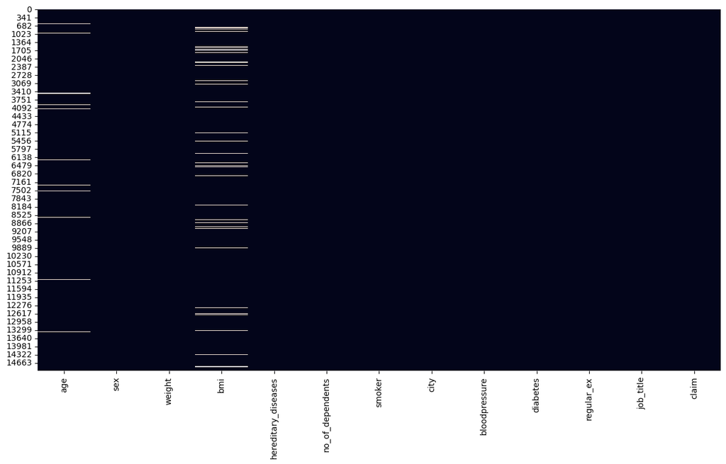

```python
# set the figure size
plt.figure(figsize=(15, 8))

# plot heatmap to check null values
# isnull(): returns 'True' for a missing value
# cbar: specifies whether to draw a colorbar; draws the colorbar for 'True'
sns.heatmap(df_insurance.isnull(), cbar=False)

# display the plot
plt.show()
```

### Deal with Missing Values

How to deal with missing data?

Depending on scenarios, you may:  
a. Drop the whole row  
b. Drop the whole column

OR replace:  
a. The missing values with mean  
b. The missing values with median  
c. Replace it based on other functions

The entire column is dropped only if most entries (80%-90%) in the column are missing. We have the option to either drop the rows containing the missing values or replace them. In our dataset, there are not many values that are missing. So, we opt to replace these values. For the variable 'age', we will replace missing values by the mean of age across the gender.

```python
# check the average age for male and female
# group the age by sex using 'groupby'
# 'axis = 0' splits along rows
# mean(): returns the mean age for each sex
df_insurance['age'].groupby(df_insurance['sex'], axis=0).mean()
```

```
sex
female   39.361040
male     39.738395
Name: age, dtype: float64
```

The average age for the male and female is nearly the same. We will fill in missing values with the mean age of the policyholder.

```python
# fill the missing values with the mean value of 'age' using 'fillna()'
# mean(): returns the mean age
# inplace: makes permanent changes in the dataframe
df_insurance['age'].fillna(df_insurance['age'].mean(), inplace=True)
```

Replace missing values by mean for the BMI.

```python
# fill the missing values with the mean value of 'bmi' using 'fillna()'
# mean(): returns the mean bmi
# inplace: makes permanent changes in the dataframe
df_insurance['bmi'].fillna(df_insurance['bmi'].mean(), inplace=True)
```

We have seen that the the minimum bloodpressure is 0, which is absurd. It implies that these are missing values. Let us replace these missing values with the median value.

```python
# calculate the median of the bloodpressure using 'median()''
median_bloodpressure = df_insurance['bloodpressure'].median()

# replace zero values by median using 'replace()'
df_insurance['bloodpressure'] = df_insurance['bloodpressure'].replace(0,median_bloodpressure)
```

Recheck the summary statistics to confirm the missing value treatment for the variable 'bloodpressure'.

```python
# obtain the summary statistics of numeric variables using 'describe()'
df_insurance.describe()
```

|  | age | weight | bmi | no_of_dependents | bloodpressure | claim |
| --- | --- | --- | --- | --- | --- | --- |
| count | 15000.000000 | 15000.000000 | 15000.000000 | 15000.000000 | 15000.000000 | 15000.000000 |
| mean | 39.547521 | 64.909600 | 30.266413 | 1.129733 | 72.228533 | 13401.437620 |
| std | 13.829705 | 13.701935 | 5.924606 | 1.228469 | 11.269793 | 12148.239619 |
| min | 18.000000 | 34.000000 | 16.000000 | 0.000000 | 40.000000 | 1121.900000 |
| 25% | 27.000000 | 54.000000 | 25.900000 | 0.000000 | 64.000000 | 4846.900000 |
| 50% | 40.000000 | 63.000000 | 29.800000 | 1.000000 | 71.000000 | 9545.650000 |
| 75% | 51.000000 | 76.000000 | 34.100000 | 2.000000 | 80.000000 | 16519.125000 |
| max | 64.000000 | 95.000000 | 53.100000 | 5.000000 | 122.000000 | 63770.400000 |

Let's view the missing value plot once again to see if the missing values have been imputed.

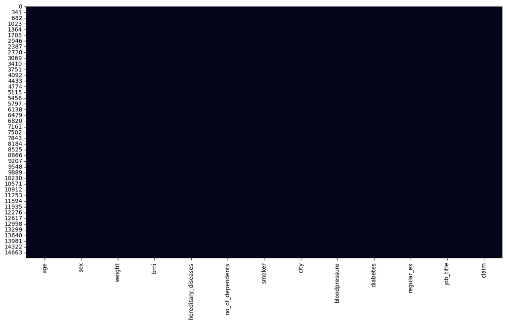

```python
# set the figure size
plt.figure(figsize=(15, 8))

# plot heatmap to check null values
# isnull(): returns 'True' for a missing value
# cbar: specifies whether to draw a colorbar; draws the colorbar for 'True'
sns.heatmap(df_insurance.isnull(), cbar=False)

# display the plot
plt.show()
```

Now, we obtain the dataset with no missing values.

### 4.1.5 Correlation

- Correlation is the extent of linear relationship among numeric variables
- It indicates the extent to which two variables increase or decrease in parallel
- The value of a correlation coefficient ranges between -1 and 1
- Correlation among multiple variables can be represented in the form of a matrix. This allows us to see which pairs are correlated

[figure not shown]

In order to compute the correlation matrix, we perform the following:  
1. Filter out only the numeric variables from the dataframe using select_dtypes() function  
2. Call the corr() function which will return the correlation matrix of numeric variables  
3. Pass the correlation matrix to the heatmap() function of the seaborn library to plot the heatmap of the correlation matrix

**1. Filter out only the numeric variables from the dataframe using select_dtypes() function**

```python
# select the numerical features in the dataset using 'select_dtypes()'
# select_dtypes(include=np.number): considers the numeric variables
df_numeric_features = df_insurance.select_dtypes(include=np.number)

# print the names of the numeric variables
df_numeric_features.columns
```

```
Index(['age', 'weight', 'bmi', 'no_of_dependents', 'bloodpressure', 'claim'], dtype='object')
```

The dataframe df_numeric_features has 6 numeric variables.

**2. Call the corr() function which will return the correlation matrix of numeric variables**

```python
# generate the correlation matrix
corr =  df_numeric_features.corr()

# print the correlation matrix
corr
```

|  | age | weight | bmi | no_of_dependents | bloodpressure | claim |
| --- | --- | --- | --- | --- | --- | --- |
| age | 1.000000 | 0.281228 | 0.180123 | 0.058926 | 0.019223 | 0.298359 |
| weight | 0.281228 | 1.000000 | 0.243269 | 0.135687 | 0.018094 | 0.077716 |
| bmi | 0.180123 | 0.243269 | 1.000000 | 0.049704 | -0.047979 | 0.197939 |
| no_of_dependents | 0.058926 | 0.135687 | 0.049704 | 1.000000 | 0.036976 | 0.067614 |
| bloodpressure | 0.019223 | 0.018094 | -0.047979 | 0.036976 | 1.000000 | 0.037676 |
| claim | 0.298359 | 0.077716 | 0.197939 | 0.067614 | 0.037676 | 1.000000 |

**3. Pass the correlation matrix to the heatmap() function of the seaborn library to plot the heatmap of the correlation matrix**

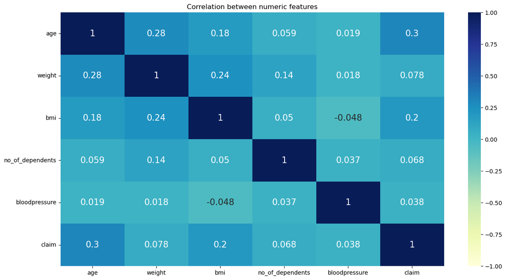

```python
# set the figure size
plt.figure(figsize=(15, 8))

# plot the heat map
# corr: give the correlation matrix
# cmap: colour code used for plotting
# vmax: gives maximum range of values for the chart
# vmin: gives minimum range of values for the chart
# annot: prints the correlation values in the chart
# annot_kws: Sets the font size of the annotation
sns.heatmap(corr, cmap='YlGnBu', vmax=1.0, vmin=-1.0, annot = True, annot_kws={"size": 15}, )

# specify name of the plot using plt.title()
plt.title('Correlation between numeric features')

# display the plot
plt.show()
```

[figure not shown]

It can be observe that the numeric variables are not correlated with each other since all the correlation coefficients are close to zero. It implies that there is no multicollinearity in the data.  
Recollect that one of the assumptions of linear regression is that, there should be NO Multicollinearity present in the data.

|  | **Correlation does not imply causation. In other words, if two variables are correlated it does not mean that one variable caused the other** |
| --- | --- |

### 4.1.6 Analyze Categorical Variables

Categorical variables are those in which the values are labeled categories. The values, distribution, and dispersion of categorical variables are best understood with bar plots.

First let us print the summary statistics of the categorical features.

```python
# display the summary statistics of categorical variables
# include=objec: selects the categoric features
df_insurance.describe(include=object)
```

|  | sex | hereditary_diseases | smoker | city | diabetes | regular_ex | job_title |
| --- | --- | --- | --- | --- | --- | --- | --- |
| count | 15000 | 15000 | 15000 | 15000 | 15000 | 15000 | 15000 |
| unique | 2 | 10 | 2 | 91 | 2 | 2 | 35 |
| top | female | NoDisease | 0 | NewOrleans | 1 | 0 | Student |
| freq | 7652 | 13998 | 12028 | 302 | 11655 | 11638 | 1320 |

Let us visualize the variables. However, we shall exculde the variable `city` from it.

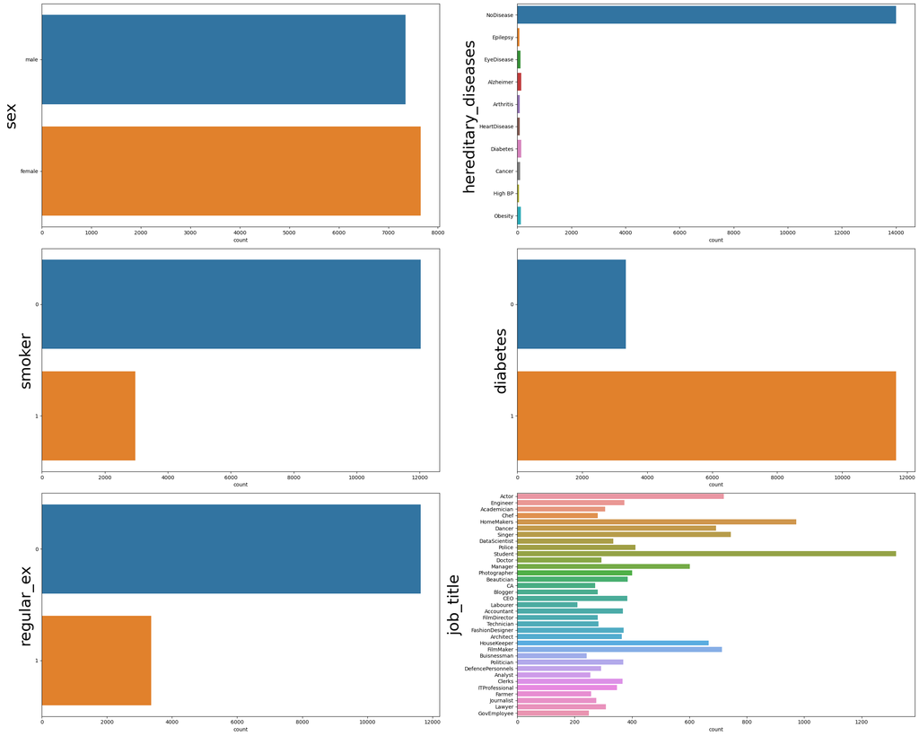

```python
# create a list of all categorical variables
# include=object: selects the categoric features
# drop(['city'],axis=1): drops the city column from the dataframe
df_categoric_features = df_insurance.select_dtypes(include='object').drop(['city'], axis=1)

# plot the count distribution for each categorical variable
# 'figsize' sets the figure size
fig, ax = plt.subplots(3, 2, figsize=(25, 20))

# plot a count plot for all the categorical variables
for variable, subplot in zip(df_categoric_features, ax.flatten()):

    # plot the count plot using countplot()
    # y: data on y axis
    # ax: specifies the axes object to draw the plot onto
    countplot = sns.countplot(y=df_insurance[variable], ax=subplot )

    # set the y-axis labels
    # fontsize = 30: sets the font size to 30
    countplot.set_ylabel(variable, fontsize = 30)

# avoid overlapping of the plots using tight_layout()
plt.tight_layout()

# display the plot
plt.show()
```

[figure not shown]

From the above plot we see that:

- The number of males are femals are nearly equal
- Most of the people in the data have no underlined disease
- Also the number of non smokers is significantly large
- Most of the policyholder do not excercise regularly
- Many of the policyholders have diabetes
- The had has large number of students

Now consider the variable `city`.

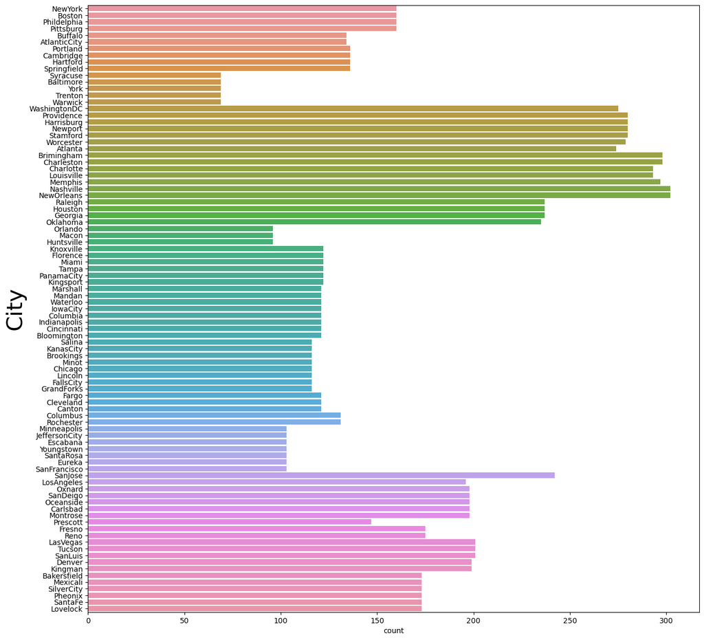

```python
# set the figure size
plt.figure(figsize=(15, 15))

# plot the count plot using countplot()
# y: specifies the data to be plotted on y-axis
# orient: specifies the orientation of the barplot. "h" is used for horizontal orientation
# by default the orientation is vertical; but can be specifies by "v"
countplot = sns.countplot(y=df_insurance['city'], orient="h")

# set the x-axis labels
# fontsize = 30: sets the font size to 30
countplot.set_ylabel('City', fontsize = 30)

# display the plot
plt.show()
```

|  | **We see that there are many cities considered in the data. It is quite difficult to perform meaningful analysis on this variable.** |
| --- | --- |

### 4.1.7 Analyze Relationship Between Target and Categorical Variables

The box-and-whisker plot is commonly used for visualizing relationships between numerical variables and categorical variables.

|  | **Let’s start by creating box-and-whisker plots with seaborn’s boxplot method:** |
| --- | --- |

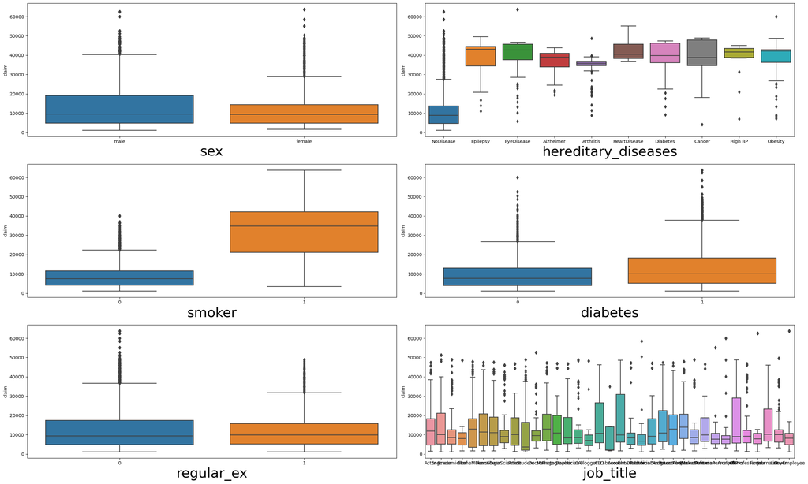

```python
# plot the boxplot for each categorical variable
# create subplots using subplots()
# 6 subplots in 3 rows and 2 columns
# 'figsize' sets the figure size
fig, ax = plt.subplots(3, 2, figsize=(25, 15))

# plot a boxplot for all the categorical variables
for variable, subplot in zip(df_categoric_features, ax.flatten()):

    # x: variable on x-axis
    # y: variable in y-axis
    # data: dataframe to be used
    # ax: specifies the axes object to draw the plot onto
    boxplt = sns.boxplot(x=variable, y='claim', data=df_insurance, ax=subplot)

    # set the x-axis labels
    # fontsize = 30: sets the font size to 30
    boxplt.set_xlabel(variable, fontsize = 30)

# avoid overlapping of the plots using tight_layout()
plt.tight_layout()

# display the plot
plt.show()
```

Since the variable `city` has 91 categories, we shall plot it separately.

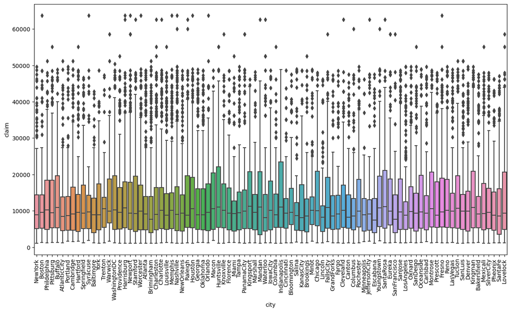

```python
# set the figure size
plt.figure(figsize=(15, 8))

# plot the boxplot for categorical variable 'city'
# x: variable on x-axis
# y: variable in y-axis
# data: dataframe to be used
ax = sns.boxplot(x=df_insurance["city"], y=df_insurance['claim'], data=df_insurance)

# set the x-axis labels
# rotation: rotate the the x-axis ticks by 90˚
# fontsize = 30: sets the font size to 10
ax.set_xticklabels(ax.get_xticklabels(), rotation=90, fontsize = 10)

# display the plot
plt.show()
```

[figure not shown]

### 4.1.8 Feature Engineering

Create a new feature 'region' by combining the cities.

**There are 91 unique cities. We will divide these cities into North-East, West, Mid-West, and South regions.**

Let's create a new variable region. We will replace the original variable `city` with it.

```python
# create a region column and combine the north-east cities
df_insurance['region'] = df_insurance['city'].replace(['NewYork', 'Boston', 'Phildelphia', 'Pittsburg', 'Buffalo',
                                                       'AtlanticCity','Portland', 'Cambridge', 'Hartford',
                                                       'Springfield', 'Syracuse', 'Baltimore', 'York', 'Trenton',
                                                       'Warwick', 'WashingtonDC', 'Providence', 'Harrisburg',
                                                       'Newport', 'Stamford', 'Worcester'],
                                                      'North-East')
```

```python
# combine all the southern cities into the 'region' column
df_insurance['region'] = df_insurance['region'].replace(['Atlanta', 'Brimingham', 'Charleston', 'Charlotte',
                                                         'Louisville', 'Memphis', 'Nashville', 'NewOrleans',
                                                         'Raleigh', 'Houston', 'Georgia', 'Oklahoma', 'Orlando',
                                                         'Macon', 'Huntsville', 'Knoxville', 'Florence', 'Miami',
                                                         'Tampa', 'PanamaCity', 'Kingsport', 'Marshall'],
                                                         'Southern')
```

```python
# combine all the mid-west cities into the 'region' column
df_insurance['region'] = df_insurance['region'].replace(['Mandan', 'Waterloo', 'IowaCity', 'Columbia',
                                                         'Indianapolis', 'Cincinnati', 'Bloomington', 'Salina',
                                                         'KanasCity', 'Brookings', 'Minot', 'Chicago', 'Lincoln',
                                                         'FallsCity', 'GrandForks', 'Fargo', 'Cleveland',
                                                         'Canton', 'Columbus', 'Rochester', 'Minneapolis',
                                                         'JeffersonCity', 'Escabana','Youngstown'],
                                                         'Mid-West')
```

```python
# combine all the western cities into the 'region' column
df_insurance['region'] = df_insurance['region'].replace(['SantaRosa', 'Eureka', 'SanFrancisco', 'SanJose',
                                                         'LosAngeles', 'Oxnard', 'SanDeigo', 'Oceanside',
                                                         'Carlsbad', 'Montrose', 'Prescott', 'Fresno', 'Reno',
                                                         'LasVegas', 'Tucson', 'SanLuis', 'Denver', 'Kingman',
                                                         'Bakersfield', 'Mexicali', 'SilverCity', 'Pheonix',
                                                         'SantaFe', 'Lovelock'],
                                                         'West')
```

```python
# check the unique values of the region using 'unique()'
df_insurance['region'].unique()
```

```
array(['North-East', 'Southern', 'Mid-West', 'West'], dtype=object)
```

```python
df_insurance['region'].value_counts()
```

```
region
Southern      4444
West          4273
North-East    3471
Mid-West      2812
Name: count, dtype: int64
```

```python
# drop the 'city' variable from the dataset using drop()
# axis=1: specifies that the column `city` is to be dropped
df_insurance = df_insurance.drop(['city'], axis=1)
```

Check whether the new variable added into the data frame or not.

```python
# display the top 5 rows of the dataframe
df_insurance.head()
```

|  | age | sex | weight | bmi | hereditary_diseases | no_of_dependents | smoker | bloodpressure | diabetes | regular_ex | job_title | claim | region |
| --- | --- | --- | --- | --- | --- | --- | --- | --- | --- | --- | --- | --- | --- |
| 0 | 60.000000 | male | 64 | 24.300000 | NoDisease | 1 | 0 | 72 | 0 | 0 | Actor | 13112.600000 | North-East |
| 1 | 49.000000 | female | 75 | 22.600000 | NoDisease | 1 | 0 | 78 | 1 | 1 | Engineer | 9567.000000 | North-East |
| 2 | 32.000000 | female | 64 | 17.800000 | Epilepsy | 2 | 1 | 88 | 1 | 1 | Academician | 32734.200000 | North-East |
| 3 | 61.000000 | female | 53 | 36.400000 | NoDisease | 1 | 1 | 72 | 1 | 0 | Chef | 48517.600000 | North-East |
| 4 | 19.000000 | female | 50 | 20.600000 | NoDisease | 0 | 0 | 82 | 1 | 0 | HomeMakers | 1731.700000 | North-East |

#### Analyze relationship between region and claim variable

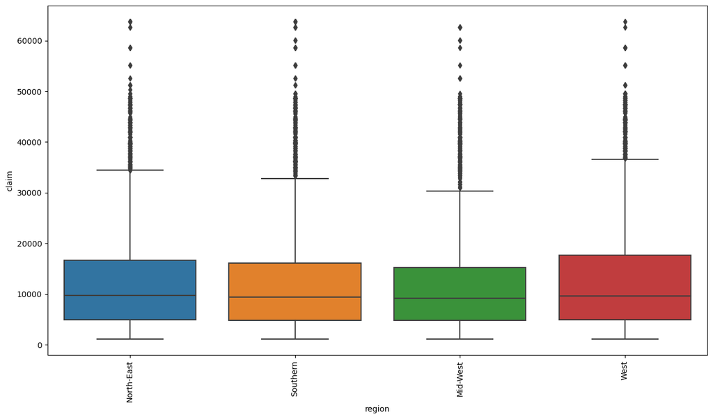

```python
# set figure size
plt.figure(figsize=(15,8))

# boxplot of claim against region
# x: specifies the data on x axis
# y: specifies the data on y axis
# data: specifies the dataframe to be used
ax = sns.boxplot(x="region", y="claim", data=df_insurance)

# rotate labels using set_ticklabels
# labels: specify the tick labels to be used
# rotation: the angle by which tick labels should be rotated
ax.set_xticklabels(labels=ax.get_xticklabels(), rotation=90)

# show the plot
plt.show()
```

The plot shows that there is not much significant difference in the variance of the insurance claim across the regions.

### 4.1.9 Discover Outliers

|  | **I love to know more:** 1. Assumptions of Linear Regression [2. Why Correlation does not Imply Causation](https://bit.ly/2PBvA8T) |
| --- | --- |

#### Importance of detecting an outlier

An outlier is an observation that appears to deviate distinctly from other observations in the data. If the outliers are not removed, the model accuracy may decrease.

**Recollect that one of the assumptions of Linear Regression is there should be no outliers present in the data**

[figure not shown]

In order to detect outliers in numerical data, we perform the following:  
1. Plot boxplot for numerical data  
2. Note the variables for which outliers are present  
3. Remove outliers by IQR method  
4. Plot boxplot to recheck for outliers

**1. Plot boxplot for numerical data**

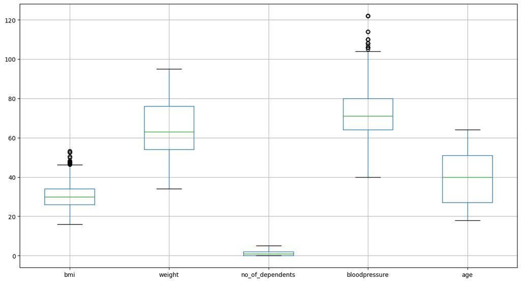

```python
# set the plot size
plt.rcParams['figure.figsize']=(15,8)

# create a boxplot for all numeric features
# column: selects the specified columns
df_numeric_features.boxplot(column=['bmi', 'weight','no_of_dependents', 'bloodpressure', 'age'])

# to display the plot
plt.show()
```

**2. Note the variables for which outliers are present**

|  | From the above plot, we notice that for the variable 'bmi' and 'bloodpressure' there are points above the upper extreme - these points are outliers Let us use the IQR method to remove the outliers |
| --- | --- |

|  | **Outliers can also be detected using standard deviation method if we know that the distribution of values in the sample is Gaussian or Gaussian-like** |
| --- | --- |

|  | **I love to know more:** [How to use Statistics to Identify Outliers in Data](https://bit.ly/33bgNpq) |
| --- | --- |

**3. Remove outliers by IQR method**

```python
# calculate interquartile range

# compute the first quartile using quantile(0.25)
# use .drop() to drop the target variable
# axis=1: specifies that the labels are dropped from the columns
Q1 = df_numeric_features.drop(['claim'], axis=1).quantile(0.25)

# compute the first quartile using quantile(0.75)
# use .drop() to drop the target variable
# axis=1: specifies that the labels are dropped from the columns
Q3 = df_numeric_features.drop(['claim'], axis=1).quantile(0.75)

# calculate of interquartile range
IQR = Q3 - Q1

# print the IQR values for numeric variables
print(IQR)
```

```
age                24.000000
weight             22.000000
bmi                 8.200000
no_of_dependents    2.000000
bloodpressure      16.000000
dtype: float64
```

```python
# filter out the outlier values
# ~ : selects all rows which do not satisfy the condition
# |: bitwise operator OR in python
# any() : returns whether any element is True over the columns
# axis : "1" indicates columns should be altered (use "0" for 'index')
outliers = (df_numeric_features.drop(['claim'], axis=1) < (Q1 - 1.5 * IQR)) | (df_numeric_features.drop(['claim'], axis=1) > (Q3 + 1.5 * IQR))

# Filter out the outliers from the original DataFrame
df_insurance = df_insurance[~outliers.any(axis=1)]
```

A simple way to know whether the outliers have been removed or not is to check the dimensions of the data. If the dimensions are reduced that implies outliers are removed

```python
# check the shape of data using shape
df_insurance.shape
```

```
(14723, 13)
```

|  | **So that the above output shows there is a reduction in the number of rows(from 15000 to 14723). Now, to confirm that the outliers have been removed let us visualize using a boxplot.** |
| --- | --- |

**4. Plot boxplot to recheck for outliers**

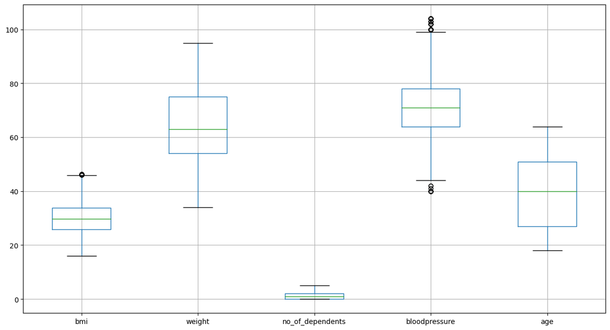

```python
# set figure size
plt.rcParams['figure.figsize']=(15,8)

# recheck for outliers
# column: selects the specifies columns
df_insurance.boxplot(column=['bmi', 'weight','no_of_dependents', 'bloodpressure', 'age'])

# display only the plot
plt.show()
```

Observing the range of the boxplot, we say that the outliers are removed from the original data. The new 'outliers' that you see are moderate outliers that lie within the min/max range before removing the actual outliers

### 4.1.10 Recheck the Correlation

Recheck the correlation after treating outliers. An outlier might either decrease or increase a correlation coefficient, depending on where it is in relation to the other points

[figure not shown]

Recheck the correlation after removing the outliers:  
1. Filter out only the numeric variables from the dataframe  
2. Call the corr() function which will return the correlation matrix of numeric variables  
3. Pass the correlation matrix to the heatmap() function of the seaborn library to plot the heatmap of the correlation matrix

**1. Filter out only the numeric variables from the dataframe**

```python
# filter the numerical features in the dataset
# include=np.number: selects the numeric features
df_numeric_features = df_insurance.select_dtypes(include=np.number)

# display the numeric features
df_numeric_features.columns
```

```
Index(['age', 'weight', 'bmi', 'no_of_dependents', 'bloodpressure', 'claim'], dtype='object')
```

**2. Call the corr() function which will return the correlation matrix of numeric variables**

```python
# generate the correlation matrix
corr =  df_numeric_features.corr()

# print the correlation matrix
corr
```

|  | age | weight | bmi | no_of_dependents | bloodpressure | claim |
| --- | --- | --- | --- | --- | --- | --- |
| age | 1.000000 | 0.282136 | 0.196479 | 0.056423 | 0.023431 | 0.301544 |
| weight | 0.282136 | 1.000000 | 0.237473 | 0.134033 | 0.009877 | 0.080363 |
| bmi | 0.196479 | 0.237473 | 1.000000 | 0.044997 | -0.055260 | 0.196193 |
| no_of_dependents | 0.056423 | 0.134033 | 0.044997 | 1.000000 | 0.027358 | 0.077775 |
| bloodpressure | 0.023431 | 0.009877 | -0.055260 | 0.027358 | 1.000000 | 0.036679 |
| claim | 0.301544 | 0.080363 | 0.196193 | 0.077775 | 0.036679 | 1.000000 |

**3. Pass the correlation matrix to the heatmap() function of the seaborn library to plot the heatmap of the correlation matrix**

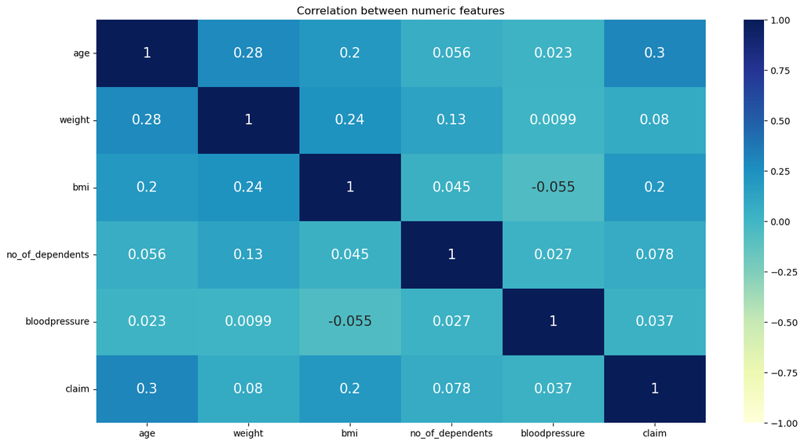

```python
# set the figure size
plt.figure(figsize=(15, 8))

# plot the heat map
# corr: give the correlation matrix
# cmap: colour code used for plotting
# vmax: gives maximum range of values for the chart
# vmin: gives minimum range of values for the chart
# annot: prints the correlation values in the chart
# annot_kws: sets the font size of the annotation
sns.heatmap(corr, cmap='YlGnBu', vmax=1.0, vmin=-1.0, annot = True, annot_kws={"size": 15})

# specify name of the plot
plt.title('Correlation between numeric features')

# display the plot
plt.show()
```

[output not shown]

## 4.2 Prepare the Data

### 4.2.1 Check for Normality

As per the assumptions of linear regression, residuals (actual values - predicted values) should be normally distributed. If the target variable is normally distributed then the residuals are also normally distributed, thus we check the normality only for target variable.

[figure not shown]

In order to check for normality of our target variable,  
1. Plot a histogram and also perform the Jarque-Bera test  
2. If the data is not normally distributed, use log transformation to get near normally distributed data  
3. Recheck for normality by plotting histogram and performing Jarque-Bera test

**1. Plot a histogram and also perform the Jarque-Bera test**

To plot a histogram, we use the hist() function from the matplotlib library

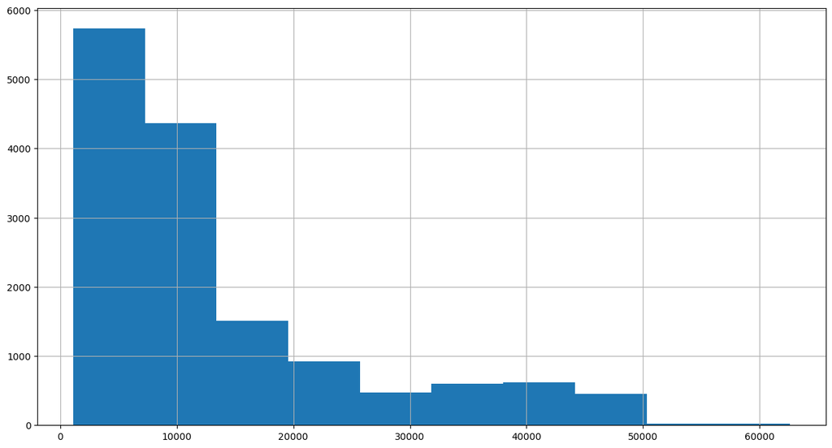

```python
# check the distribution of target variable using hist()
df_insurance.claim.hist()

# display the plot
plt.show()
```

|  | **From the above plot, we can notice that the variable 'claim' is heavily right skewed and not normally distributed** |
| --- | --- |

|  | **We should not only make conclusions through visual representations or only using a statistical test but perform multiple ways to get the best insights** |
| --- | --- |

Let us perform the Jarque-Bera test to check the normality of the target variable.

The null and alternate hypothesis of Jarque-Bera test are as follows:

```
H0: The data is normally distributed
H1: The data is not normally distributed
```

```python
# normality test using jarque_bera()
# the test returns the the test statistics and the p-value of the test
stat, p = jarque_bera(df_insurance["claim"])

# to print the numeric outputs of the Jarque-Bera test upto 3 decimal places
# %.3f: returns the a floating point with 3 decimal digit accuracy
# the '%' holds the place where the number is to be printed
print('Statistics=%.3f, p-value=%.3f' % (stat, p))

# display the conclusion
# set the level of significance to 0.05
alpha = 0.05

# if the p-value is greater than alpha print we accept alpha
# if the p-value is less than alpha print we reject alpha
if p > alpha:
    print('The data is normally distributed (fail to reject H0)')
else:
    print('The data is not normally distributed (reject H0)')
```

```
Statistics=6571.030, p-value=0.000
The data is not normally distributed (reject H0)
```

[figure not shown]

It is apparent that the p-value is less than 0.05. So we have enough evidence to reject the null hypothesis. It can be concluded that the data is not normally distributed.  
Now we opt for log transformation in order to reduce the skewness. We will log transform the claim variable.

[figure not shown]

**Usually for testing the normality of data, the Shaprio Wilk Test is used. However, it does not work if the number of observations are more than 5000 inspite it being more robust than other tests. In case where the observations are more than 5000, other tests like Anderson Darling test or Jarque Bera test may also be used. So we have used Jarque Bera test**

**2. If the data is not normally distributed, use log transformation to get near normally distributed data**

As mentioned above we opt for log transformation. The log transformation can be used to make highly skewed distributions less skewed. We use np.log() to log transform the 'claim' variable. We also store the transformed variable into our data frame with a new name, 'log_claim'.

```python
# log transformation for normality using np.log()
df_insurance['log_claim'] = np.log(df_insurance['claim'])

# display first 5 rows of the data
df_insurance.head()
```

|  | age | sex | weight | bmi | hereditary_diseases | no_of_dependents | smoker | bloodpressure | diabetes | regular_ex | job_title | claim | region | log_claim |
| --- | --- | --- | --- | --- | --- | --- | --- | --- | --- | --- | --- | --- | --- | --- |
| 0 | 60.000000 | male | 64 | 24.300000 | NoDisease | 1 | 0 | 72 | 0 | 0 | Actor | 13112.600000 | North-East | 9.481329 |
| 1 | 49.000000 | female | 75 | 22.600000 | NoDisease | 1 | 0 | 78 | 1 | 1 | Engineer | 9567.000000 | North-East | 9.166075 |
| 2 | 32.000000 | female | 64 | 17.800000 | Epilepsy | 2 | 1 | 88 | 1 | 1 | Academician | 32734.200000 | North-East | 10.396176 |
| 3 | 61.000000 | female | 53 | 36.400000 | NoDisease | 1 | 1 | 72 | 1 | 0 | Chef | 48517.600000 | North-East | 10.789682 |
| 4 | 19.000000 | female | 50 | 20.600000 | NoDisease | 0 | 0 | 82 | 1 | 0 | HomeMakers | 1731.700000 | North-East | 7.456859 |

**3. Recheck for normality by plotting histogram and performing Jarque-Bera test**

Let us first plot a histogram of `log_claim`

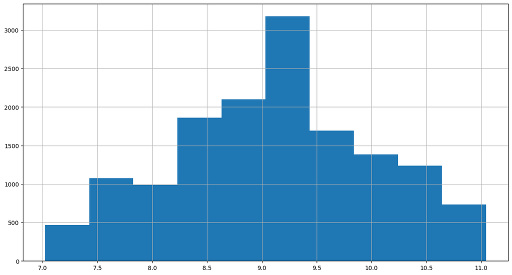

```python
# recheck for normality
# plot the histogram using hist
df_insurance.log_claim.hist()

# display the plot
plt.show()
```

|  | **It can be seen that the variable claim is near normally distributed. However we again confirm by Jarque Bera test** |
| --- | --- |

Let us perform Jarque Bera test

```python
# recheck normality by Jarque-Bera test
# the test returns the the test statistics and the p-value of the test
statn, pv = jarque_bera(df_insurance['log_claim'])

# to print the numeric outputs of the Jarque-Bera test upto 3 decimal places
# %.3f: returns the a floating point with 3 decimal digit accuracy
# the '%' holds the place where the number is to be printed
print('Statistics=%.3f, p-value=%.3f' % (stat, p))

# display the conclusion
# set the level of significance to 0.05
alpha = 0.05

# if the p-value is greater than alpha print we accept alpha
# if the p-value is less than alpha print we reject alpha
if p > alpha:
    print('The data is normally distributed (fail to reject H0)')
else:
    print('The data is not normally distributed (reject H0)')
```

```
Statistics=6571.030, p-value=0.000
The data is not normally distributed (reject H0)
```

[output not shown]

### 4.2.2 One-Way Anova

Perform One-Way ANOVA to compare two means from two independent (unrelated) groups. For example, we apply ANOVA to see whether the mean of claim is significantly different across gender

The null and alternate hypothesis of one-way anova are as follows:

```
H0: Population means all are equal
H1: Population means are not all equal
```

#### One Way Anova for 'Sex' on 'Claim'

```python
# perform one way anova for sex on claim using f_oneway()
f_oneway(df_insurance['claim'][df_insurance['sex'] == 'male'],
             df_insurance['claim'][df_insurance['sex'] == 'female'])
```

```
F_onewayResult(statistic=68.99835913263617, pvalue=1.070652488972223e-16)
```

The F-statistic = 68.99 and the p-value < 0.05, which indicates that there is a significant difference in the mean of the insurance claim across gender. We may consider building separate models for each gender. However, in this example we go ahead and build a single model for both genders.

### 4.2.3 Dummy Encoding of Categorical Variables

To build linear regression models we use OLS method. As seen before in section 4.1.2, it is seen that some variables are categorical. The OLS method fails to perform in presence of categorical variables. To overcome this we use dummy encoding.

[figure not shown]

We need to perform dummy encoding on our categorical variables before we proceed, since the method of OLS works only on numeric data  
In order to dummy encode, we do the following:  
1. Filter numerical and categorical variables  
2. Dummy encode the catergorical variables  
3. Concatenate numerical and dummy encoded categorical variables

**1. Filter numerical and categorical variables**

```python
# filter the numerical features in the dataset using select_dtypes()
# include=np.number: selects the numeric features
df_numeric_features = df_insurance.select_dtypes(include=np.number)

# display the numeric features
df_numeric_features.columns
```

```
Index(['age', 'weight', 'bmi', 'no_of_dependents', 'bloodpressure', 'claim',
       'log_claim'],
      dtype='object')
```

```python
# filter the categorical features in the dataset using select_dtypes()
# include=[np.object]: selects the categoric features
df_categoric_features = df_insurance.select_dtypes(include=[object])

# display categorical features
df_categoric_features.columns
```

```
Index(['sex', 'hereditary_diseases', 'smoker', 'diabetes', 'regular_ex',
       'job_title', 'region'],
      dtype='object')
```

**2. Dummy encode the catergorical variables**

```python
# create data frame with only categorical variables that have been encoded

# for all categoric variables create dummy variables
for col in df_categoric_features.columns.values:

    # for a feature create dummy variables using get_dummies()
    # prefix: specify the prefix before creating the dummy variable
    # "drop_first=True": creates 'n-1' dummy variables
    dummy_encoded_variables = pd.get_dummies(df_categoric_features[col], prefix=col, drop_first=True)

    # concatenate the categoric features with dummy variables using concat()
    # axis=1: specifies that the concatenation is column wise
    df_categoric_features = pd.concat([df_categoric_features, dummy_encoded_variables],axis=1)

    # drop the orginal categorical variable from the dataframe
    # axis=1: specifies that the column is to be dropped
    # inplace: makes permanent changes in the dataframe
    df_categoric_features.drop([col], axis=1, inplace=True)
```

**3. Concatenate numerical and dummy encoded categorical variables**

```python
# concatenate the numerical and dummy encoded categorical variables using concat()
# axis=1: specifies that the concatenation is column wise
df_insurance_dummy = pd.concat([df_numeric_features, df_categoric_features], axis=1)

# display data with dummy variables
df_insurance_dummy.head()
```

|  | age | weight | bmi | no_of_dependents | bloodpressure | claim | log_claim | sex_male | hereditary_diseases_Arthritis | hereditary_diseases_Cancer | hereditary_diseases_Diabetes | hereditary_diseases_Epilepsy | hereditary_diseases_EyeDisease | hereditary_diseases_HeartDisease | hereditary_diseases_High BP | hereditary_diseases_NoDisease | hereditary_diseases_Obesity | smoker_1 | diabetes_1 | regular_ex_1 | job_title_Accountant | job_title_Actor | job_title_Analyst | job_title_Architect | job_title_Beautician | job_title_Blogger | job_title_Buisnessman | job_title_CA | job_title_CEO | … |
| --- | --- | --- | --- | --- | --- | --- | --- | --- | --- | --- | --- | --- | --- | --- | --- | --- | --- | --- | --- | --- | --- | --- | --- | --- | --- | --- | --- | --- | --- | --- |
| 0 | 60.000000 | 64 | 24.300000 | 1 | 72 | 13112.600000 | 9.481329 | True | False | False | False | False | False | False | False | True | False | False | False | False | False | True | False | False | False | False | False | False | False | … |
| 1 | 49.000000 | 75 | 22.600000 | 1 | 78 | 9567.000000 | 9.166075 | False | False | False | False | False | False | False | False | True | False | False | True | True | False | False | False | False | False | False | False | False | False | … |
| 2 | 32.000000 | 64 | 17.800000 | 2 | 88 | 32734.200000 | 10.396176 | False | False | False | False | True | False | False | False | False | False | True | True | True | False | False | False | False | False | False | False | False | False | … |
| 3 | 61.000000 | 53 | 36.400000 | 1 | 72 | 48517.600000 | 10.789682 | False | False | False | False | False | False | False | False | True | False | True | True | False | False | False | False | False | False | False | False | False | False | … |
| 4 | 19.000000 | 50 | 20.600000 | 0 | 82 | 1731.700000 | 7.456859 | False | False | False | False | False | False | False | False | True | False | False | True | False | False | False | False | False | False | False | False | False | False | … |

[figure not shown]

|  | **There are various forms of encoding like n-1 dummy encoding, one hot encoding, label encoding, frequency encoding** |
| --- | --- |

|  | **I love to know more:** 1. FAQ: What is Dummy Coding? [2. Encoding Categorical Features](https://bit.ly/2q9Omt9) |
| --- | --- |

[output not shown]

## 5. Linear Regression (OLS)

### 5.1 Multiple Linear Regression - Full Model - with Log Transformed Dependent Variable (OLS)

In this section we build a full model with linear regression using OLS (Ordinary Least Square) technique. By full model we indicate that we consider all the independent variables that are present in the dataset.

[figure not shown]

In order to build the model, we do the following:  
1. Split the data into training and test sets  
2. Build model using sm.OLS().fit()  
3. Predict the values using test set  
4. Compute accuracy measures  
5. Tabulate the results

**1. Split the data into training and test sets**

```python
# add the intercept column to the dataset
df_insurance_dummy = sm.add_constant(df_insurance_dummy)

# separate the independent and dependent variables
# drop(): drops the specified columns
# axis=1: specifies that the column is to be dropped
X = df_insurance_dummy.drop(['claim','log_claim'], axis=1)

# extract the target variable from the data set
y = df_insurance_dummy[['log_claim','claim']]

# Convert boolean columns to integers
X = X.applymap(lambda x: 1 if x is True else (0 if x is False else x))

# split data into train subset and test subset for predictor and target variables
# random_state: the seed used by the random number generator
X_train, X_test, y_train, y_test = train_test_split(X, y, random_state=1)

# check the dimensions of the train & test subset for

# print dimension of predictors train set
print("The shape of X_train is:",X_train.shape)

# print dimension of predictors test set
print("The shape of X_test is:",X_test.shape)

# print dimension of target train set
print("The shape of y_train is:",y_train.shape)

# print dimension of target test set
print("The shape of y_test is:",y_test.shape)
```

```
The shape of X_train is: (11042, 56)
The shape of X_test is: (3681, 56)
The shape of y_train is: (11042, 2)
The shape of y_test is: (3681, 2)
```

**2. Build model using sm.OLS().fit()**

```python
# build a full model using OLS()
# consider the log of claim
linreg_full_model_withlog = sm.OLS(y_train["log_claim"], X_train).fit()

# print the summary output
print(linreg_full_model_withlog.summary())
```

```
                            OLS Regression Results
==============================================================================
Dep. Variable:              log_claim   R-squared:                       0.745
Model:                            OLS   Adj. R-squared:                  0.744
Method:                 Least Squares   F-statistic:                     584.1
Date:                Thu, 12 Sep 2024   Prob (F-statistic):               0.00
Time:                        08:02:30   Log-Likelihood:                -7083.9
No. Observations:               11042   AIC:                         1.428e+04
Df Residuals:                   10986   BIC:                         1.469e+04
Df Model:                          55
Covariance Type:            nonrobust
====================================================================================================
                                       coef    std err          t      P>|t|      [0.025      0.975]
----------------------------------------------------------------------------------------------------
const                                7.6235      0.070    108.530      0.000       7.486       7.761
age                                  0.0333      0.000     93.222      0.000       0.033       0.034
weight                              -0.0003      0.000     -0.817      0.414      -0.001       0.000
bmi                                  0.0087      0.001     10.366      0.000       0.007       0.010
no_of_dependents                     0.0925      0.004     25.083      0.000       0.085       0.100
bloodpressure                        0.0015      0.000      3.490      0.000       0.001       0.002
sex_male                            -0.0827      0.009     -9.045      0.000      -0.101      -0.065
hereditary_diseases_Arthritis        0.1930      0.068      2.841      0.005       0.060       0.326
hereditary_diseases_Cancer          -0.2820      0.068     -4.150      0.000      -0.415      -0.149
hereditary_diseases_Diabetes        -0.2340      0.064     -3.649      0.000      -0.360      -0.108
hereditary_diseases_Epilepsy        -0.2272      0.075     -3.010      0.003      -0.375      -0.079
hereditary_diseases_EyeDisease      -0.2662      0.068     -3.920      0.000      -0.399      -0.133
hereditary_diseases_HeartDisease    -0.0597      0.073     -0.817      0.414      -0.203       0.084
hereditary_diseases_High BP         -0.4212      0.080     -5.293      0.000      -0.577      -0.265
hereditary_diseases_NoDisease       -0.6365      0.045    -14.065      0.000      -0.725      -0.548
hereditary_diseases_Obesity         -0.2517      0.062     -4.030      0.000      -0.374      -0.129
smoker_1                             1.3349      0.013    103.875      0.000       1.310       1.360
diabetes_1                           0.0674      0.011      6.233      0.000       0.046       0.089
regular_ex_1                         0.0134      0.011      1.240      0.215      -0.008       0.035
job_title_Accountant                 0.1044      0.042      2.500      0.012       0.023       0.186
job_title_Actor                      0.0389      0.037      1.062      0.288      -0.033       0.111
job_title_Analyst                   -0.0208      0.045     -0.462      0.644      -0.109       0.068
job_title_Architect                  0.0452      0.042      1.066      0.287      -0.038       0.128
job_title_Beautician                 0.0860      0.042      2.051      0.040       0.004       0.168
job_title_Blogger                   -0.0688      0.045     -1.535      0.125      -0.157       0.019
job_title_Buisnessman                0.0428      0.047      0.910      0.363      -0.049       0.135
```

[output cut: 26 more lines]

```
job_title_Technician                -0.0601      0.044     -1.350      0.177      -0.147       0.027
region_North-East                   -0.0042      0.014     -0.306      0.759      -0.031       0.023
region_Southern                     -0.0076      0.013     -0.585      0.559      -0.033       0.018
region_West                         -0.0102      0.013     -0.778      0.437      -0.036       0.015
==============================================================================
Omnibus:                     3177.176   Durbin-Watson:                   2.008
Prob(Omnibus):                  0.000   Jarque-Bera (JB):             9635.687
Skew:                           1.489   Prob(JB):                         0.00
Kurtosis:                       6.475   Cond. No.                     4.61e+03
==============================================================================

Notes:
[1] Standard Errors assume that the covariance matrix of the errors is correctly specified.
[2] The condition number is large, 4.61e+03. This might indicate that there are
strong multicollinearity or other numerical problems.
```

[output not shown]

[figure not shown]

Condition Number : One way to assess multicollinearity is to compute the condition number(CN). If CN is less than 100, there is no multicollinearity. If CN is between 100 and 1000, there is moderate multicollinearity and if CN is greater 1000 there is severe multicollinearity in the data  
Durbin-Watson : The Durbin-Watson statistic will always have a value between 0 and 4. A value of 2.0 means that there is no autocorrelation detected in the sample. Values from 0 to less than 2 indicate positive autocorrelation and values from from 2 to 4 indicate negative autocorrelation

**3. Predict the values using test set**

```python
# predict the 'log_claim' using predict()
linreg_full_model_withlog_predictions = linreg_full_model_withlog.predict(X_test)
```

|  | **Note that the predicted values are log transformed claim. In order to get claim values, we take the antilog of these predicted values by using the function np.exp()** |
| --- | --- |

```python
# take the exponential of predictions using np.exp()
predicted_claim = np.exp(linreg_full_model_withlog_predictions)

# extract the 'claim' values from the test data
actual_claim = y_test['claim']
```

**4. Compute accuracy measures**

Now we calculate accuray measures like Root-mean-square-error (RMSE), R-squared and Adjusted R-squared.

```python
# calculate rmse using rmse()
linreg_full_model_withlog_rmse = rmse(actual_claim, predicted_claim)

# calculate R-squared using rsquared
linreg_full_model_withlog_rsquared = linreg_full_model_withlog.rsquared

# calculate Adjusted R-Squared using rsquared_adj
linreg_full_model_withlog_rsquared_adj = linreg_full_model_withlog.rsquared_adj
```

**5. Tabulate the results**

```python
# create dataframe 'score_card'
# columns: specifies the columns to be selected
score_card = pd.DataFrame(columns=['Model_Name', 'R-Squared', 'Adj. R-Squared', 'RMSE'])

# print the score card
score_card
```

|  | Model_Name | R-Squared | Adj. R-Squared | RMSE |
| --- | --- | --- | --- | --- |

```python
# compile the required information
linreg_full_model_withlog_metrics = pd.DataFrame([{
    'Model_Name': "Linreg full model with log of target variable",
    'RMSE': linreg_full_model_withlog_rmse,
    'R-Squared': linreg_full_model_withlog_rsquared,
    'Adj. R-Squared': linreg_full_model_withlog_rsquared_adj
}])

# append our result table using append()
# ignore_index=True: does not use the index labels
# python can only append a Series if ignore_index=True or if the Series has a name
score_card = pd.concat([score_card,linreg_full_model_withlog_metrics], ignore_index=True)

# print the result table
score_card
```

|  | Model_Name | R-Squared | Adj. R-Squared | RMSE |
| --- | --- | --- | --- | --- |
| 0 | Linreg full model with log of target variable | 0.745162 | 0.743886 | 7947.405055 |

|  | **Let us also take a look at building a linear regression full model without performing any kind of transformation on target variable** |
| --- | --- |

### 5.2 Multiple Linear Regression - Full Model - without Log Transformed Dependent Variable (OLS)

In this section we build a full model with linear regression using OLS (Ordinary Least Square) technique. By full model we indicate that we consider all the independent variables that are present in the dataset.

In this case, we do not consider any kind of transformation on the dependent variable, we use the 'claim' variable as it is.

[figure not shown]

We do not need to do the train and test split again since it has been done while building the previous model  
In order to build the model, we do the following:  
1. Build model using sm.OLS().fit()  
2. Predict the values using test set  
3. Compute the accuracy measures  
4. Tabulate the results

**1. Build model using sm.OLS().fit()**

```python
# ordinary least squares regression
# we use the train and test sets from the previous model
# however, now we shall build a model using the variable 'claim'

# build a full model using OLS()
linreg_full_model_withoutlog = sm.OLS(y_train['claim'], X_train).fit()

# print the summary output
print(linreg_full_model_withoutlog.summary())
```

```
                            OLS Regression Results
==============================================================================
Dep. Variable:                  claim   R-squared:                       0.765
Model:                            OLS   Adj. R-squared:                  0.764
Method:                 Least Squares   F-statistic:                     651.8
Date:                Thu, 12 Sep 2024   Prob (F-statistic):               0.00
Time:                        08:02:38   Log-Likelihood:            -1.1150e+05
No. Observations:               11042   AIC:                         2.231e+05
Df Residuals:                   10986   BIC:                         2.235e+05
Df Model:                          55
Covariance Type:            nonrobust
====================================================================================================
                                       coef    std err          t      P>|t|      [0.025      0.975]
----------------------------------------------------------------------------------------------------
const                             1930.3475    897.945      2.150      0.032     170.213    3690.482
age                                263.8397      4.570     57.727      0.000     254.881     272.799
weight                             -39.9565      4.585     -8.714      0.000     -48.945     -30.968
bmi                                225.0768     10.673     21.088      0.000     204.155     245.998
no_of_dependents                   489.8947     47.136     10.393      0.000     397.500     582.289
bloodpressure                       26.2334      5.366      4.888      0.000      15.714      36.752
sex_male                             1.2630    116.874      0.011      0.991    -227.831     230.357
hereditary_diseases_Arthritis    -2337.6038    868.439     -2.692      0.007   -4039.901    -635.306
hereditary_diseases_Cancer         674.6462    868.596      0.777      0.437   -1027.958    2377.250
hereditary_diseases_Diabetes     -2185.4704    819.839     -2.666      0.008   -3792.502    -578.438
hereditary_diseases_Epilepsy        55.4566    964.818      0.057      0.954   -1835.760    1946.674
hereditary_diseases_EyeDisease   -2235.5795    867.978     -2.576      0.010   -3936.972    -534.187
hereditary_diseases_HeartDisease  4548.5316    934.059      4.870      0.000    2717.609    6379.455
hereditary_diseases_High BP      -2468.8700   1017.382     -2.427      0.015   -4463.121    -474.619
hereditary_diseases_NoDisease    -1.156e+04    578.499    -19.990      0.000   -1.27e+04   -1.04e+04
hereditary_diseases_Obesity       -660.8869    798.643     -0.828      0.408   -2226.370     904.596
smoker_1                          1.995e+04    164.283    121.432      0.000    1.96e+04    2.03e+04
diabetes_1                        1265.4863    138.283      9.151      0.000     994.427    1536.545
regular_ex_1                      -928.0044    138.011     -6.724      0.000   -1198.530    -657.479
job_title_Accountant               733.3261    533.907      1.374      0.170    -313.228    1779.880
job_title_Actor                   -165.9424    468.826     -0.354      0.723   -1084.926     753.041
job_title_Analyst                -1493.4068    576.690     -2.590      0.010   -2623.824    -362.990
job_title_Architect                896.9194    542.507      1.653      0.098    -166.492    1960.330
job_title_Beautician               632.9902    535.926      1.181      0.238    -417.522    1683.502
job_title_Blogger                 -804.9180    572.615     -1.406      0.160   -1927.346     317.510
job_title_Buisnessman              -65.6399    600.480     -0.109      0.913   -1242.690    1111.410
```

[output cut: 26 more lines]

```
job_title_Technician              -284.0798    568.826     -0.499      0.617   -1399.080     830.921
region_North-East                  -96.5992    174.307     -0.554      0.579    -438.273     245.074
region_Southern                     81.1170    166.066      0.488      0.625    -244.402     406.636
region_West                       -130.4033    167.237     -0.780      0.436    -458.217     197.411
==============================================================================
Omnibus:                     3106.704   Durbin-Watson:                   1.980
Prob(Omnibus):                  0.000   Jarque-Bera (JB):            10201.522
Skew:                           1.421   Prob(JB):                         0.00
Kurtosis:                       6.754   Cond. No.                     4.61e+03
==============================================================================

Notes:
[1] Standard Errors assume that the covariance matrix of the errors is correctly specified.
[2] The condition number is large, 4.61e+03. This might indicate that there are
strong multicollinearity or other numerical problems.
```

[output not shown]

#### Calculate the p-values to know the insignificant variables

```python
# calculate the p-values for all the variables
# create a dataframe using pd.DataFrame()
# columns: specifies the column names
linreg_full_model_withoutlog_pvalues = pd.DataFrame(linreg_full_model_withoutlog.pvalues, columns=["P-Value"])

# print the values
linreg_full_model_withoutlog_pvalues
```

|  | P-Value |
| --- | --- |
| const | 0.031598 |
| age | 0.000000 |
| weight | 0.000000 |
| bmi | 0.000000 |
| no_of_dependents | 0.000000 |
| bloodpressure | 0.000001 |
| sex_male | 0.991378 |
| hereditary_diseases_Arthritis | 0.007119 |
| hereditary_diseases_Cancer | 0.437347 |
| hereditary_diseases_Diabetes | 0.007693 |
| hereditary_diseases_Epilepsy | 0.954165 |
| hereditary_diseases_EyeDisease | 0.010019 |
| hereditary_diseases_HeartDisease | 0.000001 |
| hereditary_diseases_High BP | 0.015253 |
| hereditary_diseases_NoDisease | 0.000000 |
| hereditary_diseases_Obesity | 0.407964 |
| smoker_1 | 0.000000 |
| diabetes_1 | 0.000000 |
| regular_ex_1 | 0.000000 |
| job_title_Accountant | 0.169622 |
| job_title_Actor | 0.723381 |
| job_title_Analyst | 0.009621 |
| job_title_Architect | 0.098301 |
| job_title_Beautician | 0.237583 |
| job_title_Blogger | 0.159845 |
| job_title_Buisnessman | 0.912957 |
| job_title_CA | 0.494423 |
| job_title_CEO | 0.192397 |
| job_title_Chef | 0.268452 |
| job_title_Clerks | 0.099560 |
| job_title_Dancer | 0.829865 |
| job_title_DataScientist | 0.020065 |
| job_title_DefencePersonnels | 0.109073 |
| job_title_Doctor | 0.015459 |
| job_title_Engineer | 0.000351 |
| job_title_Farmer | 0.925659 |
| job_title_FashionDesigner | 0.475014 |
| job_title_FilmDirector | 0.824479 |
| job_title_FilmMaker | 0.774649 |
| job_title_GovEmployee | 0.119212 |
| job_title_HomeMakers | 0.051055 |
| job_title_HouseKeeper | 0.559661 |
| job_title_ITProfessional | 0.873967 |
| job_title_Journalist | 0.780281 |
| job_title_Labourer | 0.091346 |
| job_title_Lawyer | 0.056377 |
| job_title_Manager | 0.001158 |
| job_title_Photographer | 0.000001 |
| job_title_Police | 0.464513 |
| job_title_Politician | 0.000078 |
| job_title_Singer | 0.042102 |
| job_title_Student | 0.014238 |
| job_title_Technician | 0.617497 |
| region_North-East | 0.579460 |
| region_Southern | 0.625231 |
| region_West | 0.435553 |

The above table shows the p-values for all the variables to decide the significant variables

Let's create a list of insignificant variables

```python
# select insignificant variables
insignificant_variables = linreg_full_model_withoutlog_pvalues[
                                                        linreg_full_model_withoutlog_pvalues['P-Value']  > 0.05]

# get the position of a specified value
insigni_var = insignificant_variables.index

# convert the list of variables to 'list' type
insigni_var = insigni_var.to_list()

# get the list of insignificant variables
insigni_var
```

```
['sex_male',
 'hereditary_diseases_Cancer',
 'hereditary_diseases_Epilepsy',
 'hereditary_diseases_Obesity',
 'job_title_Accountant',
 'job_title_Actor',
 'job_title_Architect',
 'job_title_Beautician',
 'job_title_Blogger',
 'job_title_Buisnessman',
 'job_title_CA',
 'job_title_CEO',
 'job_title_Chef',
 'job_title_Clerks',
 'job_title_Dancer',
 'job_title_DefencePersonnels',
 'job_title_Farmer',
 'job_title_FashionDesigner',
 'job_title_FilmDirector',
 'job_title_FilmMaker',
 'job_title_GovEmployee',
 'job_title_HomeMakers',
 'job_title_HouseKeeper',
 'job_title_ITProfessional',
 'job_title_Journalist',
 'job_title_Labourer',
 'job_title_Lawyer',
 'job_title_Police',
 'job_title_Technician',
 'region_North-East',
 'region_Southern',
 'region_West']
```

[figure not shown]

**2. Predict the values using test set**

```python
# predict the claim using predict()
predicted_claim = linreg_full_model_withoutlog.predict(X_test)

# extract the 'claim' values from the test data
actual_claim = y_test['claim']
```

**3. Compute model accuracy measures**

Now we calculate accuray measures like Root-mean-square-error (RMSE), R-squared and Adjusted R-squared.

```python
# calculate rmse using rmse()
linreg_full_model_withoutlog_rmse = rmse(actual_claim, predicted_claim)

# calculate R-squared using rsquared
linreg_full_model_withoutlog_rsquared = linreg_full_model_withoutlog.rsquared

# calculate Adjusted R-Squared using rsquared_adj
linreg_full_model_withoutlog_rsquared_adj = linreg_full_model_withoutlog.rsquared_adj
```

**4. Tabulate the results**

```python
# Compile the required information into a DataFrame
linreg_full_model_withoutlog_metrics = pd.DataFrame([{
    'Model_Name': "Linreg full model without log of target variable",
    'RMSE': linreg_full_model_withoutlog_rmse,
    'R-Squared': linreg_full_model_withoutlog_rsquared,
    'Adj. R-Squared': linreg_full_model_withoutlog_rsquared_adj
}])

# Concatenate the new row to the score_card DataFrame
score_card = pd.concat([score_card, linreg_full_model_withoutlog_metrics], ignore_index=True)

# Print the result table
score_card
```

|  | Model_Name | R-Squared | Adj. R-Squared | RMSE |
| --- | --- | --- | --- | --- |
| 0 | Linreg full model with log of target variable | 0.745162 | 0.743886 | 7947.405055 |
| 1 | Linreg full model without log of target variable | 0.765424 | 0.764249 | 5916.234909 |

[figure not shown]

**On comparing the above models, it is seen that the R-squared and the Adjusted R-squared value for the model considering log transformation of the variable 'claim' is lower than the other model. And, the RMSE value of the model without considering the log transformation is considerably lower. So, we continue with variable 'claim' as it is, instead of opting for log transformation**

## 5.3. Fine Tune Linear Regression Model (OLS)

### 5.3.1 Linear Regression after Removing Insignificant Variable (OLS)

The null and alternate hypothesis of linear regression as follows:

```
H0: All beta coefficients are zero
H1: At least one beta coefficient is not zero
```

From the summary output of our linear regression model in section 5.2, we notice some of the variables are insignificant.

Now, we go ahead and build our next model without considering the above mentioned insignificant variables.

[figure not shown]

In order to build the linear regression model after removing insignificant variable, we do the following:  
1. Consider the significant variables  
2. Split the data into training and test sets  
3. Build model using sm.OLS().fit()  
4. Predict the values using test set  
5. Compute accuracy measures  
6. Tabulate the results  
Note: We won't split the data into train and test set again since it has been done while building the previous model

**1. Consider the significant variables**

```python
# drop the insignificant variables
X_significant = df_insurance.drop(["sex","job_title","region","claim","log_claim"], axis=1)
```

```python
# filter the categorical features in the dataset using select_dtypes()
# include=[np.object]: selects the categoric features
df_significant_categoric_features = X_significant.select_dtypes(include=[object])

# display categorical features
df_significant_categoric_features.columns
```

```
Index(['hereditary_diseases', 'smoker', 'diabetes', 'regular_ex'], dtype='object')
```

**Dummy encode the catergorical variables**

```python
# create data frame with only categorical variables that have been encoded

# for all categoric variables create dummy variables
for col in df_significant_categoric_features.columns.values:

    # for a feature create dummy variables using get_dummies()
    # prefix: specify the prefix before creating the dummy variable
    # "drop_first=True": creates 'n-1' dummy variables
    dummy_encoded_variables = pd.get_dummies(df_significant_categoric_features[col], prefix=col, drop_first=True)

    # concatenate the categoric features with dummy variables using concat()
    # axis=1: specifies that the concatenation is column wise
    df_significant_categoric_features = pd.concat([df_significant_categoric_features, dummy_encoded_variables],axis=1)

    # drop the orginal categorical variable from the dataframe
    # axis=1: specifies that the column is to be dropped
    # inplace: makes permanent changes in the dataframe
    df_significant_categoric_features.drop([col], axis=1, inplace=True)
```

**Concatenate numerical and dummy encoded categorical variables**

```python
# concatenate the numerical and dummy encoded categorical variables using concat()
# axis=1: specifies that the concatenation is column wise
df_insurance_significant = pd.concat([df_numeric_features, df_significant_categoric_features], axis=1)

# display data with dummy variables
df_insurance_significant.head()
```

|  | age | weight | bmi | no_of_dependents | bloodpressure | claim | log_claim | hereditary_diseases_Arthritis | hereditary_diseases_Cancer | hereditary_diseases_Diabetes | hereditary_diseases_Epilepsy | hereditary_diseases_EyeDisease | hereditary_diseases_HeartDisease | hereditary_diseases_High BP | hereditary_diseases_NoDisease | hereditary_diseases_Obesity | smoker_1 | diabetes_1 | regular_ex_1 |
| --- | --- | --- | --- | --- | --- | --- | --- | --- | --- | --- | --- | --- | --- | --- | --- | --- | --- | --- | --- |
| 0 | 60.000000 | 64 | 24.300000 | 1 | 72 | 13112.600000 | 9.481329 | False | False | False | False | False | False | False | True | False | False | False | False |
| 1 | 49.000000 | 75 | 22.600000 | 1 | 78 | 9567.000000 | 9.166075 | False | False | False | False | False | False | False | True | False | False | True | True |
| 2 | 32.000000 | 64 | 17.800000 | 2 | 88 | 32734.200000 | 10.396176 | False | False | False | True | False | False | False | False | False | True | True | True |
| 3 | 61.000000 | 53 | 36.400000 | 1 | 72 | 48517.600000 | 10.789682 | False | False | False | False | False | False | False | True | False | True | True | False |
| 4 | 19.000000 | 50 | 20.600000 | 0 | 82 | 1731.700000 | 7.456859 | False | False | False | False | False | False | False | True | False | False | True | False |

**2. Split the data into training and test sets**

```python
# add the intercept column to the dataset
df_insurance_significant = sm.add_constant(df_insurance_significant)

# separate the independent and dependent variables
# drop(): drops the specified columns
# axis=1: specifies that the column is to be dropped
X = df_insurance_significant.drop(['claim','log_claim'], axis=1)

# extract the target variable from the data set
y = df_insurance_significant[['log_claim','claim']]

# Convert boolean columns to integers
X = X.applymap(lambda x: 1 if x is True else (0 if x is False else x))

# split data into train subset and test subset for predictor and target variables
# random_state: the seed used by the random number generator
X_train_significant, X_test_significant, y_train, y_test = train_test_split(X, y, random_state=1)

# check the dimensions of the train & test subset for

# print dimension of predictors train set
print("The shape of X_train is:",X_train.shape)

# print dimension of predictors test set
print("The shape of X_test is:",X_test.shape)

# print dimension of target train set
print("The shape of y_train is:",y_train.shape)

# print dimension of target test set
print("The shape of y_test is:",y_test.shape)
```

```
The shape of X_train is: (11042, 56)
The shape of X_test is: (3681, 56)
The shape of y_train is: (11042, 2)
The shape of y_test is: (3681, 2)
```

**1. Build model using sm.OLS().fit()**

```python
# build a full model with significant variables using OLS()
linreg_model_with_significant_var = sm.OLS(y_train['claim'], X_train_significant).fit()

# to print the summary output
print(linreg_model_with_significant_var.summary())
```

```
                            OLS Regression Results
==============================================================================
Dep. Variable:                  claim   R-squared:                       0.761
Model:                            OLS   Adj. R-squared:                  0.761
Method:                 Least Squares   F-statistic:                     2064.
Date:                Thu, 12 Sep 2024   Prob (F-statistic):               0.00
Time:                        08:02:46   Log-Likelihood:            -1.1160e+05
No. Observations:               11042   AIC:                         2.232e+05
Df Residuals:                   11024   BIC:                         2.234e+05
Df Model:                          17
Covariance Type:            nonrobust
====================================================================================================
                                       coef    std err          t      P>|t|      [0.025      0.975]
----------------------------------------------------------------------------------------------------
const                             2421.3254    805.295      3.007      0.003     842.802    3999.849
age                                260.9178      4.311     60.517      0.000     252.467     269.369
weight                             -39.1458      4.470     -8.758      0.000     -47.907     -30.385
bmi                                222.1813     10.594     20.972      0.000     201.415     242.948
no_of_dependents                   464.9031     46.766      9.941      0.000     373.233     556.573
bloodpressure                       30.1887      5.346      5.647      0.000      19.709      40.668
hereditary_diseases_Arthritis    -2289.3687    864.738     -2.647      0.008   -3984.410    -594.328
hereditary_diseases_Cancer         204.5989    862.460      0.237      0.812   -1485.977    1895.175
hereditary_diseases_Diabetes     -1988.1806    822.466     -2.417      0.016   -3600.362    -375.999
hereditary_diseases_Epilepsy       312.5081    961.763      0.325      0.745   -1572.719    2197.735
hereditary_diseases_EyeDisease   -2071.0043    861.910     -2.403      0.016   -3760.503    -381.505
hereditary_diseases_HeartDisease  3875.5194    922.352      4.202      0.000    2067.545    5683.494
hereditary_diseases_High BP      -2094.0707   1011.607     -2.070      0.038   -4077.003    -111.139
hereditary_diseases_NoDisease    -1.164e+04    577.759    -20.152      0.000   -1.28e+04   -1.05e+04
hereditary_diseases_Obesity       -855.7985    798.410     -1.072      0.284   -2420.824     709.227
smoker_1                          2.001e+04    161.869    123.629      0.000    1.97e+04    2.03e+04
diabetes_1                        1248.7716    137.485      9.083      0.000     979.276    1518.268
regular_ex_1                      -945.6538    137.510     -6.877      0.000   -1215.199    -676.109
==============================================================================
Omnibus:                     3205.126   Durbin-Watson:                   1.982
Prob(Omnibus):                  0.000   Jarque-Bera (JB):            10537.776
Skew:                           1.468   Prob(JB):                         0.00
Kurtosis:                       6.779   Cond. No.                     3.67e+03
==============================================================================

Notes:
[1] Standard Errors assume that the covariance matrix of the errors is correctly specified.
[2] The condition number is large, 3.67e+03. This might indicate that there are
strong multicollinearity or other numerical problems.
```

[output not shown]

**2. Predict the values using test set**

```python
# predict the 'claim' using predict()
predicted_claim = linreg_model_with_significant_var.predict(X_test_significant)

# extract the 'claim' values from the test data
actual_claim = y_test['claim']
```

**3. Compute model accuracy measures**

Now we calculate accuray measures like Root-mean-square-error (RMSE), R-squared and Adjusted R-squared.

```python
# calculate rmse using rmse()
linreg_model_with_significant_var_rmse = rmse(actual_claim, predicted_claim)

# calculate R-squared using rsquared
linreg_model_with_significant_var_rsquared = linreg_model_with_significant_var.rsquared

# calculate Adjusted R-Squared using rsquared_adj
linreg_model_with_significant_var_rsquared_adj = linreg_model_with_significant_var.rsquared_adj
```

**4. Tabulate the results**

```python
# compile the required information
linreg_model_with_significant_var_metrics = pd.DataFrame([{
                     'Model_Name': "Linreg full model with significant variables",
                     'RMSE': linreg_model_with_significant_var_rmse,
                     'R-Squared': linreg_model_with_significant_var_rsquared,
                     'Adj. R-Squared': linreg_model_with_significant_var_rsquared_adj
                   }])

# append our result table using append()
# ignore_index=True: does not use the index labels
# python can only append a Series if ignore_index=True or if the Series has a name
score_card = pd.concat([score_card,linreg_model_with_significant_var_metrics], ignore_index=True)

# print the result table
score_card
```

|  | Model_Name | R-Squared | Adj. R-Squared | RMSE |
| --- | --- | --- | --- | --- |
| 0 | Linreg full model with log of target variable | 0.745162 | 0.743886 | 7947.405055 |
| 1 | Linreg full model without log of target variable | 0.765424 | 0.764249 | 5916.234909 |
| 2 | Linreg full model with significant variables | 0.760924 | 0.760555 | 5911.155096 |

[figure not shown]

**Occams razor is a principle to explain the phenomena by the simplest hypothesis possible. Our last model where we have removed the insignificant variables is performimg very close to the other models inspite of having lesser number of variables. Using Occams razor principle, we accept the model in which we consider the model with significant variables**

### 5.3.2 Check the Assumptions of the Linear Regression

Now we perform test for checking presence of Autocorrelation and Heteroskedasticity.

### 5.3.2.1 Detecting Autocorrelation

Autocorrelation (also called serial correlation) refers to the degree of correlation between the values of the same variables across different observations in the data. One of the assumptions of the linear regression is that there should not be autocorrelation.

The Durbin Watson Test is a measure of autocorrelation in residuals from the regression analysis. Autocorrelation being present typically indicates that we are missing some information that should be captured by the model.

The null and alternate hypothesis of Durbin-Watson test is as follows:

```
      H0: There is no autocorrelation in the residuals
      H1: There is autocorrelation in the residuals
```

**The test statistic is approximately equal to 2*(1-r) where r is the sample autocorrelation of the residuals. Thus, for r == 0, indicating no serial correlation, the test statistic equals 2. This statistic will always be between 0 and 4. The closer to 0 the statistic, the more evidence for positive serial correlation. The closer to 4, the more evidence for negative serial correlation**

**Hence we can conclude that there is no autocorrelation**

[output not shown]

### 5.3.2.2 Detecting Heteroskedasticity

Heteroskedasticity is a systematic change in the spread of the residuals over the range of measured values. One of the assumptions of the linear regression is that there should not be Heteroskedasticity.

Breusch-Pagan is the test for detecting heteroskedasticity:

The null and alternate hypothesis of Breusch-Pagan test is as follows:

```
H0: The residuals are homoskedastic
H1: The residuals are not homoskedastic
```

```python
# create vector of result parmeters
name = ['f-value','p-value']

# perform Breusch-Pagan test using het_breushpagan()
# compute residuals using 'resid'
# 'exog' returns the independent variables in the model alng with the intercept
test = sms.het_breuschpagan(linreg_model_with_significant_var.resid, linreg_model_with_significant_var.model.exog)

# print the output
# use 'lzip' to zip the column names and test results
lzip(name, test)
```

```
[('f-value', 1015.2273076491639), ('p-value', 4.976780161282754e-205)]
```

[output not shown]

### 5.3.2.3 Linearity of Residuals

Multiple linear regression requires the relationship between the independent and dependent variables to be linear, i.e. it should be linear in the parameters. The linearity assumption can best be tested with scatterplots.  
The independent variables must have a linear relationship with the dependent variable.

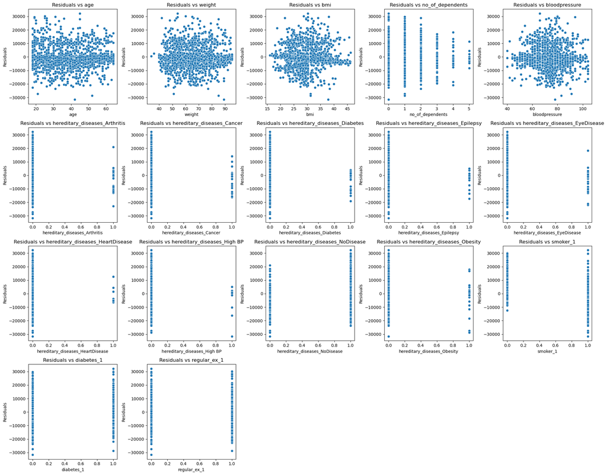

```python
import seaborn as sns
import matplotlib.pyplot as plt

# Determine the number of rows and columns for the subplot grid
n_plots = len(X_train_significant.columns) - 1  # Excluding intercept
n_cols = 5  # Number of columns in the grid
n_rows = (n_plots // n_cols) + int(n_plots % n_cols > 0)  # Number of rows

# Create a subplot grid with the calculated number of rows and columns
fig, ax = plt.subplots(nrows=n_rows, ncols=n_cols, figsize=(20, n_rows * 4))

# Flatten the axes array for easy iteration
ax = ax.flatten()

# Create scatter plots for residuals vs. each independent variable
for variable, subplot in zip(X_train_significant.columns[1:], ax):
    sns.scatterplot(x=X_train_significant[variable], y=linreg_model_with_significant_var.resid, ax=subplot)
    subplot.set_title(f'Residuals vs {variable}')
    subplot.set_xlabel(variable)
    subplot.set_ylabel('Residuals')

# Hide any unused subplots
for i in range(n_plots, len(ax)):
    fig.delaxes(ax[i])

# Adjust layout and display the plots
plt.tight_layout()
plt.show()
```

|  | **From the plots we see that none of the plots show a specific pattern. Hence, we may conclude that the variables are linearly related to the dependent variable.** |
| --- | --- |

### 5.3.2.4 Normality of Residuals

The assumption of normality is an important assumption for many statistical tests. The normal Q-Q plot is one way to assess normality. This q-q or quantile-quantile is a scatter plot which helps us validate the assumption of normal distribution in a data set.

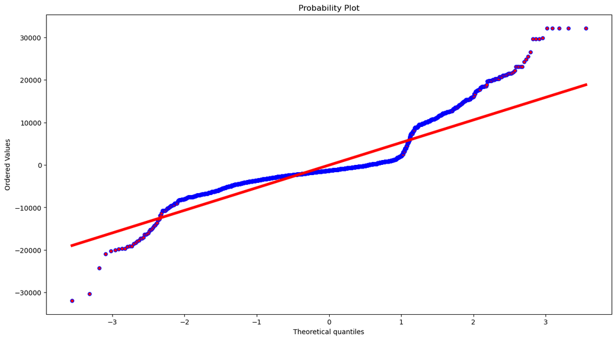

```python
# calculate fitted values
fitted_vals = linreg_model_with_significant_var.predict(X_test_significant)

# calculate residuals
resids = actual_claim - fitted_vals

# create subplots using subplots() such that there is one row having one plot
# 'figsize' sets the figure size
fig, ax = plt.subplots(1, 1, figsize=(15, 8))

# plot the probability plot to check the normality of the residuals
# plot: if specified plots the least squares fit
stats.probplot(resids, plot=plt)

# set the marker type using the set_marker() parameter
# access the line object from the axes object using ax.get_lines()
# then, the properties can be changed accordingly
# set the marker to 'o' to use circles as points
ax.get_lines()[0].set_marker('o')

# set the marker size using the set_markersize() parameter
# set the marker size to 5
ax.get_lines()[0].set_markersize(5.0)

# set the color of the trend line using set_markerfacecolor()
# set color of the trend line to red by passing 'r' to the set_markerfacecolor
ax.get_lines()[0].set_markerfacecolor('r')

# set the trend line width
ax.get_lines()[1].set_linewidth(4.0)

# display the plot
plt.show()
```

|  | **Using this plot, we can infer that the residuals do not come from a normal distribution. This is possible since our target variable is not normally distributed.** |
| --- | --- |

**The mean of the residuals always equals zero (assuming that your line is actually the line of “best fit”)**

```python
# check the mean of the residual
linreg_model_with_significant_var.resid.mean()
```

```
-6.960986799151758e-12
```

The mean of the residuals is very much closer to zero. Therefore, we can say that linearity is present.

**Perform Jarque Bera test to check normality of the residuals**

```python
# normality test using 'jarque_bera'
# the test returns the the test statistics and the p-value of the test
stat, p = jarque_bera(resids)

# to print the numeric outputs of the Jarque-Bera test upto 3 decimal places
# %.3f: returns the a floating point with 3 decimal digit accuracy
# the '%' holds the place where the number is to be printed
print('Statistics=%.3f, p-value=%.3f' % (stat, p))

# display the conclusion
# set the level of significance to 0.05
alpha = 0.05

# if the p-value is greater than alpha print we accept alpha
# if the p-value is less than alpha print we reject alpha
if p > alpha:
    print('The data is normally distributed (fail to reject H0)')
else:
    print('The data is not normally distributed (reject H0)')
```

```
Statistics=4744.770, p-value=0.000
The data is not normally distributed (reject H0)
```

|  | **It is apparent that the p-value is less than 0.05. So we have enough evidence to reject the null hypothesis. It can be concluded that the residuals is not normally distributed.** |
| --- | --- |

### 5.3.3 Linear Regression after Removing Insignificant Variable (OLS) - Scaled Data

Standardization refers to shifting the distribution of each attribute to have a mean of zero and a standard deviation of one (unit variance). It is useful to standardize attributes for a model that relies on the distribution of attributes such as Gaussian processes.  
Standardization of a dataset is a common requirement for many machine learning estimators: they might behave badly if the individual features do not more or less look like standard normally distributed data (e.g. Gaussian with 0 mean and unit variance).

Let's build a model on significant variables using standardization.

[figure not shown]

To build the linear regression model after removing insignificant variable on standardized data, we do the following:  
1. Perform standardization on data  
2. Split the data into training and test sets  
3. Consider only the significant variables  
4. Build model using sm.OLS().fit()  
5. Predict the values using test set  
6. Compute accuracy measures  
7. Tabulate the results

**1. Perform standardization on train data**

```python
# scale the numeric variables
# apply(): applies the operaction passed to each feature in 'df_numeric_features'
# lambda(): lambda functions are anonymous, i.e. to say they have no names
# the lambda function scales the data
df_num_scaled = df_numeric_features.apply(lambda rec: (rec - rec.mean()) / rec.std())

# create a dataframe
# axis=1: specifies that the concatenation is column wise
df_insurance_scaled = pd.concat([df_num_scaled, df_categoric_features], axis = 1)

# add constant to the data
df_insurance_scaled =sm.add_constant(df_insurance_scaled)
```

```python
# on doing the predictions to compute RMSE the we need to unscale the predictions
# so we store the original mean and standard deviation of the data
# store the mean as 'mean_numeric_features'
mean_numeric_features = df_numeric_features.mean()

# store the standard deviation as 'std_numeric_features'
std_numeric_features = df_numeric_features.std()
```

**2. Split the data into training and test sets**

```python
# separate the independent and dependent variables
# drop(): specify the variables to be dropped
# axis=1: specifies that the columns are to be dropped
X = df_insurance_scaled.drop(['claim','log_claim'], axis=1)

# extract the target variable from the train set
y = df_insurance_scaled['claim']

# Convert boolean columns to integers
X = X.applymap(lambda x: 1 if x is True else (0 if x is False else x))

# split data into train subset and test subset for predictor and target variables
# random_state: the seed used by the random number generator
X_train_scaled, X_test_scaled, y_train_scaled, y_test_scaled = train_test_split(X, y, random_state=1)

# check the dimensions of the train & test subset for

# print dimension of predictors train set
print("The shape of X_train_scaled is:",X_train_scaled.shape)

# print dimension of predictors test set
print("The shape of X_test_scaled is:",X_test_scaled.shape)

# print dimension of target train set
print("The shape of y_train_scaled is:",y_train_scaled.shape)

# print dimension of target test set
print("The shape of y_test_scaled is:",y_test_scaled.shape)
```

```
The shape of X_train_scaled is: (11042, 56)
The shape of X_test_scaled is: (3681, 56)
The shape of y_train_scaled is: (11042,)
The shape of y_test_scaled is: (3681,)
```

**3. Consider only the significant variables**

```python
# consider the significant variable in the training set
# drop(): specify the variables to be dropped
# axis=1: specifies that the columns are to be dropped
X_train_scaled_significant = X_train_scaled.drop(insigni_var, axis=1)

# consider the significant variable in the training set
# drop(): specify the variables to be dropped
# axis=1: specifies that the columns are to be dropped
X_test_scaled_significant = X_test_scaled.drop(insigni_var, axis=1)
```

**4. Build model using sm.OLS().fit()**

```python
# ordinary least squares regression
# build a full model with significant scaled variables using OLS()
linreg_model_with_significant_scaled_vars = sm.OLS(y_train_scaled,X_train_scaled_significant).fit()

# to print the summary output
print(linreg_model_with_significant_scaled_vars.summary())
```

```
                            OLS Regression Results
==============================================================================
Dep. Variable:                  claim   R-squared:                       0.764
Model:                            OLS   Adj. R-squared:                  0.764
Method:                 Least Squares   F-statistic:                     1551.
Date:                Thu, 12 Sep 2024   Prob (F-statistic):               0.00
Time:                        08:03:01   Log-Likelihood:                -7772.7
No. Observations:               11042   AIC:                         1.559e+04
Df Residuals:                   11018   BIC:                         1.577e+04
Df Model:                          23
Covariance Type:            nonrobust
====================================================================================================
                                       coef    std err          t      P>|t|      [0.025      0.975]
----------------------------------------------------------------------------------------------------
const                                0.4822      0.030     15.913      0.000       0.423       0.542
age                                  0.3036      0.005     58.372      0.000       0.293       0.314
weight                              -0.0451      0.005     -8.888      0.000      -0.055      -0.035
bmi                                  0.1046      0.005     21.050      0.000       0.095       0.114
no_of_dependents                     0.0498      0.005     10.541      0.000       0.041       0.059
bloodpressure                        0.0249      0.005      5.281      0.000       0.016       0.034
hereditary_diseases_Arthritis       -0.1796      0.060     -2.984      0.003      -0.298      -0.062
hereditary_diseases_Diabetes        -0.1672      0.056     -2.987      0.003      -0.277      -0.057
hereditary_diseases_EyeDisease      -0.1841      0.060     -3.079      0.002      -0.301      -0.067
hereditary_diseases_HeartDisease     0.3539      0.066      5.386      0.000       0.225       0.483
hereditary_diseases_High BP         -0.2032      0.075     -2.725      0.006      -0.349      -0.057
hereditary_diseases_NoDisease       -0.9609      0.028    -34.058      0.000      -1.016      -0.906
smoker_1                             1.6618      0.013    124.105      0.000       1.636       1.688
diabetes_1                           0.1030      0.011      9.062      0.000       0.081       0.125
regular_ex_1                        -0.0740      0.011     -6.508      0.000      -0.096      -0.052
job_title_Analyst                   -0.1408      0.035     -3.969      0.000      -0.210      -0.071
job_title_DataScientist              0.0885      0.032      2.792      0.005       0.026       0.151
job_title_Doctor                     0.0953      0.034      2.837      0.005       0.029       0.161
job_title_Engineer                   0.1386      0.030      4.588      0.000       0.079       0.198
job_title_Manager                    0.1140      0.024      4.727      0.000       0.067       0.161
job_title_Photographer               0.1987      0.030      6.733      0.000       0.141       0.257
job_title_Politician                 0.1590      0.031      5.198      0.000       0.099       0.219
job_title_Singer                     0.0601      0.022      2.740      0.006       0.017       0.103
job_title_Student                    0.0692      0.018      3.900      0.000       0.034       0.104
==============================================================================
Omnibus:                     3109.172   Durbin-Watson:                   1.982
Prob(Omnibus):                  0.000   Jarque-Bera (JB):            10147.511
Skew:                           1.425   Prob(JB):                         0.00
Kurtosis:                       6.733   Cond. No.                         30.4
==============================================================================

Notes:
[1] Standard Errors assume that the covariance matrix of the errors is correctly specified.
```

[output not shown]

**5. Predict the values using test set**

```python
# predict the 'claim' using predict()
predicted_claim = linreg_model_with_significant_scaled_vars.predict(X_test_scaled_significant)

# unscale the data
y_pred_unscaled = (predicted_claim * std_numeric_features.claim) + mean_numeric_features.claim

# extract the 'claim' values from the test data
actual_claim = y_test['claim']
```

**6. Compute model accuracy measures**

Now we calculate accuray measures like Root-mean-square-error (RMSE), R-squared and Adjusted R-squared.

```python
# calculate rmse using rmse()
linreg_model_with_significant_scaled_vars_rmse = rmse(actual_claim, y_pred_unscaled)

# calculate R-squared using rsquared
linreg_model_with_significant_scaled_vars_rsquared = linreg_model_with_significant_scaled_vars.rsquared

# calculate Adjusted R-Squared using rsquared_adj
linreg_model_with_significant_scaled_vars_rsquared_adj = linreg_model_with_significant_scaled_vars.rsquared_adj
```

**7. Tabulate the results**

```python
# compile the required information
linreg_model_with_significant_scaled_vars_metrics = pd.DataFrame([{
                     'Model_Name': "Linreg with scaled significant variables",
                     'RMSE': linreg_model_with_significant_scaled_vars_rmse,
                     'R-Squared': linreg_model_with_significant_scaled_vars_rsquared,
                     'Adj. R-Squared': linreg_model_with_significant_scaled_vars_rsquared_adj
                   }])

# append our result table using append()
# ignore_index=True: does not use the index labels
# python can only append a Series if ignore_index=True or if the Series has a name
score_card = pd.concat([score_card,linreg_model_with_significant_scaled_vars_metrics], ignore_index = True)

# print the result table
score_card
```

|  | Model_Name | R-Squared | Adj. R-Squared | RMSE |
| --- | --- | --- | --- | --- |
| 0 | Linreg full model with log of target variable | 0.745162 | 0.743886 | 7947.405055 |
| 1 | Linreg full model without log of target variable | 0.765424 | 0.764249 | 5916.234909 |
| 2 | Linreg full model with significant variables | 0.760924 | 0.760555 | 5911.155096 |
| 3 | Linreg with scaled significant variables | 0.763999 | 0.763506 | 5923.418017 |

[output not shown]

### 5.3.4 Linear Regression with Interaction (OLS)

Let us now see the effect on the linear regression model on adding an interaction effect of two significant variables

An interaction effect occurs when the effect of one variable depends on another variable. This combined effect may or may not improve the performance of the model

Comparing the coefficient of determination with and without the interaction term:  
The model for which interaction term is considered, the coefficient of determination may vary. It is crucial to check for the significance of the interaction term. If the term is found to be significant then the coefficient of determination increases. If the term is not significant, there is not much change in the coefficient of determination. [Ref:https://bit.ly/2Nm0Wi7]

[figure not shown]

In order to build the model, we do the following:  
1. Compute the interaction effect  
2. Split the data into training and test sets  
3. Build model using sm.OLS().fit()  
4. Predict the values using test set  
5. Compute accuracy measures  
6. Tabulate the results

**1. Compute the interaction effect**

```python
# create a copy of the entire dataset to add the interaction effect using copy()
df_insurance_interaction = df_insurance_dummy.copy()

# add the interaction variable
df_insurance_interaction['bmi*smoker'] = df_insurance_interaction['bmi']*df_insurance_interaction['smoker_1']

# print the data with interaction
df_insurance_interaction.head()
```

|  | const | age | weight | bmi | no_of_dependents | bloodpressure | claim | log_claim | sex_male | hereditary_diseases_Arthritis | hereditary_diseases_Cancer | hereditary_diseases_Diabetes | hereditary_diseases_Epilepsy | hereditary_diseases_EyeDisease | hereditary_diseases_HeartDisease | hereditary_diseases_High BP | hereditary_diseases_NoDisease | hereditary_diseases_Obesity | smoker_1 | diabetes_1 | regular_ex_1 | job_title_Accountant | job_title_Actor | job_title_Analyst | job_title_Architect | job_title_Beautician | job_title_Blogger | job_title_Buisnessman | job_title_CA | … |
| --- | --- | --- | --- | --- | --- | --- | --- | --- | --- | --- | --- | --- | --- | --- | --- | --- | --- | --- | --- | --- | --- | --- | --- | --- | --- | --- | --- | --- | --- | --- |
| 0 | 1.000000 | 60.000000 | 64 | 24.300000 | 1 | 72 | 13112.600000 | 9.481329 | True | False | False | False | False | False | False | False | True | False | False | False | False | False | True | False | False | False | False | False | False | … |
| 1 | 1.000000 | 49.000000 | 75 | 22.600000 | 1 | 78 | 9567.000000 | 9.166075 | False | False | False | False | False | False | False | False | True | False | False | True | True | False | False | False | False | False | False | False | False | … |
| 2 | 1.000000 | 32.000000 | 64 | 17.800000 | 2 | 88 | 32734.200000 | 10.396176 | False | False | False | False | True | False | False | False | False | False | True | True | True | False | False | False | False | False | False | False | False | … |
| 3 | 1.000000 | 61.000000 | 53 | 36.400000 | 1 | 72 | 48517.600000 | 10.789682 | False | False | False | False | False | False | False | False | True | False | True | True | False | False | False | False | False | False | False | False | False | … |
| 4 | 1.000000 | 19.000000 | 50 | 20.600000 | 0 | 82 | 1731.700000 | 7.456859 | False | False | False | False | False | False | False | False | True | False | False | True | False | False | False | False | False | False | False | False | False | … |

**2. Split the data into training and test sets**

Notice that there is a change in the data set. We have added a variable(bmi*smoker), we consider this data as our new data. We again spilt the data into a train and test set keeping the random_state as the same as before (please refer section 5.1 to confirm)

```python
# separate the independent and dependent variables
# drop(): specify the variables to be dropped
# axis=1: specifies that the columns are to be dropped
X = df_insurance_interaction.drop(['claim','log_claim'], axis=1)

# extract the target variable from the train set
y = df_insurance_interaction['claim']

# Convert boolean columns to integers
X = X.applymap(lambda x: 1 if x is True else (0 if x is False else x))

# split data into train subset and test subset for predictor and target variables
# random_state: the seed used by the random number generator
X_train_interaction, X_test_interaction, y_train, y_test = train_test_split( X, y, random_state=1)

# check the dimensions of the train & test subset for

# print dimension of predictors train set
print("The shape of X_train_interaction is:",X_train_interaction.shape)

# print dimension of predictors test set
print("The shape of X_test_interaction is:",X_test_interaction.shape)

# print dimension of target train set
print("The shape of y_train is:",y_train.shape)

# print dimension of target test set
print("The shape of y_test is:",y_test.shape)
```

```
The shape of X_train_interaction is: (11042, 57)
The shape of X_test_interaction is: (3681, 57)
The shape of y_train is: (11042,)
The shape of y_test is: (3681,)
```

**3. Build model using sm.OLS().fit()**

```python
# building a full model with an interaction term using OLS()
linreg_with_interaction = sm.OLS(y_train, X_train_interaction).fit()

# print the summary output
print(linreg_with_interaction.summary())
```

```
                            OLS Regression Results
==============================================================================
Dep. Variable:                  claim   R-squared:                       0.802
Model:                            OLS   Adj. R-squared:                  0.801
Method:                 Least Squares   F-statistic:                     796.1
Date:                Thu, 12 Sep 2024   Prob (F-statistic):               0.00
Time:                        08:03:05   Log-Likelihood:            -1.1055e+05
No. Observations:               11042   AIC:                         2.212e+05
Df Residuals:                   10985   BIC:                         2.216e+05
Df Model:                          56
Covariance Type:            nonrobust
====================================================================================================
                                       coef    std err          t      P>|t|      [0.025      0.975]
----------------------------------------------------------------------------------------------------
const                             6726.6333    831.125      8.093      0.000    5097.479    8355.787
age                                263.4499      4.196     62.788      0.000     255.225     271.675
weight                             -34.1458      4.212     -8.108      0.000     -42.401     -25.890
bmi                                 29.8457     10.705      2.788      0.005       8.862      50.830
no_of_dependents                   551.3404     43.294     12.735      0.000     466.477     636.204
bloodpressure                       18.8214      4.929      3.818      0.000       9.159      28.484
sex_male                          -300.3447    107.501     -2.794      0.005    -511.066     -89.623
hereditary_diseases_Arthritis    -1693.9668    797.386     -2.124      0.034   -3256.987    -130.946
hereditary_diseases_Cancer       -2827.9353    801.146     -3.530      0.000   -4398.326   -1257.544
hereditary_diseases_Diabetes     -4174.7282    753.924     -5.537      0.000   -5652.554   -2696.902
hereditary_diseases_Epilepsy       295.3568    885.755      0.333      0.739   -1440.882    2031.595
hereditary_diseases_EyeDisease   -7206.5123    804.363     -8.959      0.000   -8783.208   -5629.816
hereditary_diseases_HeartDisease  4103.5781    857.557      4.785      0.000    2422.612    5784.544
hereditary_diseases_High BP      -4886.9948    935.520     -5.224      0.000   -6720.781   -3053.208
hereditary_diseases_NoDisease    -1.022e+04    531.917    -19.205      0.000   -1.13e+04   -9172.933
hereditary_diseases_Obesity      -2386.5790    734.173     -3.251      0.001   -3825.691    -947.467
smoker_1                         -1.326e+04    748.696    -17.706      0.000   -1.47e+04   -1.18e+04
diabetes_1                        1100.6458    127.001      8.666      0.000     851.701    1349.590
regular_ex_1                      -559.5052    126.960     -4.407      0.000    -808.370    -310.641
job_title_Accountant                26.8939    490.395      0.055      0.956    -934.368     988.156
job_title_Actor                    429.4233    430.601      0.997      0.319    -414.631    1273.478
job_title_Analyst                -1142.9059    529.480     -2.159      0.031   -2180.782    -105.030
job_title_Architect                388.7433    498.168      0.780      0.435    -587.755    1365.242
job_title_Beautician               862.9595    492.026      1.754      0.079    -101.501    1827.420
job_title_Blogger                -1011.1029    525.702     -1.923      0.054   -2041.572      19.367
job_title_Buisnessman              184.2819    551.291      0.334      0.738    -896.347    1264.911
```

[output cut: 27 more lines]

```
region_North-East                 -133.3252    160.023     -0.833      0.405    -446.998     180.348
region_Southern                     -1.4238    152.465     -0.009      0.993    -300.283     297.436
region_West                       -128.9685    153.529     -0.840      0.401    -429.914     171.977
bmi*smoker                        1129.2709     24.940     45.280      0.000    1080.384    1178.158
==============================================================================
Omnibus:                     3654.556   Durbin-Watson:                   1.980
Prob(Omnibus):                  0.000   Jarque-Bera (JB):            18173.024
Skew:                           1.523   Prob(JB):                         0.00
Kurtosis:                       8.497   Cond. No.                     4.62e+03
==============================================================================

Notes:
[1] Standard Errors assume that the covariance matrix of the errors is correctly specified.
[2] The condition number is large, 4.62e+03. This might indicate that there are
strong multicollinearity or other numerical problems.
```

[figure not shown]

**This model explains 80.2% of the variation in dependent variable claim.The Durbin-Watson test statistics is 1.98 and indicates that the is no autocorrelation. The Condition Number is 4620 suggests that there is severe collinearity. The collinearity is likely to increase because of the interaction effect.**

**4. Predict the values using test set**

```python
# predict the 'claim' using predict()
predicted_claim = linreg_with_interaction.predict(X_test_interaction)

# extract the 'claim' values from the test data
actual_claim = y_test
```

**5. Compute model accuracy measures**

Now we calculate accuray measures like Root-mean-square-error (RMSE), R-squared and Adjusted R-squared.

```python
# calculate rmse using rmse()
linreg_with_interaction_rmse = rmse(actual_claim, predicted_claim)

# calculate R-squared using rsquared
linreg_with_interaction_rsquared = linreg_with_interaction.rsquared

# calculate Adjusted R-Squared using rsquared_adj
linreg_with_interaction_rsquared_adj = linreg_with_interaction.rsquared_adj
```

**6. Tabulate the results**

```python
# compile the required information
linreg_with_interaction_metrics = pd.DataFrame([{
                     'Model_Name': "linreg_with_interaction",
                     'RMSE': linreg_with_interaction_rmse,
                     'R-Squared': linreg_with_interaction_rsquared,
                     'Adj. R-Squared': linreg_with_interaction_rsquared_adj
                   }])

# append our result table using append()
# ignore_index=True: does not use the index labels
# python can only append a Series if ignore_index=True or if the Series has a name
score_card = pd.concat([score_card,linreg_with_interaction_metrics], ignore_index = True)

# print the result table
score_card
```

|  | Model_Name | R-Squared | Adj. R-Squared | RMSE |
| --- | --- | --- | --- | --- |
| 0 | Linreg full model with log of target variable | 0.745162 | 0.743886 | 7947.405055 |
| 1 | Linreg full model without log of target variable | 0.765424 | 0.764249 | 5916.234909 |
| 2 | Linreg full model with significant variables | 0.760924 | 0.760555 | 5911.155096 |
| 3 | Linreg with scaled significant variables | 0.763999 | 0.763506 | 5923.418017 |
| 4 | linreg_with_interaction | 0.802319 | 0.801311 | 5547.061558 |

[figure not shown]

**From the summary output, the interaction component has a p-value of 0 indicating it is highly significant. The R-squared and adjusted R-squared value have also significantly increased. This output justifies that addition of an interaction effect has positively contributed to the performance of the model.**

## 6. Regularization (OLS)

Overfitting occurs when an algorithm fits the data too well. Specifically, overfitting occurs if the algorithm shows low bias but high variance. It is often a result of an excessively complicated model. This can be prevented by fitting multiple models and using cross-validation to compare their predictive accuracies on test data.

Underfitting occurs when an algorithm cannot capture the underlying trend of the data. Intuitively, it occurs when the algorithm does not fit the data well enough. Specifically, it occurs if the model or algorithm shows low variance but high bias. It is often a result of an excessively simple model

One of the challenge in machine learning is that our algorithm must perform well on new, previously unseen data - not just those on which our model was trained. This ability to perform well on previously unobserved data is called generalization. Generalization error is defined as the expected value of the error on a new data. Regularization is any modification we make to a learning algorithm that is intended to reduce it generalization error but not its training error. (Ref. Deep Learning by Ian Goodfellow, Yoshua Bengio, Aaron Courville)

|  | **Now we will perform regularization to check whether this technique performs better than our linear regression models without regularization** |
| --- | --- |

### 6.1 Ridge Regression (OLS)

[output not shown]

[figure not shown]

Now we perform ridge regression. We start with our original data set gradually proceeding with our analysis  
In order to perform ridge regression, we do the following:  
1. Split the data in the form of train and test sets  
2. For different values of alpha create a tabular representation of parameter estimates and accuracy meterics  
3. Find the alpha for which RMSE is minimum  
4. Fit a ridge model by substituting the alpha value obtained in step 3  
5. Predict the values using test set  
6. Compute accuracy measures  
7. Tabulate the results

**1. Split the data in the form of train and test sets**

We shall use the scaled data. The train test split is alread conducted for the scaled data.

**2. For different values of alpha create a tabular representation of parameter estimates and accuracy metrics**

We first create a list of all the variable names and accuracy metrics whose values we want.

```python
# compile the column names of the output dataframe
# add the names of metrics used for comparing the models
# these metrics are used for both lasso and ridge regression

# create list of variable names
col = list(X_train_scaled.columns)

# add 'Sum of square of Residuals' to the list
col.append('ssr')

# add 'R squared' to the list
col.append('R squared')

# add 'Adj. R squared' to the list
col.append('Adj. R squared')

# add 'Root mean Squared Error' to the list
col.append('RMSE')
```

Fit a linear regression model by the OLS method.

```python
# build a OLS model using OLS()
ridge_regression = sm.OLS(y_train_scaled, X_train_scaled)

# the fitted ridge model
results_fu = ridge_regression.fit()
```

In a for loop we pass different values of alpha. We tabulate all beta coeffients.

```python
# create an empty list
frames = []

# a 'for' loop for values of alpha in a given range
# the loop prepares a table of regression coefficients for different values of alpha
# the values of alpha are given to be 0.0001, 0.1001, 0.2001, 0.3001, 0.4001, 0.5001 and 10.0001
for n in np.arange(0.0001,10.1, 0.1).tolist():

    # fit a rigde regression to the linear model built using OLS
    # L1_wt=0: conducts ridge regression
    # alpha: specifies the alpha value
    # start_params: starting values for patameters
    results_fr = ridge_regression.fit_regularized(L1_wt=0, alpha=n, start_params=results_fu.params)

    # fit the model
    # model: specifies the regression model
    # params: specifies the estimated parameters
    # normalized_cov_params: specifies the normalized covariance parameters
    results_fr_fit = sm.regression.linear_model.OLSResults(model=ridge_regression,
                                             params=results_fr.params,
                                             normalized_cov_params=ridge_regression.normalized_cov_params)

    # compute the rmse
    # calling the test data
    results_fr_fit_predictions = results_fr_fit.predict(X_test_scaled)

    # obtain the rmse
    results_fr_fit_rmse = rmse(y_test, results_fr_fit_predictions)

    # compile the necessary metrics used for comparing the models
    list_metric = [results_fr_fit.ssr, results_fr_fit.rsquared, results_fr_fit.rsquared_adj, results_fr_fit_rmse]

    # append the empty list
    frames.append(np.append(results_fr.params, list_metric))

    # converting the list to a dataframe.
    df_params = pd.DataFrame(frames, columns= col)

# add column names to the dataframe
df_params.index=np.arange(0.0001, 10.1, 0.1).tolist()

# add the first column name alpha to the data frame.
# this column will hold the regularization parameter value which can be anything from zero to any positive number
df_params.index.name = 'alpha*'

# display the output
df_params
```

| alpha* | const | age | weight | bmi | no_of_dependents | bloodpressure | sex_male | hereditary_diseases_Arthritis | hereditary_diseases_Cancer | hereditary_diseases_Diabetes | hereditary_diseases_Epilepsy | hereditary_diseases_EyeDisease | hereditary_diseases_HeartDisease | hereditary_diseases_High BP | hereditary_diseases_NoDisease | hereditary_diseases_Obesity | smoker_1 | diabetes_1 | regular_ex_1 | job_title_Accountant | job_title_Actor | job_title_Analyst | job_title_Architect | job_title_Beautician | job_title_Blogger | job_title_Buisnessman | job_title_CA | job_title_CEO | job_title_Chef | … |
| --- | --- | --- | --- | --- | --- | --- | --- | --- | --- | --- | --- | --- | --- | --- | --- | --- | --- | --- | --- | --- | --- | --- | --- | --- | --- | --- | --- | --- | --- | --- |
| 0.000100 | 0.453691 | 0.303877 | -0.045268 | 0.105915 | 0.049688 | 0.023233 | 0.000194 | -0.174963 | 0.071336 | -0.162878 | 0.020886 | -0.166377 | 0.387267 | -0.183630 | -0.943461 | -0.037706 | 1.655473 | 0.105394 | -0.077047 | 0.056689 | -0.017764 | -0.127385 | 0.070594 | 0.048385 | -0.070523 | -0.008739 | 0.028648 | 0.053458 | -0.057054 | … |
| 0.100100 | 0.076848 | 0.267600 | -0.033467 | 0.111478 | 0.046126 | 0.029756 | 0.040365 | 0.046425 | 0.060063 | 0.060489 | 0.046843 | 0.051955 | 0.067184 | 0.033617 | -0.451901 | 0.075452 | 1.097399 | 0.125285 | -0.063316 | 0.027333 | -0.002751 | -0.039903 | 0.025201 | 0.001809 | -0.032441 | 0.007167 | 0.001553 | 0.027009 | -0.024807 | … |
| 0.200100 | 0.042317 | 0.241811 | -0.023462 | 0.109792 | 0.043677 | 0.029798 | 0.043222 | 0.035067 | 0.041836 | 0.046066 | 0.032532 | 0.039086 | 0.043441 | 0.025085 | -0.334780 | 0.055081 | 0.811973 | 0.105874 | -0.051632 | 0.020767 | 0.002505 | -0.025585 | 0.017879 | 0.000376 | -0.022172 | 0.004638 | 0.000496 | 0.020427 | -0.016436 | … |
| 0.300100 | 0.028452 | 0.221560 | -0.015830 | 0.106149 | 0.041445 | 0.028770 | 0.040723 | 0.027925 | 0.032588 | 0.036986 | 0.025225 | 0.031244 | 0.032780 | 0.019982 | -0.267158 | 0.043576 | 0.644336 | 0.089959 | -0.043214 | 0.016641 | 0.003564 | -0.019029 | 0.013873 | -0.000041 | -0.017068 | 0.003400 | 0.000190 | 0.016380 | -0.012468 | … |
| 0.400100 | 0.021112 | 0.204930 | -0.010002 | 0.101923 | 0.039386 | 0.027451 | 0.037399 | 0.023142 | 0.026818 | 0.030878 | 0.020668 | 0.026035 | 0.026481 | 0.016613 | -0.222579 | 0.036110 | 0.534111 | 0.077900 | -0.037038 | 0.013858 | 0.003694 | -0.015167 | 0.011344 | -0.000192 | -0.013925 | 0.002684 | 0.000084 | 0.013678 | -0.010079 | … |
| 0.500100 | 0.016634 | 0.190903 | -0.005510 | 0.097630 | 0.037497 | 0.026088 | 0.034236 | 0.019732 | 0.022837 | 0.026503 | 0.017529 | 0.022326 | 0.022268 | 0.014224 | -0.190872 | 0.030855 | 0.456115 | 0.068636 | -0.032359 | 0.011863 | 0.003563 | -0.012603 | 0.009603 | -0.000248 | -0.011776 | 0.002221 | 0.000047 | 0.011751 | -0.008468 | … |
| 0.600100 | 0.013648 | 0.178849 | -0.002011 | 0.093476 | 0.035767 | 0.024772 | 0.031436 | 0.017183 | 0.019911 | 0.023216 | 0.015228 | 0.019550 | 0.019236 | 0.012440 | -0.167131 | 0.026950 | 0.398011 | 0.061342 | -0.028707 | 0.010364 | 0.003359 | -0.010773 | 0.008332 | -0.000264 | -0.010209 | 0.001898 | 0.000036 | 0.010309 | -0.007303 | … |
| 0.700100 | 0.011531 | 0.168344 | 0.000739 | 0.089542 | 0.034183 | 0.023536 | 0.029006 | 0.015208 | 0.017665 | 0.020658 | 0.013465 | 0.017394 | 0.016942 | 0.011057 | -0.148675 | 0.023930 | 0.353048 | 0.055465 | -0.025783 | 0.009198 | 0.003144 | -0.009401 | 0.007362 | -0.000263 | -0.009013 | 0.001660 | 0.000037 | 0.009188 | -0.006422 | … |
| 0.800100 | 0.009960 | 0.159085 | 0.002917 | 0.085854 | 0.032729 | 0.022390 | 0.026903 | 0.013634 | 0.015884 | 0.018609 | 0.012071 | 0.015669 | 0.015144 | 0.009953 | -0.133908 | 0.021524 | 0.317219 | 0.050632 | -0.023393 | 0.008265 | 0.002939 | -0.008334 | 0.006597 | -0.000254 | -0.008069 | 0.001478 | 0.000041 | 0.008292 | -0.005730 | … |
| 0.900100 | 0.008754 | 0.150850 | 0.004653 | 0.082413 | 0.031393 | 0.021332 | 0.025075 | 0.012351 | 0.014435 | 0.016932 | 0.010940 | 0.014258 | 0.013696 | 0.009051 | -0.121821 | 0.019561 | 0.287997 | 0.046589 | -0.021405 | 0.007502 | 0.002750 | -0.007480 | 0.005979 | -0.000242 | -0.007305 | 0.001333 | 0.000047 | 0.007559 | -0.005173 | … |
| 1.000100 | 0.007801 | 0.143469 | 0.006044 | 0.079207 | 0.030161 | 0.020358 | 0.023477 | 0.011286 | 0.013233 | 0.015534 | 0.010004 | 0.013081 | 0.012502 | 0.008300 | -0.111742 | 0.017929 | 0.263709 | 0.043157 | -0.019724 | 0.006867 | 0.002580 | -0.006783 | 0.005469 | -0.000228 | -0.006674 | 0.001216 | 0.000053 | 0.006948 | -0.004715 | … |
| 1.100100 | 0.007031 | 0.136808 | 0.007161 | 0.076221 | 0.029022 | 0.019461 | 0.022071 | 0.010387 | 0.012218 | 0.014350 | 0.009216 | 0.012085 | 0.011502 | 0.007665 | -0.103208 | 0.016549 | 0.243201 | 0.040206 | -0.018287 | 0.006330 | 0.002426 | -0.006202 | 0.005040 | -0.000214 | -0.006143 | 0.001119 | 0.000059 | 0.006431 | -0.004331 | … |
| 1.200100 | 0.006398 | 0.130764 | 0.008060 | 0.073438 | 0.027965 | 0.018633 | 0.020825 | 0.009620 | 0.011351 | 0.013334 | 0.008543 | 0.011231 | 0.010652 | 0.007121 | -0.095887 | 0.015368 | 0.225655 | 0.037641 | -0.017043 | 0.005870 | 0.002288 | -0.005711 | 0.004675 | -0.000201 | -0.005691 | 0.001037 | 0.000064 | 0.005987 | -0.004005 | … |
| 1.300100 | 0.005868 | 0.125251 | 0.008784 | 0.070842 | 0.026983 | 0.017869 | 0.019715 | 0.008956 | 0.010600 | 0.012454 | 0.007962 | 0.010491 | 0.009919 | 0.006649 | -0.089538 | 0.014346 | 0.210472 | 0.035391 | -0.015957 | 0.005472 | 0.002164 | -0.005290 | 0.004361 | -0.000188 | -0.005300 | 0.000968 | 0.000068 | 0.005602 | -0.003724 | … |
| 1.400100 | 0.005420 | 0.120199 | 0.009367 | 0.068415 | 0.026068 | 0.017162 | 0.018720 | 0.008377 | 0.009944 | 0.011683 | 0.007456 | 0.009842 | 0.009281 | 0.006236 | -0.083979 | 0.013451 | 0.197204 | 0.033401 | -0.015000 | 0.005124 | 0.002051 | -0.004927 | 0.004086 | -0.000177 | -0.004960 | 0.000907 | 0.000072 | 0.005264 | -0.003480 | … |
| 1.500100 | 0.005035 | 0.115552 | 0.009833 | 0.066144 | 0.025213 | 0.016506 | 0.017822 | 0.007868 | 0.009365 | 0.011002 | 0.007010 | 0.009270 | 0.008721 | 0.005872 | -0.079070 | 0.012662 | 0.185512 | 0.031627 | -0.014150 | 0.004818 | 0.001950 | -0.004609 | 0.003845 | -0.000166 | -0.004661 | 0.000854 | 0.000075 | 0.004966 | -0.003266 | … |
| 1.600100 | 0.004702 | 0.111260 | 0.010204 | 0.064015 | 0.024413 | 0.015897 | 0.017008 | 0.007416 | 0.008851 | 0.010397 | 0.006614 | 0.008760 | 0.008225 | 0.005548 | -0.074704 | 0.011961 | 0.175129 | 0.030037 | -0.013391 | 0.004545 | 0.001857 | -0.004329 | 0.003631 | -0.000156 | -0.004396 | 0.000807 | 0.000078 | 0.004700 | -0.003077 | … |
| 1.700100 | 0.004411 | 0.107284 | 0.010498 | 0.062016 | 0.023662 | 0.015330 | 0.016268 | 0.007013 | 0.008390 | 0.009855 | 0.006261 | 0.008304 | 0.007783 | 0.005259 | -0.070795 | 0.011334 | 0.165848 | 0.028602 | -0.012709 | 0.004302 | 0.001772 | -0.004081 | 0.003441 | -0.000147 | -0.004159 | 0.000766 | 0.000080 | 0.004462 | -0.002909 | … |
| 1.800100 | 0.004154 | 0.103589 | 0.010726 | 0.060136 | 0.022956 | 0.014801 | 0.015590 | 0.006651 | 0.007976 | 0.009367 | 0.005944 | 0.007894 | 0.007386 | 0.004998 | -0.067275 | 0.010770 | 0.157501 | 0.027301 | -0.012093 | 0.004083 | 0.001695 | -0.003859 | 0.003269 | -0.000139 | -0.003947 | 0.000729 | 0.000082 | 0.004248 | -0.002757 | … |
| 1.900100 | 0.003926 | 0.100146 | 0.010901 | 0.058365 | 0.022291 | 0.014306 | 0.014969 | 0.006324 | 0.007602 | 0.008925 | 0.005657 | 0.007522 | 0.007027 | 0.004762 | -0.064088 | 0.010259 | 0.149955 | 0.026115 | -0.011533 | 0.003885 | 0.001624 | -0.003659 | 0.003114 | -0.000131 | -0.003755 | 0.000695 | 0.000083 | 0.004053 | -0.002621 | … |
| 2.000100 | 0.003723 | 0.096928 | 0.011030 | 0.056693 | 0.021664 | 0.013842 | 0.014396 | 0.006027 | 0.007261 | 0.008523 | 0.005397 | 0.007183 | 0.006702 | 0.004547 | -0.061189 | 0.009795 | 0.143099 | 0.025030 | -0.011023 | 0.003706 | 0.001558 | -0.003479 | 0.002974 | -0.000124 | -0.003581 | 0.000665 | 0.000084 | 0.003876 | -0.002498 | … |
| 2.100100 | 0.003541 | 0.093916 | 0.011123 | 0.055114 | 0.021071 | 0.013407 | 0.013867 | 0.005757 | 0.006950 | 0.008156 | 0.005159 | 0.006874 | 0.006406 | 0.004351 | -0.058541 | 0.009371 | 0.136844 | 0.024034 | -0.010556 | 0.003542 | 0.001498 | -0.003316 | 0.002845 | -0.000117 | -0.003423 | 0.000637 | 0.000085 | 0.003714 | -0.002386 | … |
| 2.200100 | 0.003376 | 0.091088 | 0.011183 | 0.053620 | 0.020510 | 0.012998 | 0.013376 | 0.005510 | 0.006664 | 0.007819 | 0.004942 | 0.006591 | 0.006135 | 0.004171 | -0.056112 | 0.008983 | 0.131112 | 0.023115 | -0.010126 | 0.003392 | 0.001442 | -0.003167 | 0.002728 | -0.000111 | -0.003278 | 0.000612 | 0.000086 | 0.003566 | -0.002283 | … |
| 2.300100 | 0.003226 | 0.088428 | 0.011217 | 0.052203 | 0.019978 | 0.012613 | 0.012920 | 0.005283 | 0.006401 | 0.007509 | 0.004742 | 0.006330 | 0.005886 | 0.004006 | -0.053877 | 0.008625 | 0.125842 | 0.022266 | -0.009730 | 0.003254 | 0.001390 | -0.003030 | 0.002620 | -0.000105 | -0.003144 | 0.000588 | 0.000086 | 0.003429 | -0.002189 | … |
| 2.400100 | 0.003089 | 0.085921 | 0.011229 | 0.050859 | 0.019473 | 0.012250 | 0.012494 | 0.005074 | 0.006159 | 0.007223 | 0.004558 | 0.006089 | 0.005657 | 0.003853 | -0.051813 | 0.008295 | 0.120979 | 0.021477 | -0.009363 | 0.003126 | 0.001341 | -0.002905 | 0.002520 | -0.000100 | -0.003021 | 0.000567 | 0.000086 | 0.003302 | -0.002102 | … |
| 2.500100 | 0.002964 | 0.083555 | 0.011223 | 0.049582 | 0.018993 | 0.011907 | 0.012097 | 0.004880 | 0.005934 | 0.006958 | 0.004388 | 0.005866 | 0.005445 | 0.003712 | -0.049901 | 0.007990 | 0.116479 | 0.020744 | -0.009023 | 0.003009 | 0.001296 | -0.002789 | 0.002428 | -0.000095 | -0.002907 | 0.000547 | 0.000086 | 0.003185 | -0.002022 | … |
| 2.600100 | 0.002850 | 0.081318 | 0.011200 | 0.048368 | 0.018536 | 0.011582 | 0.011724 | 0.004701 | 0.005725 | 0.006712 | 0.004230 | 0.005658 | 0.005248 | 0.003580 | -0.048124 | 0.007706 | 0.112301 | 0.020060 | -0.008707 | 0.002900 | 0.001254 | -0.002682 | 0.002342 | -0.000091 | -0.002802 | 0.000528 | 0.000086 | 0.003075 | -0.001948 | … |
| 2.700100 | 0.002744 | 0.079199 | 0.011165 | 0.047211 | 0.018101 | 0.011274 | 0.011375 | 0.004534 | 0.005531 | 0.006483 | 0.004082 | 0.005465 | 0.005065 | 0.003458 | -0.046470 | 0.007442 | 0.108413 | 0.019420 | -0.008412 | 0.002798 | 0.001214 | -0.002583 | 0.002263 | -0.000087 | -0.002704 | 0.000511 | 0.000086 | 0.002973 | -0.001879 | … |
| 2.800100 | 0.002646 | 0.077188 | 0.011118 | 0.046108 | 0.017686 | 0.010982 | 0.011046 | 0.004379 | 0.005349 | 0.006268 | 0.003945 | 0.005285 | 0.004895 | 0.003344 | -0.044926 | 0.007195 | 0.104785 | 0.018821 | -0.008137 | 0.002703 | 0.001177 | -0.002491 | 0.002188 | -0.000083 | -0.002612 | 0.000495 | 0.000086 | 0.002878 | -0.001814 | … |
| 2.900100 | 0.002555 | 0.075279 | 0.011062 | 0.045055 | 0.017289 | 0.010705 | 0.010736 | 0.004233 | 0.005179 | 0.006068 | 0.003817 | 0.005116 | 0.004735 | 0.003237 | -0.043480 | 0.006964 | 0.101393 | 0.018258 | -0.007878 | 0.002615 | 0.001142 | -0.002406 | 0.002119 | -0.000079 | -0.002527 | 0.000480 | 0.000086 | 0.002789 | -0.001754 | … |

[output cut: 71 more lines]

Let us compare the results for low and high values of alpha

```python
# call the first two rows and last two rows
df_params.iloc[[0,1,-2,-1]]
```

| alpha* | const | age | weight | bmi | no_of_dependents | bloodpressure | sex_male | hereditary_diseases_Arthritis | hereditary_diseases_Cancer | hereditary_diseases_Diabetes | hereditary_diseases_Epilepsy | hereditary_diseases_EyeDisease | hereditary_diseases_HeartDisease | hereditary_diseases_High BP | hereditary_diseases_NoDisease | hereditary_diseases_Obesity | smoker_1 | diabetes_1 | regular_ex_1 | job_title_Accountant | job_title_Actor | job_title_Analyst | job_title_Architect | job_title_Beautician | job_title_Blogger | job_title_Buisnessman | job_title_CA | job_title_CEO | job_title_Chef | … |
| --- | --- | --- | --- | --- | --- | --- | --- | --- | --- | --- | --- | --- | --- | --- | --- | --- | --- | --- | --- | --- | --- | --- | --- | --- | --- | --- | --- | --- | --- | --- |
| 0.000100 | 0.453691 | 0.303877 | -0.045268 | 0.105915 | 0.049688 | 0.023233 | 0.000194 | -0.174963 | 0.071336 | -0.162878 | 0.020886 | -0.166377 | 0.387267 | -0.183630 | -0.943461 | -0.037706 | 1.655473 | 0.105394 | -0.077047 | 0.056689 | -0.017764 | -0.127385 | 0.070594 | 0.048385 | -0.070523 | -0.008739 | 0.028648 | 0.053458 | -0.057054 | … |
| 0.100100 | 0.076848 | 0.267600 | -0.033467 | 0.111478 | 0.046126 | 0.029756 | 0.040365 | 0.046425 | 0.060063 | 0.060489 | 0.046843 | 0.051955 | 0.067184 | 0.033617 | -0.451901 | 0.075452 | 1.097399 | 0.125285 | -0.063316 | 0.027333 | -0.002751 | -0.039903 | 0.025201 | 0.001809 | -0.032441 | 0.007167 | 0.001553 | 0.027009 | -0.024807 | … |
| 9.900100 | 0.000795 | 0.027692 | 0.006035 | 0.017323 | 0.006736 | 0.003853 | 0.003673 | 0.001269 | 0.001613 | 0.001877 | 0.001165 | 0.001583 | 0.001446 | 0.001001 | -0.013343 | 0.002150 | 0.031056 | 0.005967 | -0.002436 | 0.000791 | 0.000370 | -0.000698 | 0.000663 | -0.000013 | -0.000767 | 0.000157 | 0.000048 | 0.000888 | -0.000528 | … |
| 10.000100 | 0.000787 | 0.027444 | 0.005991 | 0.017172 | 0.006678 | 0.003818 | 0.003639 | 0.001256 | 0.001598 | 0.001859 | 0.001154 | 0.001568 | 0.001432 | 0.000992 | -0.013212 | 0.002129 | 0.030752 | 0.005911 | -0.002412 | 0.000784 | 0.000366 | -0.000691 | 0.000657 | -0.000013 | -0.000759 | 0.000156 | 0.000048 | 0.000880 | -0.000523 | … |

[figure not shown]

**The sum of squares of residual, increases with increase in alpha, this reduces model complexity. Compare the coefficients in the first and second row of this table, there is a drastic change in the magnitude of coefficients. Similar change is seen on comparing rows 2 and 3. However, there is not much change in rows 3 and 4. High alpha values can lead to significant underfitting. Note the rapid increase in residual sum of squares.**

**3. Find the alpha for which RMSE is minimum**

Now, to know which model performs the best, we find the alpha value which has lowest root mean squared error.

```python
# find the alpha value for which RMSE is minimum
# from the column EMSE of df_params obtain the minimum value of RMSE
# .index.tolist(): gets the corresponding index value, i.e. the alpha value
alpha = df_params.RMSE[df_params.RMSE == df_params.loc[:,'RMSE'].min()].index.tolist()

# print the conclusion
print('The required alpha is %.4f ' % (alpha[0]))
```

```
The required alpha is 0.0001
```

Thus, we may say the model obtained by alpha = 0.0001 is performing the best since has the lowest root mean squared error.

**In ridge regression, coefficients may tend to zero yet are never zero. This can be checked by the follwing code**

```python
# check for zeros in the above coefficients table
# axis=1: specifies that the apply() is to be applies column wise
df_params.apply(lambda x: sum(x.values==0),axis=1)
```

```
alpha*
0.000100     0
0.100100     0
0.200100     0
0.300100     0
0.400100     0
0.500100     0
0.600100     0
0.700100     0
0.800100     0
0.900100     0
1.000100     0
1.100100     0
1.200100     0
1.300100     0
1.400100     0
1.500100     0
1.600100     0
1.700100     0
1.800100     0
1.900100     0
2.000100     0
2.100100     0
2.200100     0
2.300100     0
2.400100     0
2.500100     0
2.600100     0
2.700100     0
2.800100     0
2.900100     0
3.000100     0
3.100100     0
3.200100     0
3.300100     0
3.400100     0
3.500100     0
3.600100     0
3.700100     0
3.800100     0
```

[output cut: 48 more lines]

```
8.700100     0
8.800100     0
8.900100     0
9.000100     0
9.100100     0
9.200100     0
9.300100     0
9.400100     0
9.500100     0
9.600100     0
9.700100     0
9.800100     0
9.900100     0
10.000100    0
dtype: int32
```

For all alpha values, the corresponding value is zero which impiles there are **no** coefficients with value zero.

**4. Fit a ridge model by substituting the alpha value obtained in step 3**

We know that when aplha = 0.0001, the model performs better than other since it has the lowest RMSE and highest adjusted R- squared value. Let us now find its summary output.

```python
# build a ridge model for the desired alpha
# L1_wt=0: conducts ridge regression
# alpha: specifies the alpha value
# start_params: starting values for patameters
results_fr = ridge_regression.fit_regularized(L1_wt=0, alpha=0.0001, start_params=results_fu.params)

# fit the model
# model: specifies the regression model
# params: specifies the estimated parameters
# normalized_cov_params: specifies the normalized covariance parameters
ridge_regression_best = sm.regression.linear_model.OLSResults(model = ridge_regression,
                                        params=results_fr.params,
                                        normalized_cov_params=ridge_regression.normalized_cov_params)

# print the summary output
print (ridge_regression_best.summary())
```

```
                            OLS Regression Results
==============================================================================
Dep. Variable:                  claim   R-squared:                       0.765
Model:                            OLS   Adj. R-squared:                  0.764
Method:                 Least Squares   F-statistic:                     651.8
Date:                Thu, 12 Sep 2024   Prob (F-statistic):               0.00
Time:                        08:03:14   Log-Likelihood:                -7739.4
No. Observations:               11042   AIC:                         1.559e+04
Df Residuals:                   10986   BIC:                         1.600e+04
Df Model:                          55
Covariance Type:            nonrobust
====================================================================================================
                                       coef    std err          t      P>|t|      [0.025      0.975]
----------------------------------------------------------------------------------------------------
const                                0.4537      0.060      7.609      0.000       0.337       0.571
age                                  0.3039      0.005     57.713      0.000       0.294       0.314
weight                              -0.0453      0.005     -8.704      0.000      -0.055      -0.035
bmi                                  0.1059      0.005     21.082      0.000       0.096       0.116
no_of_dependents                     0.0497      0.005     10.402      0.000       0.040       0.059
bloodpressure                        0.0232      0.005      4.893      0.000       0.014       0.033
sex_male                             0.0002      0.010      0.020      0.984      -0.019       0.019
hereditary_diseases_Arthritis       -0.1750      0.072     -2.427      0.015      -0.316      -0.034
hereditary_diseases_Cancer           0.0713      0.072      0.989      0.323      -0.070       0.213
hereditary_diseases_Diabetes        -0.1629      0.068     -2.393      0.017      -0.296      -0.029
hereditary_diseases_Epilepsy         0.0209      0.080      0.261      0.794      -0.136       0.178
hereditary_diseases_EyeDisease      -0.1664      0.072     -2.309      0.021      -0.308      -0.025
hereditary_diseases_HeartDisease     0.3873      0.078      4.995      0.000       0.235       0.539
hereditary_diseases_High BP         -0.1836      0.084     -2.174      0.030      -0.349      -0.018
hereditary_diseases_NoDisease       -0.9435      0.048    -19.646      0.000      -1.038      -0.849
hereditary_diseases_Obesity         -0.0377      0.066     -0.569      0.570      -0.168       0.092
smoker_1                             1.6555      0.014    121.392      0.000       1.629       1.682
diabetes_1                           0.1054      0.011      9.181      0.000       0.083       0.128
regular_ex_1                        -0.0770      0.011     -6.725      0.000      -0.100      -0.055
job_title_Accountant                 0.0567      0.044      1.279      0.201      -0.030       0.144
job_title_Actor                     -0.0178      0.039     -0.456      0.648      -0.094       0.059
job_title_Analyst                   -0.1274      0.048     -2.661      0.008      -0.221      -0.034
job_title_Architect                  0.0706      0.045      1.568      0.117      -0.018       0.159
job_title_Beautician                 0.0484      0.044      1.088      0.277      -0.039       0.136
job_title_Blogger                   -0.0705      0.048     -1.484      0.138      -0.164       0.023
job_title_Buisnessman               -0.0087      0.050     -0.175      0.861      -0.106       0.089
```

[output cut: 24 more lines]

```
job_title_Singer                     0.0750      0.039      1.923      0.054      -0.001       0.151
job_title_Student                    0.0860      0.037      2.344      0.019       0.014       0.158
job_title_Technician                -0.0276      0.047     -0.585      0.559      -0.120       0.065
region_North-East                   -0.0077      0.014     -0.530      0.596      -0.036       0.021
region_Southern                      0.0070      0.014      0.507      0.612      -0.020       0.034
region_West                         -0.0105      0.014     -0.758      0.448      -0.038       0.017
==============================================================================
Omnibus:                     3109.064   Durbin-Watson:                   1.980
Prob(Omnibus):                  0.000   Jarque-Bera (JB):            10210.274
Skew:                           1.422   Prob(JB):                         0.00
Kurtosis:                       6.755   Cond. No.                         74.5
==============================================================================

Notes:
[1] Standard Errors assume that the covariance matrix of the errors is correctly specified.
```

[output not shown]

**5. Predict the values using test set**

```python
# predict the scaled claim using predict()
predicted_claim = ridge_regression_best.predict(X_test_scaled)

# unscale the data
y_pred_unscaled = (predicted_claim * std_numeric_features.claim) + mean_numeric_features.claim

# extract the 'claim' values from the test data
actual_claim = y_test
```

**6. Compute model accuracy measures**

Now we calculate accuray measures like Root-mean-square-error (RMSE), R-squared and Adjusted R-squared.

```python
# calculate rmse using rmse()
ridge_regression_best_rmse = rmse(actual_claim, y_pred_unscaled)

# calculate R-squared using rsquared
ridge_regression_best_rsquared = ridge_regression_best.rsquared

# calculate Adjusted R-Squared using rsquared_adj
ridge_regression_best_rsquared_adj = ridge_regression_best.rsquared_adj
```

**7. Tabulate the results**

```python
# compile the required information
ridge_regression_best_metrics = pd.DataFrame([{
                     'Model_Name': "Ridge Regression",
                     'RMSE': ridge_regression_best_rmse,
                     'R-Squared': ridge_regression_best_rsquared,
                     'Adj. R-Squared': ridge_regression_best_rsquared_adj
                   }])

# append our result table using append()
# ignore_index=True: does not use the index labels
# python can only append a Series if ignore_index=True or if the Series has a name
score_card = pd.concat([score_card,ridge_regression_best_metrics], ignore_index = True)

# print the result table
score_card
```

|  | Model_Name | R-Squared | Adj. R-Squared | RMSE |
| --- | --- | --- | --- | --- |
| 0 | Linreg full model with log of target variable | 0.745162 | 0.743886 | 7947.405055 |
| 1 | Linreg full model without log of target variable | 0.765424 | 0.764249 | 5916.234909 |
| 2 | Linreg full model with significant variables | 0.760924 | 0.760555 | 5911.155096 |
| 3 | Linreg with scaled significant variables | 0.763999 | 0.763506 | 5923.418017 |
| 4 | linreg_with_interaction | 0.802319 | 0.801311 | 5547.061558 |
| 5 | Ridge Regression | 0.765420 | 0.764246 | 5915.691774 |

|  | **Notice that R-squared and Adjusted R-squared values have decreased and the RMSE value has increased.** |
| --- | --- |

[figure not shown]

**TRY IT YOURSELF: Another fascinating observation is that if alpha is taken to be zero, the estimates obtained by ridge regression are necessarily the same as the Ordinary Least Square Estimates (OLSE), you may verify yourself by refering to section 5.2 - Multiple Linear Regression (OLS) - Full Model - without Log Transformed Dependent Variable**

### 6.2 Lasso Regression (OLS)

Lasso regression shrinks the less important variable's coefficient to zero. Thus, removing some variables completely. So, this works well for feature selection in case we have a large number of features. For lasso regression, we follow a very similar process to ridge regression.

[figure not shown]

Now we perform lasso regression. We start with our original data set and gradually proceeding with our analysis  
In order to perform lasso regression, we do the following:  
1. Fit a regression model using OLS method  
2. For different values of alpha create a tabular representation of parameter estimates and accuracy meterics  
3. Find the alpha for which RMSE is minimum  
4. Fit a lasso model by substituting the alpha value obtained in step 3  
5. Predict the values using test set  
6. Compute accuracy measures  
7. Tabulate the results

**1. Fit a regression model using OLS method**

```python
# we use the scaled data
# build a OLS model using OLS()
lasso_regression = sm.OLS(y_train_scaled, X_train_scaled)

# the fitted lasso model
results_fu = lasso_regression.fit()
```

**2. For different values of alpha create a tabular representation of parameter estimates and accuracy meterics**

```python
# create an empty list
frames = []

# a 'for' loop for values of alpha in a given range
# the loop prepares a table of regression coefficients for different values of alpha
# the values of alpha are given to be  0.0001, 0.0002 ,0.0003, 0.0004 ,0.0005 to 0.0199
for n in np.arange(0.0001, 0.02, 0.0001).tolist():

    # fit a lasso regression to the linear model built using OLS
    # L1_wt=1: conducts lasso regression
    # alpha: specifies the alpha value
    # start_params: starting values for patameters
    results_fr = lasso_regression.fit_regularized(L1_wt=1, alpha=n, start_params=results_fu.params)

    # fit the model
    # model: specifies the regression model
    # params: specifies the estimated parameters
    # normalized_cov_params: specifies the normalized covariance parameters
    results_fr_fit = sm.regression.linear_model.OLSResults(model=lasso_regression,
                                                params=results_fr.params,
                                                normalized_cov_params=lasso_regression.normalized_cov_params)

    # calculate the rmse
    # predict the claim on test data
    results_fr_fit_predictions = results_fr_fit.predict(X_test_scaled)

    # obtain the rmse
    results_fr_fit_rmse = rmse(y_test, results_fr_fit_predictions)

    # compile the necessary metrics used for comparing the models
    list_metric = [results_fr_fit.ssr, results_fr_fit.rsquared, results_fr_fit.rsquared_adj, results_fr_fit_rmse]

    # append the empty list
    frames.append(np.append(results_fr.params, list_metric))

    # convert the list to a dataframe
    df_params = pd.DataFrame(frames, columns= col)

# add column names to the dataframe
df_params.index=np.arange(0.0001, 0.02, 0.0001).tolist()

# add the first column name alpha to the data frame
# this column will hold the regularization parameter value which can be anything from zero to any positive number
df_params.index.name = 'alpha*'

# display output
df_params
```

| alpha* | const | age | weight | bmi | no_of_dependents | bloodpressure | sex_male | hereditary_diseases_Arthritis | hereditary_diseases_Cancer | hereditary_diseases_Diabetes | hereditary_diseases_Epilepsy | hereditary_diseases_EyeDisease | hereditary_diseases_HeartDisease | hereditary_diseases_High BP | hereditary_diseases_NoDisease | hereditary_diseases_Obesity | smoker_1 | diabetes_1 | regular_ex_1 | job_title_Accountant | job_title_Actor | job_title_Analyst | job_title_Architect | job_title_Beautician | job_title_Blogger | job_title_Buisnessman | job_title_CA | job_title_CEO | job_title_Chef | … |
| --- | --- | --- | --- | --- | --- | --- | --- | --- | --- | --- | --- | --- | --- | --- | --- | --- | --- | --- | --- | --- | --- | --- | --- | --- | --- | --- | --- | --- | --- | --- |
| 0.000100 | 0.467027 | 0.303779 | -0.044975 | 0.105456 | 0.049699 | 0.023338 | 0.000000 | -0.161452 | 0.054325 | -0.152012 | 0.000000 | -0.152419 | 0.370937 | -0.163500 | -0.944332 | -0.027173 | 1.655135 | 0.103777 | -0.076956 | 0.041130 | -0.027116 | -0.133215 | 0.054947 | 0.033527 | -0.075952 | 0.000000 | 0.012985 | 0.038722 | -0.062296 | … |
| 0.000200 | 0.453974 | 0.303409 | -0.044561 | 0.105082 | 0.049784 | 0.023346 | 0.000000 | -0.128508 | 0.055247 | -0.121484 | 0.000000 | -0.118959 | 0.367498 | -0.121015 | -0.928126 | 0.000000 | 1.654216 | 0.102563 | -0.076989 | 0.029945 | -0.031765 | -0.133534 | 0.044011 | 0.023062 | -0.076300 | 0.000000 | 0.001787 | 0.029486 | -0.062728 | … |
| 0.000300 | 0.443546 | 0.303216 | -0.044194 | 0.104822 | 0.049769 | 0.023432 | 0.000000 | -0.101251 | 0.051549 | -0.095818 | 0.000000 | -0.093547 | 0.359722 | -0.084362 | -0.915707 | 0.000000 | 1.654433 | 0.102046 | -0.076749 | 0.021413 | -0.034020 | -0.131325 | 0.035543 | 0.014786 | -0.074615 | 0.000000 | 0.000000 | 0.022292 | -0.061032 | … |
| 0.000400 | 0.437047 | 0.303019 | -0.043866 | 0.104545 | 0.049764 | 0.023511 | 0.000000 | -0.075623 | 0.045827 | -0.071782 | 0.000000 | -0.069322 | 0.351045 | -0.048825 | -0.905080 | 0.000000 | 1.654424 | 0.101392 | -0.076384 | 0.013468 | -0.035757 | -0.128786 | 0.027517 | 0.006971 | -0.072488 | 0.000000 | 0.000000 | 0.015476 | -0.058741 | … |
| 0.000500 | 0.433972 | 0.302899 | -0.043527 | 0.104406 | 0.049717 | 0.023728 | 0.000000 | -0.054818 | 0.000000 | -0.052817 | 0.000000 | -0.049996 | 0.337472 | -0.018173 | -0.898571 | 0.000000 | 1.655297 | 0.101492 | -0.075537 | 0.005159 | -0.037760 | -0.126482 | 0.019098 | 0.000000 | -0.070212 | 0.000000 | 0.000000 | 0.007994 | -0.056598 | … |
| 0.000600 | 0.426055 | 0.302771 | -0.043206 | 0.104111 | 0.049643 | 0.023741 | 0.000000 | -0.029475 | 0.000000 | -0.028469 | 0.000000 | -0.025503 | 0.329217 | 0.000000 | -0.887695 | 0.000000 | 1.655580 | 0.101093 | -0.075197 | 0.000000 | -0.038311 | -0.123004 | 0.011988 | 0.000000 | -0.067204 | 0.000000 | 0.000000 | 0.000000 | -0.053429 | … |
| 0.000700 | 0.417872 | 0.302833 | -0.043069 | 0.103750 | 0.049409 | 0.023657 | 0.000000 | -0.006616 | 0.000000 | -0.006563 | 0.000000 | -0.002751 | 0.319928 | 0.000000 | -0.878955 | 0.000000 | 1.656172 | 0.100661 | -0.074693 | 0.000000 | -0.036380 | -0.117201 | 0.007122 | 0.000000 | -0.061851 | 0.000000 | 0.000000 | 0.000000 | -0.047987 | … |
| 0.000800 | 0.412166 | 0.302698 | -0.042927 | 0.103748 | 0.049353 | 0.023634 | 0.000000 | 0.000000 | 0.000000 | 0.000000 | 0.000000 | 0.000000 | 0.306525 | 0.000000 | -0.872551 | 0.000000 | 1.657888 | 0.100947 | -0.073895 | 0.000000 | -0.035537 | -0.112470 | 0.000000 | 0.000000 | -0.057375 | 0.000000 | 0.000000 | 0.000000 | -0.043360 | … |
| 0.000900 | 0.409135 | 0.302551 | -0.042816 | 0.103733 | 0.049199 | 0.023636 | 0.000000 | 0.000000 | 0.000000 | 0.000000 | 0.000000 | 0.000000 | 0.290617 | 0.000000 | -0.869461 | 0.000000 | 1.659059 | 0.101334 | -0.073109 | 0.000000 | -0.034120 | -0.107234 | 0.000000 | 0.000000 | -0.052350 | 0.000000 | 0.000000 | 0.000000 | -0.038177 | … |
| 0.001000 | 0.407330 | 0.302416 | -0.042695 | 0.103701 | 0.049050 | 0.023639 | 0.000000 | 0.000000 | 0.000000 | 0.000000 | 0.000000 | 0.000000 | 0.274014 | 0.000000 | -0.867221 | 0.000000 | 1.659942 | 0.101519 | -0.072394 | 0.000000 | -0.032855 | -0.102175 | 0.000000 | 0.000000 | -0.047496 | 0.000000 | 0.000000 | 0.000000 | -0.033142 | … |
| 0.001100 | 0.405728 | 0.302240 | -0.042589 | 0.103651 | 0.048916 | 0.023612 | 0.000000 | 0.000000 | 0.000000 | 0.000000 | 0.000000 | 0.000000 | 0.257412 | 0.000000 | -0.865322 | 0.000000 | 1.660727 | 0.101540 | -0.071650 | 0.000000 | -0.031314 | -0.096835 | 0.000000 | 0.000000 | -0.042365 | 0.000000 | 0.000000 | 0.000000 | -0.027801 | … |
| 0.001200 | 0.403793 | 0.301990 | -0.042405 | 0.103651 | 0.048861 | 0.023557 | 0.000000 | 0.000000 | 0.000000 | 0.000000 | 0.000000 | 0.000000 | 0.240989 | 0.000000 | -0.863834 | 0.000000 | 1.661746 | 0.101275 | -0.070705 | 0.000000 | -0.028928 | -0.090602 | 0.000000 | 0.000000 | -0.036314 | 0.000000 | 0.000000 | 0.000000 | 0.000000 | … |
| 0.001300 | 0.402507 | 0.301833 | -0.042316 | 0.103585 | 0.048710 | 0.023535 | 0.000000 | 0.000000 | 0.000000 | 0.000000 | 0.000000 | 0.000000 | 0.224216 | 0.000000 | -0.862010 | 0.000000 | 1.662419 | 0.101318 | -0.070022 | 0.000000 | -0.027602 | -0.085493 | 0.000000 | 0.000000 | -0.031419 | 0.000000 | 0.000000 | 0.000000 | 0.000000 | … |
| 0.001400 | 0.401308 | 0.301684 | -0.042220 | 0.103512 | 0.048557 | 0.023504 | 0.000000 | 0.000000 | 0.000000 | 0.000000 | 0.000000 | 0.000000 | 0.207397 | 0.000000 | -0.860187 | 0.000000 | 1.663067 | 0.101358 | -0.069363 | 0.000000 | -0.026351 | -0.080460 | 0.000000 | 0.000000 | -0.026605 | 0.000000 | 0.000000 | 0.000000 | 0.000000 | … |
| 0.001500 | 0.399767 | 0.301495 | -0.042142 | 0.103458 | 0.048402 | 0.023507 | 0.000000 | 0.000000 | 0.000000 | 0.000000 | 0.000000 | 0.000000 | 0.190784 | 0.000000 | -0.858464 | 0.000000 | 1.663766 | 0.101398 | -0.068592 | 0.000000 | -0.024688 | -0.075012 | 0.000000 | 0.000000 | -0.021361 | 0.000000 | 0.000000 | 0.000000 | 0.000000 | … |
| 0.001600 | 0.397276 | 0.301397 | -0.042100 | 0.103367 | 0.048252 | 0.023640 | 0.000000 | 0.000000 | 0.000000 | 0.000000 | 0.000000 | 0.000000 | 0.174559 | 0.000000 | -0.856984 | 0.000000 | 1.664894 | 0.101412 | -0.067564 | 0.000000 | -0.021954 | -0.068396 | 0.000000 | 0.000000 | 0.000000 | 0.000000 | 0.000000 | 0.000000 | 0.000000 | … |
| 0.001700 | 0.395847 | 0.301168 | -0.042034 | 0.103338 | 0.048101 | 0.023596 | 0.000000 | 0.000000 | 0.000000 | 0.000000 | 0.000000 | 0.000000 | 0.156073 | 0.000000 | -0.855321 | 0.000000 | 1.665641 | 0.101335 | -0.066620 | 0.000000 | -0.020304 | -0.062948 | 0.000000 | 0.000000 | 0.000000 | 0.000000 | 0.000000 | 0.000000 | 0.000000 | … |
| 0.001800 | 0.393707 | 0.300924 | -0.041709 | 0.103208 | 0.048035 | 0.023658 | 0.000000 | 0.000000 | 0.000000 | 0.000000 | 0.000000 | 0.000000 | 0.141366 | 0.000000 | -0.854442 | 0.000000 | 1.665217 | 0.101778 | -0.065740 | 0.000000 | 0.000000 | -0.056410 | 0.000000 | 0.000000 | 0.000000 | 0.000000 | 0.000000 | 0.000000 | 0.000000 | … |
| 0.001900 | 0.391763 | 0.300712 | -0.041411 | 0.102956 | 0.047887 | 0.023619 | 0.000000 | 0.000000 | 0.000000 | 0.000000 | 0.000000 | 0.000000 | 0.125280 | 0.000000 | -0.852971 | 0.000000 | 1.665345 | 0.102030 | -0.065259 | 0.000000 | 0.000000 | -0.050349 | 0.000000 | 0.000000 | 0.000000 | 0.000000 | 0.000000 | 0.000000 | 0.000000 | … |
| 0.002000 | 0.390658 | 0.300470 | -0.041323 | 0.102924 | 0.047712 | 0.023567 | 0.000000 | 0.000000 | 0.000000 | 0.000000 | 0.000000 | 0.000000 | 0.109432 | 0.000000 | -0.851167 | 0.000000 | 1.665804 | 0.102087 | -0.064697 | 0.000000 | 0.000000 | -0.045376 | 0.000000 | 0.000000 | 0.000000 | 0.000000 | 0.000000 | 0.000000 | 0.000000 | … |
| 0.002100 | 0.389681 | 0.300221 | -0.041265 | 0.102877 | 0.047520 | 0.023514 | 0.000000 | 0.000000 | 0.000000 | 0.000000 | 0.000000 | 0.000000 | 0.093463 | 0.000000 | -0.849349 | 0.000000 | 1.666276 | 0.102138 | -0.064099 | 0.000000 | 0.000000 | -0.040537 | 0.000000 | 0.000000 | 0.000000 | 0.000000 | 0.000000 | 0.000000 | 0.000000 | … |
| 0.002200 | 0.388421 | 0.299989 | -0.041136 | 0.102865 | 0.047368 | 0.023461 | 0.000000 | 0.000000 | 0.000000 | 0.000000 | 0.000000 | 0.000000 | 0.077773 | 0.000000 | -0.847589 | 0.000000 | 1.666709 | 0.102200 | -0.063588 | 0.000000 | 0.000000 | -0.035371 | 0.000000 | 0.000000 | 0.000000 | 0.000000 | 0.000000 | 0.000000 | 0.000000 | … |
| 0.002300 | 0.392183 | 0.299773 | -0.041094 | 0.102839 | 0.047368 | 0.023342 | 0.000000 | 0.000000 | 0.000000 | 0.000000 | 0.000000 | 0.000000 | 0.000000 | 0.000000 | -0.849870 | 0.000000 | 1.667387 | 0.102907 | -0.063362 | 0.000000 | 0.000000 | -0.030386 | 0.000000 | 0.000000 | 0.000000 | 0.000000 | 0.000000 | 0.000000 | 0.000000 | … |
| 0.002400 | 0.389514 | 0.299541 | -0.040949 | 0.102837 | 0.047176 | 0.023310 | 0.000000 | 0.000000 | 0.000000 | 0.000000 | 0.000000 | 0.000000 | 0.000000 | 0.000000 | -0.846773 | 0.000000 | 1.667852 | 0.102875 | -0.062769 | 0.000000 | 0.000000 | -0.025142 | 0.000000 | 0.000000 | 0.000000 | 0.000000 | 0.000000 | 0.000000 | 0.000000 | … |
| 0.002500 | 0.386845 | 0.299309 | -0.040804 | 0.102836 | 0.046983 | 0.023277 | 0.000000 | 0.000000 | 0.000000 | 0.000000 | 0.000000 | 0.000000 | 0.000000 | 0.000000 | -0.843677 | 0.000000 | 1.668317 | 0.102843 | -0.062176 | 0.000000 | 0.000000 | -0.019899 | 0.000000 | 0.000000 | 0.000000 | 0.000000 | 0.000000 | 0.000000 | 0.000000 | … |
| 0.002600 | 0.384176 | 0.299076 | -0.040659 | 0.102835 | 0.046791 | 0.023245 | 0.000000 | 0.000000 | 0.000000 | 0.000000 | 0.000000 | 0.000000 | 0.000000 | 0.000000 | -0.840580 | 0.000000 | 1.668782 | 0.102811 | -0.061584 | 0.000000 | 0.000000 | -0.014655 | 0.000000 | 0.000000 | 0.000000 | 0.000000 | 0.000000 | 0.000000 | 0.000000 | … |
| 0.002700 | 0.381838 | 0.298809 | -0.040482 | 0.102828 | 0.046571 | 0.023251 | 0.000000 | 0.000000 | 0.000000 | 0.000000 | 0.000000 | 0.000000 | 0.000000 | 0.000000 | -0.837601 | 0.000000 | 1.669214 | 0.102765 | -0.060875 | 0.000000 | 0.000000 | -0.009620 | 0.000000 | 0.000000 | 0.000000 | 0.000000 | 0.000000 | 0.000000 | 0.000000 | … |
| 0.002800 | 0.378845 | 0.298596 | -0.040334 | 0.102804 | 0.046372 | 0.023201 | 0.000000 | 0.000000 | 0.000000 | 0.000000 | 0.000000 | 0.000000 | 0.000000 | 0.000000 | -0.834408 | 0.000000 | 1.669793 | 0.102724 | -0.060345 | 0.000000 | 0.000000 | 0.000000 | 0.000000 | 0.000000 | 0.000000 | 0.000000 | 0.000000 | 0.000000 | 0.000000 | … |
| 0.002900 | 0.376057 | 0.298387 | -0.040234 | 0.102841 | 0.046222 | 0.023141 | 0.000000 | 0.000000 | 0.000000 | 0.000000 | 0.000000 | 0.000000 | 0.000000 | 0.000000 | -0.831211 | 0.000000 | 1.670183 | 0.102738 | -0.059824 | 0.000000 | 0.000000 | 0.000000 | 0.000000 | 0.000000 | 0.000000 | 0.000000 | 0.000000 | 0.000000 | 0.000000 | … |
| 0.003000 | 0.373794 | 0.297732 | -0.040273 | 0.102955 | 0.046001 | 0.023089 | 0.000000 | 0.000000 | 0.000000 | 0.000000 | 0.000000 | 0.000000 | 0.000000 | 0.000000 | -0.828124 | 0.000000 | 1.670650 | 0.102799 | -0.059320 | 0.000000 | 0.000000 | 0.000000 | 0.000000 | 0.000000 | 0.000000 | 0.000000 | 0.000000 | 0.000000 | 0.000000 | … |

[output cut: 169 more lines]

Let us compare the results for low and high values of alpha

```python
# call the first two rows and last two rows
df_params.iloc[[0,1,-2,-1]]
```

| alpha* | const | age | weight | bmi | no_of_dependents | bloodpressure | sex_male | hereditary_diseases_Arthritis | hereditary_diseases_Cancer | hereditary_diseases_Diabetes | hereditary_diseases_Epilepsy | hereditary_diseases_EyeDisease | hereditary_diseases_HeartDisease | hereditary_diseases_High BP | hereditary_diseases_NoDisease | hereditary_diseases_Obesity | smoker_1 | diabetes_1 | regular_ex_1 | job_title_Accountant | job_title_Actor | job_title_Analyst | job_title_Architect | job_title_Beautician | job_title_Blogger | job_title_Buisnessman | job_title_CA | job_title_CEO | job_title_Chef | … |
| --- | --- | --- | --- | --- | --- | --- | --- | --- | --- | --- | --- | --- | --- | --- | --- | --- | --- | --- | --- | --- | --- | --- | --- | --- | --- | --- | --- | --- | --- | --- |
| 0.000100 | 0.467027 | 0.303779 | -0.044975 | 0.105456 | 0.049699 | 0.023338 | 0.000000 | -0.161452 | 0.054325 | -0.152012 | 0.000000 | -0.152419 | 0.370937 | -0.163500 | -0.944332 | -0.027173 | 1.655135 | 0.103777 | -0.076956 | 0.041130 | -0.027116 | -0.133215 | 0.054947 | 0.033527 | -0.075952 | 0.000000 | 0.012985 | 0.038722 | -0.062296 | … |
| 0.000200 | 0.453974 | 0.303409 | -0.044561 | 0.105082 | 0.049784 | 0.023346 | 0.000000 | -0.128508 | 0.055247 | -0.121484 | 0.000000 | -0.118959 | 0.367498 | -0.121015 | -0.928126 | 0.000000 | 1.654216 | 0.102563 | -0.076989 | 0.029945 | -0.031765 | -0.133534 | 0.044011 | 0.023062 | -0.076300 | 0.000000 | 0.001787 | 0.029486 | -0.062728 | … |
| 0.019800 | 0.000000 | 0.278500 | -0.019631 | 0.103004 | 0.029967 | 0.009560 | 0.000000 | 0.000000 | 0.000000 | 0.000000 | 0.000000 | 0.000000 | 0.000000 | 0.000000 | -0.376564 | 0.000000 | 1.723917 | 0.000000 | 0.000000 | 0.000000 | 0.000000 | 0.000000 | 0.000000 | 0.000000 | 0.000000 | 0.000000 | 0.000000 | 0.000000 | 0.000000 | … |
| 0.019900 | 0.000000 | 0.278376 | -0.019451 | 0.102894 | 0.029861 | 0.009464 | 0.000000 | 0.000000 | 0.000000 | 0.000000 | 0.000000 | 0.000000 | 0.000000 | 0.000000 | -0.376367 | 0.000000 | 1.723284 | 0.000000 | 0.000000 | 0.000000 | 0.000000 | 0.000000 | 0.000000 | 0.000000 | 0.000000 | 0.000000 | 0.000000 | 0.000000 | 0.000000 | … |

[figure not shown]

**3. Find the alpha for which RMSE is minimum**

Now to know which model performs the best, we find the alpha value which has lowest root mean squared error

```python
# find the alpha value for which RMSE is minimum
# from the column EMSE of df_params obtain the minimum value of RMSE
# .index.tolist(): gets the corresponding index value, i.e. the alpha value
alpha = df_params.RMSE[df_params.RMSE == df_params.loc[:,'RMSE'].min()].index.tolist()

# print the conclusion
print('The required alpha is %.4f ' % (alpha[0]))
```

```
The required alpha is 0.0001
```

We may say the model obtained by alpha = 0.0001 is performing the best.

**In lasso regression, coefficients may be zero. This can be checked by the following code**

```python
# check for zeros in the above coefficients table
df_params.apply(lambda x: sum(x.values==0),axis=1)
```

```
alpha*
0.000100     8
0.000200    12
0.000300    15
0.000400    15
0.000500    17
0.000600    20
0.000700    22
0.000800    27
0.000900    27
0.001000    28
0.001100    28
0.001200    29
0.001300    29
0.001400    30
0.001500    31
0.001600    33
0.001700    35
0.001800    36
0.001900    37
0.002000    37
0.002100    38
0.002200    38
0.002300    40
0.002400    40
0.002500    40
0.002600    40
0.002700    41
0.002800    42
0.002900    42
0.003000    43
0.003100    43
0.003200    43
0.003300    44
0.003400    45
0.003500    45
0.003600    45
0.003700    45
0.003800    45
0.003900    45
```

[output cut: 146 more lines]

```
0.018600    48
0.018700    48
0.018800    48
0.018900    48
0.019000    48
0.019100    48
0.019200    48
0.019300    48
0.019400    48
0.019500    48
0.019600    48
0.019700    49
0.019800    49
0.019900    49
dtype: int32
```

[figure not shown]

**4. Fit a lasso model by substituting the alpha value obtained in step 3**

```python
# fit the lasso regression model
# L1_wt=1: conducts lasso regression
# alpha: specifies the alpha value
# start_params: starting values for patameters
results_fr = lasso_regression.fit_regularized(L1_wt=1, alpha=0.0001, start_params=results_fu.params)

# fit the lasso regression
# model: specifies the regression model
# params: specifies the estimated parameters
# normalized_cov_params: specifies the normalized covariance parameters
lasso_regression_best = sm.regression.linear_model.OLSResults(model=lasso_regression,
                                              params=results_fr.params,
                                              normalized_cov_params=lasso_regression.normalized_cov_params)

# print the summary output
print (lasso_regression_best.summary())
```

```
                            OLS Regression Results
==============================================================================
Dep. Variable:                  claim   R-squared:                       0.765
Model:                            OLS   Adj. R-squared:                  0.764
Method:                 Least Squares   F-statistic:                     651.6
Date:                Thu, 12 Sep 2024   Prob (F-statistic):               0.00
Time:                        08:04:18   Log-Likelihood:                -7740.3
No. Observations:               11042   AIC:                         1.559e+04
Df Residuals:                   10986   BIC:                         1.600e+04
Df Model:                          55
Covariance Type:            nonrobust
====================================================================================================
                                       coef    std err          t      P>|t|      [0.025      0.975]
----------------------------------------------------------------------------------------------------
const                                0.4670      0.060      7.832      0.000       0.350       0.584
age                                  0.3038      0.005     57.690      0.000       0.293       0.314
weight                              -0.0450      0.005     -8.646      0.000      -0.055      -0.035
bmi                                  0.1055      0.005     20.989      0.000       0.096       0.115
no_of_dependents                     0.0497      0.005     10.404      0.000       0.040       0.059
bloodpressure                        0.0233      0.005      4.915      0.000       0.014       0.033
sex_male                                  0      0.010          0      1.000      -0.019       0.019
hereditary_diseases_Arthritis       -0.1615      0.072     -2.239      0.025      -0.303      -0.020
hereditary_diseases_Cancer           0.0543      0.072      0.753      0.451      -0.087       0.196
hereditary_diseases_Diabetes        -0.1520      0.068     -2.233      0.026      -0.285      -0.019
hereditary_diseases_Epilepsy              0      0.080          0      1.000      -0.157       0.157
hereditary_diseases_EyeDisease      -0.1524      0.072     -2.115      0.034      -0.294      -0.011
hereditary_diseases_HeartDisease     0.3709      0.078      4.784      0.000       0.219       0.523
hereditary_diseases_High BP         -0.1635      0.084     -1.936      0.053      -0.329       0.002
hereditary_diseases_NoDisease       -0.9443      0.048    -19.663      0.000      -1.038      -0.850
hereditary_diseases_Obesity         -0.0272      0.066     -0.410      0.682      -0.157       0.103
smoker_1                             1.6551      0.014    121.357      0.000       1.628       1.682
diabetes_1                           0.1038      0.011      9.040      0.000       0.081       0.126
regular_ex_1                        -0.0770      0.011     -6.717      0.000      -0.099      -0.054
job_title_Accountant                 0.0411      0.044      0.928      0.353      -0.046       0.128
job_title_Actor                     -0.0271      0.039     -0.697      0.486      -0.103       0.049
job_title_Analyst                   -0.1332      0.048     -2.782      0.005      -0.227      -0.039
job_title_Architect                  0.0549      0.045      1.220      0.222      -0.033       0.143
job_title_Beautician                 0.0335      0.044      0.754      0.451      -0.054       0.121
job_title_Blogger                   -0.0760      0.048     -1.598      0.110      -0.169       0.017
job_title_Buisnessman                     0      0.050          0      1.000      -0.098       0.098
```

[output cut: 24 more lines]

```
job_title_Singer                     0.0616      0.039      1.581      0.114      -0.015       0.138
job_title_Student                    0.0730      0.037      1.991      0.047       0.001       0.145
job_title_Technician                -0.0332      0.047     -0.702      0.482      -0.126       0.059
region_North-East                   -0.0077      0.014     -0.531      0.595      -0.036       0.021
region_Southern                      0.0059      0.014      0.429      0.668      -0.021       0.033
region_West                         -0.0107      0.014     -0.771      0.441      -0.038       0.017
==============================================================================
Omnibus:                     3121.909   Durbin-Watson:                   1.980
Prob(Omnibus):                  0.000   Jarque-Bera (JB):            10288.398
Skew:                           1.427   Prob(JB):                         0.00
Kurtosis:                       6.771   Cond. No.                         74.5
==============================================================================

Notes:
[1] Standard Errors assume that the covariance matrix of the errors is correctly specified.
```

[output not shown]

**5. Predict the values using test set**

```python
# predict the 'claim' using predict()
predicted_claim = lasso_regression_best.predict(X_test_scaled)

# unscale the data
y_pred_unscaled = (predicted_claim * std_numeric_features.claim) + mean_numeric_features.claim

# extract the 'claim' values from the test data
actual_claim = y_test
```

**6. Compute model accuracy measures**

Now we calculate accuray measures like Root-mean-square-error (RMSE), R-squared and Adjusted R-squared.

```python
# calculate rmse using rmse()
lasso_regression_best_rmse = rmse(actual_claim, y_pred_unscaled)

# calculate R-squared using rsquared
lasso_regression_best_rsquared = lasso_regression_best.rsquared

# calculate Adjusted R-Squared using rsquared_adj
lasso_regression_best_rsquared_adj = lasso_regression_best.rsquared_adj
```

**7. Tabulate the results**

```python
# compile the required information
lasso_regression_best_metrics = pd.DataFrame([{
                     'Model_Name': "Lasso Regression",
                     'RMSE': lasso_regression_best_rmse,
                     'R-Squared': lasso_regression_best_rsquared,
                     'Adj. R-Squared': lasso_regression_best_rsquared_adj
                   }])

# append our result table using append()
# ignore_index=True: does not use the index labels
# python can only append a Series if ignore_index=True or if the Series has a name
score_card = pd.concat([score_card,lasso_regression_best_metrics], ignore_index = True)

# print the result table
score_card
```

|  | Model_Name | R-Squared | Adj. R-Squared | RMSE |
| --- | --- | --- | --- | --- |
| 0 | Linreg full model with log of target variable | 0.745162 | 0.743886 | 7947.405055 |
| 1 | Linreg full model without log of target variable | 0.765424 | 0.764249 | 5916.234909 |
| 2 | Linreg full model with significant variables | 0.760924 | 0.760555 | 5911.155096 |
| 3 | Linreg with scaled significant variables | 0.763999 | 0.763506 | 5923.418017 |
| 4 | linreg_with_interaction | 0.802319 | 0.801311 | 5547.061558 |
| 5 | Ridge Regression | 0.765420 | 0.764246 | 5915.691774 |
| 6 | Lasso Regression | 0.765381 | 0.764206 | 5911.881942 |

|  | **Notice that RMSE, R-squared and Adjusted R-squared values are the nearly same for ridge and lasso regression.** |
| --- | --- |

### 6.3 Elastic Net Regression (OLS)

In statistics, fitting of linear regression models, the elastic net is a regularized regression method that linearly combines the L1 and L2 penalties of the lasso and ridge methods. The model is trained using both L1 & L2 that allows learning of sparse model where few entries are zero similar to Lasso and also maintaining the regularization properties similar to ridge regression.

[figure not shown]

Now we perform elastic net regression. We start with our original data set and gradually proceeding with our analysis  
In order to perform elastic net regression, we do the following:  
1. Fit a regression model using OLS method  
2. Use GridsearchCV to find the best penalty term  
3. For different values of alpha create a tabular representation of parameter estimates and accuracy meterics  
4. Find the alpha for which RMSE is minimum  
5. Fit a elastic net model by substituting the alpha value obtained in step 4  
6. Predict the values using test set  
7. Compute accuracy measures  
8. Tabulate the results

**1. Fit a regression model using OLS method**

```python
# build a OLS model using OLS()
elastic_net_regression = sm.OLS(y_train_scaled, X_train_scaled)

# the fitted elastic net model
results_fu = elastic_net_regression.fit()
```

**2. Use GridsearchCV to find the best penalty term**

When the l1_ratio is set to 0 it is the same as ridge regression. When l1_ratio is set to 1 it is lasso. Elastic net is somewhere between 0 and 1 when setting the l1_ratio. Therefore, in our grid, we need to set several values of this argument. Below is the code.

```python
# normalize the data which is required for elastic net
elastic = ElasticNet()

# use gridsearchCV to find best penalty term
# estimator: the method used to estimate the parameter of regression
# param_grid: dictionary with parameters names (string) as keys and lists of parameter settings to try as values
# scoring: a single string or a callable to evaluate the predictions on the test set
# n_jobs: number of jobs to run in parallel
# refit: refit an estimator using the best found parameters on the whole dataset
# CV: determines the cross-validation splitting strategy
search = GridSearchCV(estimator=elastic,
                      param_grid={'l1_ratio':[.2,.4,.6,.8]},
                      scoring='neg_mean_squared_error',
                      n_jobs=1,
                      refit=True,
                      cv=10)
```

```python
# fit the model to get best parameter
search.fit(X_train_scaled, y_train_scaled)

# get best parameter
search.best_params_
```

```
{'l1_ratio': 0.2}
```

The best l1_ratio is 0.2.

**3. For different values of alpha create a tabular representation of parameter estimates and accuracy metrics**

```python
# create an empty list
frames = []

# a 'for' loop for values of alpha in a given range
# the loop prepares a table of regression coefficients for different values of alpha
# the values of alpha are given to be 0.0001, 0.0101, 0.0201 and 1.9901
for n in np.arange(0.0001, 1.5, 0.01).tolist():

    # fitting a elastic net regression to the elastic net model built using OLS
    # the l1_ratio is the same as l1_wt in the below function
    # L1_wt=0.8: conducts elastic net regression
    # alpha: specifies the alpha value
    # start_params: starting values for patameters
    results_fr = elastic_net_regression.fit_regularized(method='elastic_net',
                                                        L1_wt= 0.2,
                                                        alpha=n,
                                                        start_params=results_fu.params)

    # obtaining the parameters of the fitted model
    # model: specifies the regression model
    # params: specifies the estimated parameters
    # normalized_cov_params: specifies the normalized covariance parameters
    results_fr_fit = sm.regression.linear_model.OLSResults(model=elastic_net_regression,
                                    params=results_fr.params,
                                    normalized_cov_params=elastic_net_regression.normalized_cov_params)

    # calculate rmse
    # call the test data
    results_fr_fit_predictions = results_fr_fit.predict(X_test_scaled)

    # obtaining the rmse
    results_fr_fit_rmse = rmse(y_test, results_fr_fit_predictions)

    # compiling the necessary metrics used for comparing the models
    list_metric = [results_fr_fit.ssr, results_fr_fit.rsquared, results_fr_fit.rsquared_adj, results_fr_fit_rmse]

    # appending the empty list
    frames.append(np.append(results_fr.params, list_metric))

    # converting the list to a dataframe
    df_params = pd.DataFrame(frames, columns= col)

# add column names to the dataframe
df_params.index=np.arange(0.0001, 1.5, 0.01).tolist()

# add the first column name alpha to the data frame
# this column will hold the regularization parameter value which can be anything from zero to any positive number
df_params.index.name = 'alpha*'

# display output
df_params
```

| alpha* | const | age | weight | bmi | no_of_dependents | bloodpressure | sex_male | hereditary_diseases_Arthritis | hereditary_diseases_Cancer | hereditary_diseases_Diabetes | hereditary_diseases_Epilepsy | hereditary_diseases_EyeDisease | hereditary_diseases_HeartDisease | hereditary_diseases_High BP | hereditary_diseases_NoDisease | hereditary_diseases_Obesity | smoker_1 | diabetes_1 | regular_ex_1 | job_title_Accountant | job_title_Actor | job_title_Analyst | job_title_Architect | job_title_Beautician | job_title_Blogger | job_title_Buisnessman | job_title_CA | job_title_CEO | job_title_Chef | … |
| --- | --- | --- | --- | --- | --- | --- | --- | --- | --- | --- | --- | --- | --- | --- | --- | --- | --- | --- | --- | --- | --- | --- | --- | --- | --- | --- | --- | --- | --- | --- |
| 0.000100 | 0.469863 | 0.303919 | -0.045199 | 0.105772 | 0.049731 | 0.023277 | 0.000070 | -0.179246 | 0.060756 | -0.168079 | 0.009825 | -0.170739 | 0.377429 | -0.186923 | -0.951598 | -0.042929 | 1.654797 | 0.104487 | -0.077095 | 0.048949 | -0.024213 | -0.133193 | 0.062637 | 0.040803 | -0.076242 | -0.013952 | 0.020815 | 0.045534 | -0.062696 | … |
| 0.010100 | 0.296789 | 0.297005 | -0.040994 | 0.105499 | 0.046838 | 0.024980 | 0.005424 | 0.000000 | 0.000000 | 0.000000 | 0.000000 | 0.000000 | 0.097640 | 0.000000 | -0.752653 | 0.000000 | 1.615471 | 0.115200 | -0.063180 | 0.000000 | 0.000000 | -0.039319 | 0.000000 | 0.000000 | 0.000000 | 0.000000 | 0.000000 | 0.000000 | 0.000000 | … |
| 0.020100 | 0.208687 | 0.289355 | -0.037803 | 0.106700 | 0.043558 | 0.024296 | 0.007842 | 0.000000 | 0.000000 | 0.000000 | 0.000000 | 0.000000 | 0.000000 | 0.000000 | -0.652508 | 0.000000 | 1.563998 | 0.121538 | -0.051011 | 0.000000 | 0.000000 | 0.000000 | 0.000000 | 0.000000 | 0.000000 | 0.000000 | 0.000000 | 0.000000 | 0.000000 | … |
| 0.030100 | 0.143858 | 0.283713 | -0.033841 | 0.106799 | 0.041299 | 0.022809 | 0.007936 | 0.000000 | 0.000000 | 0.000000 | 0.000000 | 0.000000 | 0.000000 | 0.000000 | -0.577127 | 0.000000 | 1.507929 | 0.122529 | -0.038899 | 0.000000 | 0.000000 | 0.000000 | 0.000000 | 0.000000 | 0.000000 | 0.000000 | 0.000000 | 0.000000 | 0.000000 | … |
| 0.040100 | 0.098786 | 0.278323 | -0.029713 | 0.106379 | 0.039181 | 0.021202 | 0.007045 | 0.000000 | 0.000000 | 0.000000 | 0.000000 | 0.000000 | 0.000000 | 0.000000 | -0.519519 | 0.000000 | 1.451733 | 0.121015 | -0.027913 | 0.000000 | 0.000000 | 0.000000 | 0.000000 | 0.000000 | 0.000000 | 0.000000 | 0.000000 | 0.000000 | 0.000000 | … |
| 0.050100 | 0.065664 | 0.273137 | -0.025532 | 0.105633 | 0.037152 | 0.019530 | 0.005545 | 0.000000 | 0.000000 | 0.000000 | 0.000000 | 0.000000 | 0.000000 | 0.000000 | -0.472983 | 0.000000 | 1.397146 | 0.118034 | -0.017828 | 0.000000 | 0.000000 | 0.000000 | 0.000000 | 0.000000 | 0.000000 | 0.000000 | 0.000000 | 0.000000 | 0.000000 | … |
| 0.060100 | 0.040206 | 0.268125 | -0.021358 | 0.104665 | 0.035185 | 0.017822 | 0.003638 | 0.000000 | 0.000000 | 0.000000 | 0.000000 | 0.000000 | 0.000000 | 0.000000 | -0.433854 | 0.000000 | 1.344893 | 0.114205 | -0.008484 | 0.000000 | 0.000000 | 0.000000 | 0.000000 | 0.000000 | 0.000000 | 0.000000 | 0.000000 | 0.000000 | 0.000000 | … |
| 0.070100 | 0.019972 | 0.263267 | -0.017220 | 0.103537 | 0.033263 | 0.016106 | 0.001455 | 0.000000 | 0.000000 | 0.000000 | 0.000000 | 0.000000 | 0.000000 | 0.000000 | -0.399996 | 0.000000 | 1.295223 | 0.109902 | 0.000000 | 0.000000 | 0.000000 | 0.000000 | 0.000000 | 0.000000 | 0.000000 | 0.000000 | 0.000000 | 0.000000 | 0.000000 | … |
| 0.080100 | 0.004070 | 0.258589 | -0.013186 | 0.102193 | 0.031322 | 0.014706 | 0.000000 | 0.000000 | 0.000000 | 0.000000 | 0.000000 | 0.000000 | 0.000000 | 0.000000 | -0.369601 | 0.000000 | 1.248009 | 0.105568 | 0.000000 | 0.000000 | 0.000000 | 0.000000 | 0.000000 | 0.000000 | 0.000000 | 0.000000 | 0.000000 | 0.000000 | 0.000000 | … |
| 0.090100 | 0.000000 | 0.254146 | -0.009272 | 0.100610 | 0.029484 | 0.013207 | 0.000000 | 0.000000 | 0.000000 | 0.000000 | 0.000000 | 0.000000 | 0.000000 | 0.000000 | -0.349259 | 0.000000 | 1.201176 | 0.098256 | 0.000000 | 0.000000 | 0.000000 | 0.000000 | 0.000000 | 0.000000 | 0.000000 | 0.000000 | 0.000000 | 0.000000 | 0.000000 | … |
| 0.100100 | 0.000000 | 0.248618 | 0.000000 | 0.097938 | 0.027136 | 0.011631 | 0.000000 | 0.000000 | 0.000000 | 0.000000 | 0.000000 | 0.000000 | 0.000000 | 0.000000 | -0.333085 | 0.000000 | 1.156221 | 0.090637 | 0.000000 | 0.000000 | 0.000000 | 0.000000 | 0.000000 | 0.000000 | 0.000000 | 0.000000 | 0.000000 | 0.000000 | 0.000000 | … |
| 0.110100 | 0.000000 | 0.245252 | 0.000000 | 0.096944 | 0.025746 | 0.010133 | 0.000000 | 0.000000 | 0.000000 | 0.000000 | 0.000000 | 0.000000 | 0.000000 | 0.000000 | -0.317175 | 0.000000 | 1.114344 | 0.082569 | 0.000000 | 0.000000 | 0.000000 | 0.000000 | 0.000000 | 0.000000 | 0.000000 | 0.000000 | 0.000000 | 0.000000 | 0.000000 | … |
| 0.120100 | 0.000530 | 0.243129 | 0.000000 | 0.099466 | 0.025910 | 0.009440 | 0.000000 | 0.000000 | 0.000000 | 0.000000 | 0.000000 | 0.000000 | 0.000000 | 0.000000 | -0.252788 | 0.000000 | 1.093300 | 0.000000 | 0.000000 | 0.000000 | 0.000000 | 0.000000 | 0.000000 | 0.000000 | 0.000000 | 0.000000 | 0.000000 | 0.000000 | 0.000000 | … |
| 0.130100 | 0.000000 | 0.239758 | 0.000000 | 0.098018 | 0.024362 | 0.007858 | 0.000000 | 0.000000 | 0.000000 | 0.000000 | 0.000000 | 0.000000 | 0.000000 | 0.000000 | -0.243219 | 0.000000 | 1.054121 | 0.000000 | 0.000000 | 0.000000 | 0.000000 | 0.000000 | 0.000000 | 0.000000 | 0.000000 | 0.000000 | 0.000000 | 0.000000 | 0.000000 | … |
| 0.140100 | 0.000000 | 0.236451 | 0.000000 | 0.096542 | 0.022826 | 0.006278 | 0.000000 | 0.000000 | 0.000000 | 0.000000 | 0.000000 | 0.000000 | 0.000000 | 0.000000 | -0.234545 | 0.000000 | 1.017000 | 0.000000 | 0.000000 | 0.000000 | 0.000000 | 0.000000 | 0.000000 | 0.000000 | 0.000000 | 0.000000 | 0.000000 | 0.000000 | 0.000000 | … |
| 0.150100 | 0.000000 | 0.233311 | 0.000000 | 0.094803 | 0.021412 | 0.000000 | 0.000000 | 0.000000 | 0.000000 | 0.000000 | 0.000000 | 0.000000 | 0.000000 | 0.000000 | -0.226321 | 0.000000 | 0.982018 | 0.000000 | 0.000000 | 0.000000 | 0.000000 | 0.000000 | 0.000000 | 0.000000 | 0.000000 | 0.000000 | 0.000000 | 0.000000 | 0.000000 | … |
| 0.160100 | 0.000000 | 0.230080 | 0.000000 | 0.093391 | 0.019860 | 0.000000 | 0.000000 | 0.000000 | 0.000000 | 0.000000 | 0.000000 | 0.000000 | 0.000000 | 0.000000 | -0.218397 | 0.000000 | 0.948742 | 0.000000 | 0.000000 | 0.000000 | 0.000000 | 0.000000 | 0.000000 | 0.000000 | 0.000000 | 0.000000 | 0.000000 | 0.000000 | 0.000000 | … |
| 0.170100 | 0.000000 | 0.226904 | 0.000000 | 0.091970 | 0.018321 | 0.000000 | 0.000000 | 0.000000 | 0.000000 | 0.000000 | 0.000000 | 0.000000 | 0.000000 | 0.000000 | -0.210816 | 0.000000 | 0.917186 | 0.000000 | 0.000000 | 0.000000 | 0.000000 | 0.000000 | 0.000000 | 0.000000 | 0.000000 | 0.000000 | 0.000000 | 0.000000 | 0.000000 | … |
| 0.180100 | 0.000000 | 0.223779 | 0.000000 | 0.090543 | 0.016794 | 0.000000 | 0.000000 | 0.000000 | 0.000000 | 0.000000 | 0.000000 | 0.000000 | 0.000000 | 0.000000 | -0.203554 | 0.000000 | 0.887221 | 0.000000 | 0.000000 | 0.000000 | 0.000000 | 0.000000 | 0.000000 | 0.000000 | 0.000000 | 0.000000 | 0.000000 | 0.000000 | 0.000000 | … |
| 0.190100 | 0.000000 | 0.220705 | 0.000000 | 0.089110 | 0.015280 | 0.000000 | 0.000000 | 0.000000 | 0.000000 | 0.000000 | 0.000000 | 0.000000 | 0.000000 | 0.000000 | -0.196587 | 0.000000 | 0.858731 | 0.000000 | 0.000000 | 0.000000 | 0.000000 | 0.000000 | 0.000000 | 0.000000 | 0.000000 | 0.000000 | 0.000000 | 0.000000 | 0.000000 | … |
| 0.200100 | 0.000000 | 0.217679 | 0.000000 | 0.087673 | 0.013779 | 0.000000 | 0.000000 | 0.000000 | 0.000000 | 0.000000 | 0.000000 | 0.000000 | 0.000000 | 0.000000 | -0.189897 | 0.000000 | 0.831610 | 0.000000 | 0.000000 | 0.000000 | 0.000000 | 0.000000 | 0.000000 | 0.000000 | 0.000000 | 0.000000 | 0.000000 | 0.000000 | 0.000000 | … |
| 0.210100 | 0.000000 | 0.214701 | 0.000000 | 0.086234 | 0.012291 | 0.000000 | 0.000000 | 0.000000 | 0.000000 | 0.000000 | 0.000000 | 0.000000 | 0.000000 | 0.000000 | -0.183465 | 0.000000 | 0.805762 | 0.000000 | 0.000000 | 0.000000 | 0.000000 | 0.000000 | 0.000000 | 0.000000 | 0.000000 | 0.000000 | 0.000000 | 0.000000 | 0.000000 | … |
| 0.220100 | 0.000000 | 0.211767 | 0.000000 | 0.084793 | 0.010817 | 0.000000 | 0.000000 | 0.000000 | 0.000000 | 0.000000 | 0.000000 | 0.000000 | 0.000000 | 0.000000 | -0.177274 | 0.000000 | 0.781099 | 0.000000 | 0.000000 | 0.000000 | 0.000000 | 0.000000 | 0.000000 | 0.000000 | 0.000000 | 0.000000 | 0.000000 | 0.000000 | 0.000000 | … |
| 0.230100 | 0.000000 | 0.208877 | 0.000000 | 0.083352 | 0.009356 | 0.000000 | 0.000000 | 0.000000 | 0.000000 | 0.000000 | 0.000000 | 0.000000 | 0.000000 | 0.000000 | -0.171310 | 0.000000 | 0.757543 | 0.000000 | 0.000000 | 0.000000 | 0.000000 | 0.000000 | 0.000000 | 0.000000 | 0.000000 | 0.000000 | 0.000000 | 0.000000 | 0.000000 | … |
| 0.240100 | 0.000000 | 0.206029 | 0.000000 | 0.081912 | 0.007908 | 0.000000 | 0.000000 | 0.000000 | 0.000000 | 0.000000 | 0.000000 | 0.000000 | 0.000000 | 0.000000 | -0.165558 | 0.000000 | 0.735021 | 0.000000 | 0.000000 | 0.000000 | 0.000000 | 0.000000 | 0.000000 | 0.000000 | 0.000000 | 0.000000 | 0.000000 | 0.000000 | 0.000000 | … |
| 0.250100 | 0.000000 | 0.203222 | 0.000000 | 0.080474 | 0.006474 | 0.000000 | 0.000000 | 0.000000 | 0.000000 | 0.000000 | 0.000000 | 0.000000 | 0.000000 | 0.000000 | -0.160007 | 0.000000 | 0.713466 | 0.000000 | 0.000000 | 0.000000 | 0.000000 | 0.000000 | 0.000000 | 0.000000 | 0.000000 | 0.000000 | 0.000000 | 0.000000 | 0.000000 | … |
| 0.260100 | 0.000000 | 0.200456 | 0.000000 | 0.079038 | 0.005053 | 0.000000 | 0.000000 | 0.000000 | 0.000000 | 0.000000 | 0.000000 | 0.000000 | 0.000000 | 0.000000 | -0.154643 | 0.000000 | 0.692819 | 0.000000 | 0.000000 | 0.000000 | 0.000000 | 0.000000 | 0.000000 | 0.000000 | 0.000000 | 0.000000 | 0.000000 | 0.000000 | 0.000000 | … |
| 0.270100 | 0.000000 | 0.197728 | 0.000000 | 0.077606 | 0.003645 | 0.000000 | 0.000000 | 0.000000 | 0.000000 | 0.000000 | 0.000000 | 0.000000 | 0.000000 | 0.000000 | -0.149457 | 0.000000 | 0.673022 | 0.000000 | 0.000000 | 0.000000 | 0.000000 | 0.000000 | 0.000000 | 0.000000 | 0.000000 | 0.000000 | 0.000000 | 0.000000 | 0.000000 | … |
| 0.280100 | 0.000000 | 0.195037 | 0.000000 | 0.076177 | 0.002251 | 0.000000 | 0.000000 | 0.000000 | 0.000000 | 0.000000 | 0.000000 | 0.000000 | 0.000000 | 0.000000 | -0.144440 | 0.000000 | 0.654026 | 0.000000 | 0.000000 | 0.000000 | 0.000000 | 0.000000 | 0.000000 | 0.000000 | 0.000000 | 0.000000 | 0.000000 | 0.000000 | 0.000000 | … |
| 0.290100 | 0.000000 | 0.192384 | 0.000000 | 0.074752 | 0.000870 | 0.000000 | 0.000000 | 0.000000 | 0.000000 | 0.000000 | 0.000000 | 0.000000 | 0.000000 | 0.000000 | -0.139580 | 0.000000 | 0.635782 | 0.000000 | 0.000000 | 0.000000 | 0.000000 | 0.000000 | 0.000000 | 0.000000 | 0.000000 | 0.000000 | 0.000000 | 0.000000 | 0.000000 | … |

[output cut: 120 more lines]

```python
# to call the first two rows and last two rows
df_params.iloc[[0,1,-2,-1]]
```

| alpha* | const | age | weight | bmi | no_of_dependents | bloodpressure | sex_male | hereditary_diseases_Arthritis | hereditary_diseases_Cancer | hereditary_diseases_Diabetes | hereditary_diseases_Epilepsy | hereditary_diseases_EyeDisease | hereditary_diseases_HeartDisease | hereditary_diseases_High BP | hereditary_diseases_NoDisease | hereditary_diseases_Obesity | smoker_1 | diabetes_1 | regular_ex_1 | job_title_Accountant | job_title_Actor | job_title_Analyst | job_title_Architect | job_title_Beautician | job_title_Blogger | job_title_Buisnessman | job_title_CA | job_title_CEO | job_title_Chef | … |
| --- | --- | --- | --- | --- | --- | --- | --- | --- | --- | --- | --- | --- | --- | --- | --- | --- | --- | --- | --- | --- | --- | --- | --- | --- | --- | --- | --- | --- | --- | --- |
| 0.000100 | 0.469863 | 0.303919 | -0.045199 | 0.105772 | 0.049731 | 0.023277 | 0.000070 | -0.179246 | 0.060756 | -0.168079 | 0.009825 | -0.170739 | 0.377429 | -0.186923 | -0.951598 | -0.042929 | 1.654797 | 0.104487 | -0.077095 | 0.048949 | -0.024213 | -0.133193 | 0.062637 | 0.040803 | -0.076242 | -0.013952 | 0.020815 | 0.045534 | -0.062696 | … |
| 0.010100 | 0.296789 | 0.297005 | -0.040994 | 0.105499 | 0.046838 | 0.024980 | 0.005424 | 0.000000 | 0.000000 | 0.000000 | 0.000000 | 0.000000 | 0.097640 | 0.000000 | -0.752653 | 0.000000 | 1.615471 | 0.115200 | -0.063180 | 0.000000 | 0.000000 | -0.039319 | 0.000000 | 0.000000 | 0.000000 | 0.000000 | 0.000000 | 0.000000 | 0.000000 | … |
| 1.480100 | 0.000000 | 0.005441 | 0.000000 | 0.000000 | 0.000000 | 0.000000 | 0.000000 | 0.000000 | 0.000000 | 0.000000 | 0.000000 | 0.000000 | 0.000000 | 0.000000 | 0.000000 | 0.000000 | 0.012688 | 0.000000 | 0.000000 | 0.000000 | 0.000000 | 0.000000 | 0.000000 | 0.000000 | 0.000000 | 0.000000 | 0.000000 | 0.000000 | 0.000000 | … |
| 1.490100 | 0.000000 | 0.004508 | 0.000000 | 0.000000 | 0.000000 | 0.000000 | 0.000000 | 0.000000 | 0.000000 | 0.000000 | 0.000000 | 0.000000 | 0.000000 | 0.000000 | 0.000000 | 0.000000 | 0.011176 | 0.000000 | 0.000000 | 0.000000 | 0.000000 | 0.000000 | 0.000000 | 0.000000 | 0.000000 | 0.000000 | 0.000000 | 0.000000 | 0.000000 | … |

**4. Find the alpha for which RMSE is minimum**

Now to know which model performs the best, we find the alpha value which has lowest root mean squared error.

```python
# find the alpha value for which RMSE is minimum
# from the column EMSE of df_params obtain the minimum value of RMSE
# .index.tolist(): gets the corresponding index value, i.e. the alpha value
alpha = df_params.RMSE[df_params.RMSE == df_params.loc[:,'RMSE'].min()].index.tolist()

# print the conclusion
print('The required alpha is %.4f ' % (alpha[0]))
```

```
The required alpha is 0.0001
```

We may say the model obtained by alpha = 0.0001 is performing the best.

**In elastic net regression, coefficients may be zero. This can be checked by the following code.**

```python
# check for zeros in the above coefficients table
df_params.apply(lambda x: sum(x.values==0),axis=1)
```

```
alpha*
0.000100     3
0.010100    38
0.020100    45
0.030100    45
0.040100    45
0.050100    45
0.060100    45
0.070100    46
0.080100    47
0.090100    48
0.100100    49
0.110100    49
0.120100    49
0.130100    50
0.140100    50
0.150100    51
0.160100    51
0.170100    51
0.180100    51
0.190100    51
0.200100    51
0.210100    51
0.220100    51
0.230100    51
0.240100    51
0.250100    51
0.260100    51
0.270100    51
0.280100    51
0.290100    51
0.300100    52
0.310100    52
0.320100    52
0.330100    52
0.340100    52
0.350100    52
0.360100    52
0.370100    52
0.380100    52
```

[output cut: 97 more lines]

```
1.360100    54
1.370100    54
1.380100    54
1.390100    54
1.400100    54
1.410100    54
1.420100    54
1.430100    54
1.440100    54
1.450100    54
1.460100    54
1.470100    54
1.480100    54
1.490100    54
dtype: int32
```

[figure not shown]

Apart from the expected inference of higher RMSE for higher alphas, we can see the many of the coefficients are zero even for very small values of alpha.  
For all alpha values, the corresponding value is the number of coefficients which implies there are coefficients with value zero.

**5. Fit a elastic net model by substituting the alpha value obtained in step 4**

```python
# fit the elastic net regression model
results_fr = elastic_net_regression.fit_regularized(method='elastic_net',
                                                    L1_wt=0.2,
                                                    alpha= 0.0001,
                                                    start_params=results_fu.params)

# fit elastic net regression
# model: specifies the regression model
# params: specifies the estimated parameters
# normalized_cov_params: specifies the normalized covariance parameters
elastic_net_regression_best = sm.regression.linear_model.OLSResults(model=elastic_net_regression,
                                              params=results_fr.params,
                                              normalized_cov_params=elastic_net_regression.normalized_cov_params)

# print the summary output
print (elastic_net_regression_best.summary())
```

```
                            OLS Regression Results
==============================================================================
Dep. Variable:                  claim   R-squared:                       0.765
Model:                            OLS   Adj. R-squared:                  0.764
Method:                 Least Squares   F-statistic:                     651.7
Date:                Thu, 12 Sep 2024   Prob (F-statistic):               0.00
Time:                        08:04:33   Log-Likelihood:                -7739.4
No. Observations:               11042   AIC:                         1.559e+04
Df Residuals:                   10986   BIC:                         1.600e+04
Df Model:                          55
Covariance Type:            nonrobust
====================================================================================================
                                       coef    std err          t      P>|t|      [0.025      0.975]
----------------------------------------------------------------------------------------------------
const                                0.4699      0.060      7.880      0.000       0.353       0.587
age                                  0.3039      0.005     57.721      0.000       0.294       0.314
weight                              -0.0452      0.005     -8.690      0.000      -0.055      -0.035
bmi                                  0.1058      0.005     21.053      0.000       0.096       0.116
no_of_dependents                     0.0497      0.005     10.411      0.000       0.040       0.059
bloodpressure                        0.0233      0.005      4.903      0.000       0.014       0.033
sex_male                          6.996e-05      0.010      0.007      0.994      -0.019       0.019
hereditary_diseases_Arthritis       -0.1792      0.072     -2.486      0.013      -0.321      -0.038
hereditary_diseases_Cancer           0.0608      0.072      0.843      0.399      -0.081       0.202
hereditary_diseases_Diabetes        -0.1681      0.068     -2.470      0.014      -0.301      -0.035
hereditary_diseases_Epilepsy         0.0098      0.080      0.123      0.902      -0.147       0.167
hereditary_diseases_EyeDisease      -0.1707      0.072     -2.370      0.018      -0.312      -0.030
hereditary_diseases_HeartDisease     0.3774      0.078      4.868      0.000       0.225       0.529
hereditary_diseases_High BP         -0.1869      0.084     -2.213      0.027      -0.352      -0.021
hereditary_diseases_NoDisease       -0.9516      0.048    -19.816      0.000      -1.046      -0.857
hereditary_diseases_Obesity         -0.0429      0.066     -0.648      0.517      -0.173       0.087
smoker_1                             1.6548      0.014    121.342      0.000       1.628       1.682
diabetes_1                           0.1045      0.011      9.102      0.000       0.082       0.127
regular_ex_1                        -0.0771      0.011     -6.729      0.000      -0.100      -0.055
job_title_Accountant                 0.0489      0.044      1.104      0.269      -0.038       0.136
job_title_Actor                     -0.0242      0.039     -0.622      0.534      -0.100       0.052
job_title_Analyst                   -0.1332      0.048     -2.782      0.005      -0.227      -0.039
job_title_Architect                  0.0626      0.045      1.391      0.164      -0.026       0.151
job_title_Beautician                 0.0408      0.044      0.917      0.359      -0.046       0.128
job_title_Blogger                   -0.0762      0.048     -1.604      0.109      -0.169       0.017
job_title_Buisnessman               -0.0140      0.050     -0.280      0.780      -0.112       0.084
```

[output cut: 24 more lines]

```
job_title_Singer                     0.0677      0.039      1.736      0.083      -0.009       0.144
job_title_Student                    0.0787      0.037      2.145      0.032       0.007       0.151
job_title_Technician                -0.0333      0.047     -0.706      0.480      -0.126       0.059
region_North-East                   -0.0081      0.014     -0.560      0.576      -0.036       0.020
region_Southern                      0.0063      0.014      0.457      0.647      -0.021       0.033
region_West                         -0.0110      0.014     -0.791      0.429      -0.038       0.016
==============================================================================
Omnibus:                     3114.513   Durbin-Watson:                   1.980
Prob(Omnibus):                  0.000   Jarque-Bera (JB):            10240.044
Skew:                           1.424   Prob(JB):                         0.00
Kurtosis:                       6.761   Cond. No.                         74.5
==============================================================================

Notes:
[1] Standard Errors assume that the covariance matrix of the errors is correctly specified.
```

[output not shown]

**6. Predict the values using test set**

```python
# predict the 'claim' using predict()
predicted_claim = elastic_net_regression_best.predict(X_test_scaled)

# unscale the data
y_pred_unscaled = (predicted_claim * std_numeric_features.claim) + mean_numeric_features.claim

# extract the 'claim' values from the test data
actual_claim = y_test
```

**7. Compute model accuracy measures**

Now we calculate accuray measures like Root-mean-square-error (RMSE), R-squared and Adjusted R-squared.

```python
# calculate rmse using rmse()
elastic_net_regression_best_rmse = rmse(actual_claim, y_pred_unscaled)

# calculate R-squared using rsquared
elastic_net_regression_best_rsquared = elastic_net_regression_best.rsquared

# calculate Adjusted R-Squared using rsquared_adj
elastic_net_regression_best_rsquared_adj = elastic_net_regression_best.rsquared_adj
```

**8. Tabulate the results**

```python
# compile the required information
elastic_net_regression_best_metrics = pd.DataFrame([{
                     'Model_Name': "Elastic net Regression",
                     'RMSE': elastic_net_regression_best_rmse,
                     'R-Squared': elastic_net_regression_best_rsquared,
                     'Adj. R-Squared': elastic_net_regression_best_rsquared_adj
                   }])

# append our result table using append()
# ignore_index=True: does not use the index labels
# python can only append a Series if ignore_index=True or if the Series has a name
score_card = pd.concat([score_card,elastic_net_regression_best_metrics], ignore_index = True)

# print the result table
score_card
```

|  | Model_Name | R-Squared | Adj. R-Squared | RMSE |
| --- | --- | --- | --- | --- |
| 0 | Linreg full model with log of target variable | 0.745162 | 0.743886 | 7947.405055 |
| 1 | Linreg full model without log of target variable | 0.765424 | 0.764249 | 5916.234909 |
| 2 | Linreg full model with significant variables | 0.760924 | 0.760555 | 5911.155096 |
| 3 | Linreg with scaled significant variables | 0.763999 | 0.763506 | 5923.418017 |
| 4 | linreg_with_interaction | 0.802319 | 0.801311 | 5547.061558 |
| 5 | Ridge Regression | 0.765420 | 0.764246 | 5915.691774 |
| 6 | Lasso Regression | 0.765381 | 0.764206 | 5911.881942 |
| 7 | Elastic net Regression | 0.765418 | 0.764243 | 5915.195796 |

|  | **Notice that RMSE, R-squared and Adjusted R-squared values are very close for the ridge, lasso, and elastic net regression.** |
| --- | --- |

## 7. Stochastic Gradient Descent - SGD

[figure not shown]

**Gradient Descent is an optimization technique in machine learning. It is an iterative method which is used to find the values of the parameters of a function that minimizes the cost function. The parameters are initially specified and from that, Gradient Descent is run in an iterative way to find the optimal values of the parameters.**  
**For gradient decent we use the complete dataset to get the optimal in a less noisy or less random manner. But the problem arises when our datasets get really huge, say you have a million samples in your dataset, it becomes computationally very expensive to perform. This problem is solved by Stochastic Gradient Descent. In SGD, it uses only a single sample to perform each iteration. The sample is randomly shuffled and selected for performing the iteration. Here, since only one sample from the dataset is chosen at random for each iteration, the path taken by the algorithm to reach the optima is usually noisier than your typical Gradient Descent algorithm. But that doesn’t matter because the path taken by the algorithm is not considered, as long as we reach the optima with significantly shorter training time.**  
[**Read more here.**](https://bit.ly/2Niw2az)

### 7.1 Linear Regression with SGD

Let us now perform linear regression using SGD.

[figure not shown]

Now we perform Linear Regression using Stochastic Gradient Descent. We start with our original data set gradually proceeding with our analysis  
In order to perform Linear Regression using Stochastic Gradient Descent, we do the following:  
1. Create the train and test sets  
2. Fit the linear regression using the SGD  
3. Predict the values using test set  
4. Compute accuracy measures  
5. Tabulate the results

**1. Create the train and test sets**

We use the orginal unscaled data.

The data is already split as train and training set.

**2. Fit the linear regression using the SGD**

```python
# import SGDRegressor from sklearn to perform linear regression with stochastic gradient descent
from sklearn.linear_model import SGDRegressor

# build the model
linreg_with_SGD = SGDRegressor()

# we fit our model with train data
linreg_with_SGD = linreg_with_SGD.fit(X_train, y_train)
```

**3. Predict the values using test set**

```python
# we use predict() to predict our values
linreg_with_SGD_predictions = linreg_with_SGD.predict(X_test)
```

**4. Compute accuracy measures**

Now we calculate accuray measures Root-mean-square-error (RMSE), R-squared and Adjusted R-squared.

```python
# calculate mse
linreg_SGD_mse = mean_squared_error(y_test, linreg_with_SGD_predictions)

# calculate rmse
linreg_SGD_rmse = np.sqrt(linreg_SGD_mse)

# calculate R-squared
linreg_SGD_r_squared = r2_score(y_test, linreg_with_SGD_predictions)

# calculate Adjusted R-squared
linreg_SGD_adjusted_r_squared = 1 - (1-linreg_SGD_r_squared)*(len(y_test)-1)/(len(y_test)- X_test.shape[1]-1)
```

**5. Tabulate the results**

```python
# compile the required information
linreg_full_model_SGD = pd.DataFrame([{
                     'Model_Name': "Linear Regression SGD",
                     'RMSE': linreg_SGD_rmse ,
                     'R-Squared': linreg_SGD_r_squared,
                     'Adj. R-Squared': linreg_SGD_adjusted_r_squared
                   }])

# append our result table using append()
# ignore_index=True: does not use the index labels
# python can only append a Series if ignore_index=True or if the Series has a name
score_card = pd.concat([score_card,linreg_full_model_SGD], ignore_index = True)

# print the result table
score_card
```

|  | Model_Name | R-Squared | Adj. R-Squared | RMSE |
| --- | --- | --- | --- | --- |
| 0 | Linreg full model with log of target variable | 0.745162 | 0.743886 | 7947.405055 |
| 1 | Linreg full model without log of target variable | 0.765424 | 0.764249 | 5916.234909 |
| 2 | Linreg full model with significant variables | 0.760924 | 0.760555 | 5911.155096 |
| 3 | Linreg with scaled significant variables | 0.763999 | 0.763506 | 5923.418017 |
| 4 | linreg_with_interaction | 0.802319 | 0.801311 | 5547.061558 |
| 5 | Ridge Regression | 0.765420 | 0.764246 | 5915.691774 |
| 6 | Lasso Regression | 0.765381 | 0.764206 | 5911.881942 |
| 7 | Elastic net Regression | 0.765418 | 0.764243 | 5915.195796 |
| 8 | Linear Regression SGD | -7584553563793430.000000 | -7701754170739466.000000 | 1026251022893.992554 |

[output not shown]

Now we will perform the analysis using GridSearchCV.

### 7.2 Linear Regression with SGD using GridSearchCV

Now we show how a linear model is optimized by cross-validation, which is done using the 'sklearn.model_selection.GridSearchCV' object on a training set.

The performance of the selected hyper-parameters and trained model is then measured on the test set that was not used during the model building.

[figure not shown]

Now we perform Linear Regression using Stochastic Gradient Descent with GridSearchCV. We start with our original data set gradually proceeding with our analysis  
In order to perform Linear Regression using Stochastic Gradient Descent with GridSearchCV, we do the following:  
1. Fit the linear regression using the SGD with GridSearchCV  
2. Predict the values using test set  
3. Compute accuracy measures  
4. Tabulate the results

**1. Fit the linear regression using the SGD with GridSearchCV**

```python
# to supress the warnings
from warnings import filterwarnings
filterwarnings('ignore')

# import gridsearchcv from sklearn to optimize best parameter
from sklearn.model_selection import GridSearchCV

# Grid search

# alpha is regularization term usually in the range 10.0**-np.arange(1,7).
# this will generate different alpha values like 1.e-01, 1.e-02, 1.e-03, 1.e-04, 1.e-05, 1.e-06

# loss="squared_loss": Ordinary least squares,

# "l2": L2 norm penalty on coefficients (ridge regression),
# "l1": L1 norm penalty on coefficients(lasso regression), "elasticnet": Convex combination of L2 and L1

# The learning rate can be either constant or gradually decaying

param_grid = { 'alpha': 10.0 ** -np.arange(1, 7),

               'loss': ['squared_error'],

               'penalty': ['l2', 'l1', 'elasticnet'],

               'learning_rate': ['constant', 'optimal', 'invscaling']
}

# using sklearn’s GridSearchCV, we define our grid of parameters to search over and then run the grid search
clf = GridSearchCV(estimator=linreg_with_SGD, param_grid=param_grid)

# fit the model on train data
clf.fit(X_train, y_train)
```

```
GridSearchCV(estimator=SGDRegressor(),
             param_grid={'alpha': array([1.e-01, 1.e-02, 1.e-03, 1.e-04, 1.e-05, 1.e-06]),
                         'learning_rate': ['constant', 'optimal', 'invscaling'],
                         'loss': ['squared_error'],
                         'penalty': ['l2', 'l1', 'elasticnet']})
```

Let us print the optimal parameters obtained by using GridSearchCV.

```python
# print the best parameters
# print best alpha value
print('Best alpha:', clf.best_estimator_.alpha)

# print best tolerance
print('Best tol:', clf.best_estimator_.tol)

# print best starting rate (Use eta0 to specify the starting learning)
print('Best eta0:', clf.best_estimator_.eta0)

# print best learning rate
print('Best learning rate:', clf.best_estimator_.learning_rate)
```

```
Best alpha: 0.1
Best tol: 0.001
Best eta0: 0.01
Best learning rate: optimal
```

```python
# build the model using best parameters
# squared_loss: ordinary least squares loss
# 'eta0': specify the starting learning
linreg_SGD_using_best_parameter = SGDRegressor(alpha=1e-06,
                                               eta0=0.01,
                                               learning_rate='optimal')

# fit the SGD model using best parameter
linreg_SGD_using_best_parameter.fit(X_train,y_train)
```

```
SGDRegressor(alpha=1e-06, learning_rate='optimal')
```

**2. Predict the values using test set**

```python
# predict the values on test data using predict
linreg_SGD_using_best_parameter_predictions = linreg_SGD_using_best_parameter.predict(X_test)
```

**3. Compute accuracy measures**

Now we calculate accuray measures Root-mean-square-error (RMSE), R-squared and Adjusted R-squared

```python
# calculate mse
linreg_SGD_using_best_parameter_mse = mean_squared_error(y_test, linreg_SGD_using_best_parameter_predictions)

# calculate rmse
linreg_SGD_using_best_parameter_rmse = np.sqrt(linreg_SGD_using_best_parameter_mse)

# calculate R-squared
linreg_SGD_using_best_parameter_r_squared = r2_score(y_test, linreg_SGD_using_best_parameter_predictions)

# calculate Adjusted R-squared
linreg_SGD_using_best_parameter_adjusted_r_squared = 1 - (1-linreg_SGD_using_best_parameter_r_squared)*(len(y_test)-1)/(len(y_test)- X_test.shape[1]-1)
```

**4. Tabulate the results**

```python
# compile the required information
linreg_full_model_SGD = pd.DataFrame([{
                     'Model_Name': "Linear Regression SGD",
                     'RMSE': linreg_SGD_using_best_parameter_rmse ,
                     'R-Squared': linreg_SGD_using_best_parameter_r_squared,
                     'Adj. R-Squared': linreg_SGD_using_best_parameter_adjusted_r_squared
                   }])

# append our result table using append()
# ignore_index=True: does not use the index labels
# python can only append a Series if ignore_index=True or if the Series has a name
score_card = pd.concat([score_card,linreg_full_model_SGD], ignore_index = True)

# print the result table
score_card
```

|  | Model_Name | R-Squared | Adj. R-Squared | RMSE |
| --- | --- | --- | --- | --- |
| 0 | Linreg full model with log of target variable | 0.745162 | 0.743886 | 7947.405055 |
| 1 | Linreg full model without log of target variable | 0.765424 | 0.764249 | 5916.234909 |
| 2 | Linreg full model with significant variables | 0.760924 | 0.760555 | 5911.155096 |
| 3 | Linreg with scaled significant variables | 0.763999 | 0.763506 | 5923.418017 |
| 4 | linreg_with_interaction | 0.802319 | 0.801311 | 5547.061558 |
| 5 | Ridge Regression | 0.765420 | 0.764246 | 5915.691774 |
| 6 | Lasso Regression | 0.765381 | 0.764206 | 5911.881942 |
| 7 | Elastic net Regression | 0.765418 | 0.764243 | 5915.195796 |
| 8 | Linear Regression SGD | -7584553563793430.000000 | -7701754170739466.000000 | 1026251022893.992554 |
| 9 | Linear Regression SGD | -27155755187234039398400.000000 | -27575380543328166608896.000000 | 1941867235183716.750000 |

[figure not shown]

Notice that R-squared and Adjusted R-squared values are negative and RMSE value is very high. It can be infered that this model does not perform good.  
Note: Negative R-squared and negative Adjusted R-squared values are uninterpretable.

## 8. Conclusion and Interpretation

To take the final conclusion, let us recall the result table again

```python
# view the result table
score_card
```

|  | Model_Name | R-Squared | Adj. R-Squared | RMSE |
| --- | --- | --- | --- | --- |
| 0 | Linreg full model with log of target variable | 0.745162 | 0.743886 | 7947.405055 |
| 1 | Linreg full model without log of target variable | 0.765424 | 0.764249 | 5916.234909 |
| 2 | Linreg full model with significant variables | 0.760924 | 0.760555 | 5911.155096 |
| 3 | Linreg with scaled significant variables | 0.763999 | 0.763506 | 5923.418017 |
| 4 | linreg_with_interaction | 0.802319 | 0.801311 | 5547.061558 |
| 5 | Ridge Regression | 0.765420 | 0.764246 | 5915.691774 |
| 6 | Lasso Regression | 0.765381 | 0.764206 | 5911.881942 |
| 7 | Elastic net Regression | 0.765418 | 0.764243 | 5915.195796 |
| 8 | Linear Regression SGD | -7584553563793430.000000 | -7701754170739466.000000 | 1026251022893.992554 |
| 9 | Linear Regression SGD | -27155755187234039398400.000000 | -27575380543328166608896.000000 | 1941867235183716.750000 |

```python
# drop rows 8 and 9 from above table
score_card = score_card.drop(score_card.index[[7, 8]])
score_card
```

|  | Model_Name | R-Squared | Adj. R-Squared | RMSE |
| --- | --- | --- | --- | --- |
| 0 | Linreg full model with log of target variable | 0.745162 | 0.743886 | 7947.405055 |
| 1 | Linreg full model without log of target variable | 0.765424 | 0.764249 | 5916.234909 |
| 2 | Linreg full model with significant variables | 0.760924 | 0.760555 | 5911.155096 |
| 3 | Linreg with scaled significant variables | 0.763999 | 0.763506 | 5923.418017 |
| 4 | linreg_with_interaction | 0.802319 | 0.801311 | 5547.061558 |
| 5 | Ridge Regression | 0.765420 | 0.764246 | 5915.691774 |
| 6 | Lasso Regression | 0.765381 | 0.764206 | 5911.881942 |
| 9 | Linear Regression SGD | -27155755187234039398400.000000 | -27575380543328166608896.000000 | 1941867235183716.750000 |

**Let visualize graphically the above table**

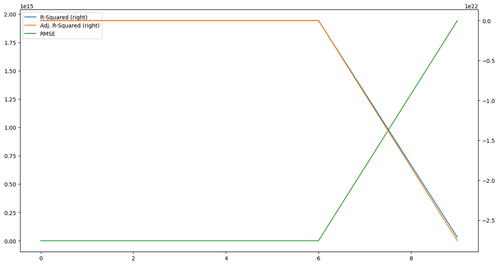

```python
# plot the accuracy measure for all models
# secondary_y: specify the data on the secondary axis
score_card.plot(secondary_y=['R-Squared','Adj. R-Squared'])

# display just the plot
plt.show()
```

[figure not shown]